# ESS voting pattern study Version 2

## Introduction

This document presents preliminary descriptive and multivariate analysis of voter turnout at the last national elections among respondents aged 50+ using data from the European Social Survey - Round 11 (2023-24). [^1]

- Section 1 presents the variables included in the analysis
- Section 2 discusses recoding related issues
- Section 3 includes unweighted and weighted frequency tables of unrecoded, recoded and derived socio-economic (SEV) and independent (IV) variables.
- Section 4 documents unweighted and weighted 2-way contingency tables of SEVs and IVs by turnout at the last national elections, as well as age and sex.
- Section 5 presents additional four way tables of voter turnout by SEVs and IVs broken down by age and sex.
- Section 6 presents the results of four series of stepwise logistic regression models of voting at the last national election.

## 1. Variables included

Table 1: Original and derived variables used in the analysis

[output not shown]

## 2. Variables recoding and operationalisation notes

The original dataset includes 45,256 observations, of which 24,129 respondents aged 50 and over.

1. Integrated household composition variable `hhdtypb` was constructed using the household grid variables `rshipa*`, and household size information.
2. No information was available on the presence of grandchilddren
3. There is no clear variable recording exclusively caring for dependents: it is either amalgamated with housework (`hwrk`) or with helping others more broadly: `hlpfmly`.
4. Whether respondents had internet connection was approximated using frequency of internet use.
5. Marital status was constructed in order to include informal partnership/cohabitation.
6. There are no variables measuring difficulties/limitations with daily life activities. A variable was constructed recording the number of health conditions instead.

## 3. Univariates results

Results are presented as follows, under each tab below:

1. Unweighted frequencies and proportions of the original variables, unrecoded
2. Weighted frequencies and proportions of the recoded (ie missing/invalid values removed) variables

**Whether voter at the last GE**

#### **Unweighted frequency table of unrecoded *vote.f***

| Category | Frequency | Percent |
| --- | --- | --- |
| [1] Yes | 19600 | 81.2 |
| [2] No | 3919 | 16.2 |
| [3] Not eligible to vote | 423 | 1.8 |
| [NA] Refusal | 91 | 0.4 |
| [NA] Don’t know | 94 | 0.4 |
| [NA] No answer | 2 | 0.0 |
| Total | 24129 | 100.0 |

#### **Weighted frequency table of recoded *vote.fr***

| vote.fr | Frequency | Percent |
| --- | --- | --- |
| Did not vote | 4047.541 | 19.8 |
| Voted | 16374.307 | 80.2 |

**Subjective financial situation**

#### **Unweighted frequency table of unrecoded *hincfel.f***

| Category | Frequency | Percent |
| --- | --- | --- |
| [1] Living comfortably on present income | 7558 | 31.3 |
| [2] Coping on present income | 10705 | 44.4 |
| [3] Difficult on present income | 4199 | 17.4 |
| [4] Very difficult on present income | 1436 | 6.0 |
| [NA] Don’t know | 45 | 0.2 |
| [NA] Refusal | 179 | 0.7 |
| [NA] No answer | 7 | 0.0 |
| Total | 24129 | 100.0 |

#### **Weighted frequency table of recoded *hincfel.fr***

| hincfel.fr | Frequency | Percent |
| --- | --- | --- |
| Living comfortably on present income | 7431.1963 | 36.4 |
| Coping on present income | 9618.5066 | 47.1 |
| Difficult on present income | 2721.3501 | 13.3 |
| Very difficult on present income | 647.5568 | 3.2 |

**Loneliness**

#### **Unweighted frequency table of unrecoded *fltlnl.f***

| Category | Frequency | Percent |
| --- | --- | --- |
| [1] None or almost none of the time | 15570 | 64.5 |
| [2] Some of the time | 5936 | 24.6 |
| [3] Most of the time | 1696 | 7.0 |
| [4] All or almost all of the time | 807 | 3.3 |
| [NA] Don’t know | 60 | 0.2 |
| [NA] Refusal | 58 | 0.2 |
| [NA] No answer | 2 | 0.0 |
| Total | 24129 | 99.8 |

#### **Weighted frequency table of recoded *fltlnl.fr***

| fltlnl.fr | Frequency | Percent |
| --- | --- | --- |
| Most/all of the time | 1728.115 | 8.4 |
| None/almost none of the time | 14358.139 | 70.0 |
| Some of the time | 4437.438 | 21.6 |

**Sex**

#### **Unweighted frequency table of unrecoded *gndr.f***

| Category | Frequency | Percent |
| --- | --- | --- |
| [1] Male | 11120 | 46.1 |
| [2] Female | 13009 | 53.9 |
| Total | 24129 | 100.0 |

#### **Weighted frequency table of recoded *gndr.fr***

| gndr.fr | Frequency | Percent |
| --- | --- | --- |
| [1] Male | 9723.244 | 47.1 |
| [2] Female | 10898.975 | 52.9 |

**Happiness**

#### **Unweighted frequency table of unrecoded *happy.f***

| Category | Frequency | Percent |
| --- | --- | --- |
| Extremely unhappy | 150 | 0.6 |
| 1 | 105 | 0.4 |
| 2 | 300 | 1.2 |
| 3 | 590 | 2.4 |
| 4 | 809 | 3.4 |
| 5 | 2609 | 10.8 |
| 6 | 2294 | 9.5 |
| 7 | 4527 | 18.8 |
| 8 | 6485 | 26.9 |
| 9 | 3672 | 15.2 |
| Extremely happy | 2491 | 10.3 |
| Don’t know | 54 | 0.2 |
| Refusal | 37 | 0.2 |
| No answer | 6 | 0.0 |
| Total | 24129 | 99.9 |

#### **Weighted frequency table of recoded *happy.fr***

| happy.fr | Frequency | Percent |
| --- | --- | --- |
| 1st quartile - least happy | 3216.864 | 15.7 |
| 2nd qtile | 5879.069 | 28.6 |
| 3rd qtile | 5775.541 | 28.1 |
| 4th qtile | 5676.645 | 27.6 |

**Social life intensity**

#### **Unweighted frequency table of unrecoded *sclmeet.f***

| Category | Frequency | Percent |
| --- | --- | --- |
| [1] Never | 654 | 2.7 |
| [2] Less than once a month | 2945 | 12.2 |
| [3] Once a month | 2550 | 10.6 |
| [4] Several times a month | 5221 | 21.6 |
| [5] Once a week | 4116 | 17.1 |
| [6] Several times a week | 5849 | 24.2 |
| [7] Every day | 2743 | 11.4 |
| [NA] Refusal | 24 | 0.1 |
| [NA] Don’t know | 25 | 0.1 |
| [NA] No answer | 2 | 0.0 |
| Total | 24129 | 100.0 |

#### **Weighted frequency table of recoded *sclmeet.fr***

| sclmeet.fr | Frequency | Percent |
| --- | --- | --- |
| Daily or less | 7617.620 | 37.0 |
| Monthly or less | 4718.833 | 22.9 |
| Weekly or less | 8233.119 | 40.0 |

**Religious attendence**

#### **Unweighted frequency table of unrecoded *rlgatnd.f***

| Category | Frequency | Percent |
| --- | --- | --- |
| [1] Every day | 244 | 1.0 |
| [2] More than once a week | 906 | 3.8 |
| [3] Once a week | 3218 | 13.3 |
| [4] At least once a month | 2885 | 12.0 |
| [5] Only on special holy days | 5244 | 21.7 |
| [6] Less often | 4577 | 19.0 |
| [7] Never | 6929 | 28.7 |
| [NA] Refusal | 72 | 0.3 |
| [NA] Don’t know | 53 | 0.2 |
| [NA] No answer | 1 | 0.0 |
| Total | 24129 | 100.0 |

#### **Weighted frequency table of recoded *rlgatnd.fr***

| rlgatnd.fr | Frequency | Percent |
| --- | --- | --- |
| Less than weekly | 5531.952 | 27.0 |
| Once a week or more | 3682.659 | 18.0 |
| Rarely or never | 11286.357 | 55.1 |

**Trade union or similar membership**

#### **Unweighted frequency table of unrecoded *mbtru.f***

| Category | Frequency | Percent |
| --- | --- | --- |
| [1] Yes, currently | 3115 | 12.9 |
| [2] Yes, previously | 7138 | 29.6 |
| [3] No | 13756 | 57.0 |
| [NA] Refusal | 76 | 0.3 |
| [NA] Don’t know | 38 | 0.2 |
| [NA] No answer | 6 | 0.0 |
| Total | 24129 | 100.0 |

#### **Weighted frequency table of recoded *mbtru.fr***

| mbtru.fr | Frequency | Percent |
| --- | --- | --- |
| Yes, currently | 2110.847 | 10.3 |
| Yes, previously | 5069.638 | 24.7 |
| No | 13338.838 | 65.0 |

**Whether doing house- or care work**

#### **Unweighted frequency table of unrecoded *hswrk.f***

| Category | Frequency | Percent |
| --- | --- | --- |
| [0] Not marked | 21409 | 88.7 |
| [1] Marked | 2720 | 11.3 |
| Total | 24129 | 100.0 |

#### **Weighted frequency table of recoded *hswrk.fr***

| hswrk.fr | Frequency | Percent |
| --- | --- | --- |
| Did housework/cared for someone | 2524.144 | 12.2 |
| Did not report | 18098.074 | 87.8 |

**Type of organisation working/worked for**

#### **Unweighted frequency table of unrecoded *tporgwk.f***

| Category | Frequency | Percent |
| --- | --- | --- |
| [1] Central or local government | 2355 | 9.8 |
| [2] Other public sector (such as education and health) | 3074 | 12.7 |
| [3] A state owned enterprise | 2520 | 10.4 |
| [4] A private firm | 11455 | 47.5 |
| [5] Self employed | 2297 | 9.5 |
| [6] Other | 482 | 2.0 |
| [NA] Not applicable | 1799 | 7.5 |
| [NA] Refusal | 63 | 0.3 |
| [NA] Don’t know | 59 | 0.2 |
| [NA] No answer | 25 | 0.1 |
| Total | 24129 | 100.0 |

#### **Weighted frequency table of recoded *tporgwk.fr***

| tporgwk.fr | Frequency | Percent |
| --- | --- | --- |
| Government (inc. local) | 1902.9773 | 10.0 |
| Other public | 2416.0868 | 12.7 |
| Other/DNA | 549.3614 | 2.9 |
| Private sector | 10736.9596 | 56.6 |
| Self-employed | 1944.9368 | 10.2 |
| State-owned | 1428.1969 | 7.5 |

**Whether volunteered**

#### **Unweighted frequency table of unrecoded *volunfp.f***

| Category | Frequency | Percent |
| --- | --- | --- |
| [1] Yes | 4373 | 18.1 |
| [2] No | 19696 | 81.6 |
| [NA] Don’t know | 27 | 0.1 |
| [NA] Refusal | 31 | 0.1 |
| [NA] No answer | 2 | 0.0 |
| Total | 24129 | 99.9 |

#### **Weighted frequency table of recoded *volunfp.fr***

| volunfp.fr | Frequency | Percent |
| --- | --- | --- |
| Yes | 4232.651 | 20.6 |
| No | 16362.290 | 79.4 |

**Interest for politics**

#### **Unweighted frequency table of unrecoded *polintr.f***

| Category | Frequency | Percent |
| --- | --- | --- |
| [1] Very interested | 3378 | 14.0 |
| [2] Quite interested | 8571 | 35.5 |
| [3] Hardly interested | 7710 | 32.0 |
| [4] Not at all interested | 4434 | 18.4 |
| [NA] Don’t know | 15 | 0.1 |
| [NA] Refusal | 18 | 0.1 |
| [NA] No answer | 3 | 0.0 |
| Total | 24129 | 100.1 |

#### **Weighted frequency table of recoded *polintr.fr***

| polintr.fr | Frequency | Percent |
| --- | --- | --- |
| Interested in politics | 10472.26 | 50.9 |
| Not interested in politics | 10118.52 | 49.1 |

**Internet usage**

#### **Unweighted frequency table of unrecoded *netusoft.f***

| Category | Frequency | Percent |
| --- | --- | --- |
| [1] Never | 5416 | 22.4 |
| [2] Only occasionally | 1789 | 7.4 |
| [3] A few times a week | 1519 | 6.3 |
| [4] Most days | 2278 | 9.4 |
| [5] Every day | 13110 | 54.3 |
| [NA] Don’t know | 8 | 0.0 |
| [NA] Refusal | 4 | 0.0 |
| [NA] No answer | 5 | 0.0 |
| Total | 24129 | 99.8 |

#### **Weighted frequency table of recoded *netusoft.fr***

| netusoft.fr | Frequency | Percent |
| --- | --- | --- |
| Most days/ every day | 13457.486 | 65.3 |
| Never | 4265.026 | 20.7 |
| Occasionally/ a few times a week | 2894.172 | 14.0 |

**Marital/relationship status**

#### **Unweighted frequency table of unrecoded *maritalb.f***

| Category | Frequency | Percent |
| --- | --- | --- |
| [1] Legally married | 14083 | 58.4 |
| [2] In a legally registered civil union | 175 | 0.7 |
| [3] Legally separated | 186 | 0.8 |
| [4] Legally divorced/Civil union dissolved | 2944 | 12.2 |
| [5] Widowed/Civil partner died | 3987 | 16.5 |
| [6] None of these (NEVER married or in legally registered civil union) | 2297 | 9.5 |
| [NA] Don’t know | 20 | 0.1 |
| [NA] Refusal | 103 | 0.4 |
| [NA] No answer | 334 | 1.4 |
| Total | 24129 | 100.0 |

#### **Weighted frequency table of recoded *maritalb.fr***

| maritalb.fr | Frequency | Percent |
| --- | --- | --- |
| Divorced/separated | 1973.617 | 9.6 |
| Married/SP | 13834.873 | 67.5 |
| Single | 1939.683 | 9.5 |
| Widowed | 2757.190 | 13.4 |

**Educational level**

#### **Unweighted frequency table of unrecoded *eisced.f***

| Category | Frequency | Percent |
| --- | --- | --- |
| [1] ES-ISCED I , less than lower secondary | 2545 | 10.5 |
| [2] ES-ISCED II, lower secondary | 4147 | 17.2 |
| [3] ES-ISCED IIIb, lower tier upper secondary | 4270 | 17.7 |
| [4] ES-ISCED IIIa, upper tier upper secondary | 5227 | 21.7 |
| [5] ES-ISCED IV, advanced vocational, sub-degree | 2801 | 11.6 |
| [6] ES-ISCED V1, lower tertiary education, BA level | 2193 | 9.1 |
| [7] ES-ISCED V2, higher tertiary education, >= MA level | 2811 | 11.6 |
| [55] Other | 74 | 0.3 |
| [NA] Don’t know | 20 | 0.1 |
| [NA] Refusal | 25 | 0.1 |
| [NA] No answer | 16 | 0.1 |
| Total | 24129 | 100.0 |

#### **Weighted frequency table of recoded *eisced.fr***

| eisced.fr | Frequency | Percent |
| --- | --- | --- |
| Below secondary | 2973.1118 | 14.5 |
| Further/Degree level | 5916.2152 | 28.8 |
| Other | 85.8428 | 0.4 |
| Secondary | 11548.2970 | 56.3 |

**Self-reported general health V1**

#### **Unweighted frequency table of unrecoded *health.f***

| Category | Frequency | Percent |
| --- | --- | --- |
| [1] Very good | 3251 | 13.5 |
| [2] Good | 9820 | 40.7 |
| [3] Fair | 8286 | 34.3 |
| [4] Bad | 2293 | 9.5 |
| [5] Very bad | 447 | 1.9 |
| [NA] Refusal | 17 | 0.1 |
| [NA] Don’t know | 14 | 0.1 |
| [NA] No answer | 1 | 0.0 |
| Total | 24129 | 100.1 |

#### **Weighted frequency table of recoded *health.fr***

| health.fr | Frequency | Percent |
| --- | --- | --- |
| Fair | 7104.867 | 34.5 |
| Poor | 2515.765 | 12.2 |
| Very good/good | 10969.897 | 53.3 |

**High blood pressure**

#### **Unweighted frequency table of unrecoded *hltphhb.f***

| Category | Frequency | Percent |
| --- | --- | --- |
| [0] Not marked | 21939 | 90.9 |
| [1] Marked | 2190 | 9.1 |
| Total | 24129 | 100.0 |

#### **Weighted frequency table of recoded *hltphhb.fr***

| hltphhb.fr | Frequency | Percent |
| --- | --- | --- |
| [0] Not marked | 19243.215 | 93.3 |
| [1] Marked | 1379.003 | 6.7 |

**Allergies**

#### **Unweighted frequency table of unrecoded *hltphal.f***

| Category | Frequency | Percent |
| --- | --- | --- |
| [0] Not marked | 23565 | 97.7 |
| [1] Marked | 564 | 2.3 |
| Total | 24129 | 100.0 |

#### **Weighted frequency table of recoded *hltphal.fr***

| hltphal.fr | Frequency | Percent |
| --- | --- | --- |
| [0] Not marked | 20125.6038 | 97.6 |
| [1] Marked | 496.6144 | 2.4 |

**Back or neck pain**

#### **Unweighted frequency table of unrecoded *hltphbn.f***

| Category | Frequency | Percent |
| --- | --- | --- |
| [0] Not marked | 19630 | 81.4 |
| [1] Marked | 4499 | 18.6 |
| Total | 24129 | 100.0 |

#### **Weighted frequency table of recoded *hltphbn.fr***

| hltphbn.fr | Frequency | Percent |
| --- | --- | --- |
| [0] Not marked | 16935.881 | 82.1 |
| [1] Marked | 3686.337 | 17.9 |

**Muscular or joint pain in hand or arm**

#### **Unweighted frequency table of unrecoded *hltphpa.f***

| Category | Frequency | Percent |
| --- | --- | --- |
| [0] Not marked | 20995 | 87 |
| [1] Marked | 3134 | 13 |
| Total | 24129 | 100 |

#### **Weighted frequency table of recoded *hltphpa.fr***

| hltphpa.fr | Frequency | Percent |
| --- | --- | --- |
| [0] Not marked | 17801.941 | 86.3 |
| [1] Marked | 2820.277 | 13.7 |

**Muscular or joint pain in foot or leg**

#### **Unweighted frequency table of unrecoded *hltphpf.f***

| Category | Frequency | Percent |
| --- | --- | --- |
| [0] Not marked | 20048 | 83.1 |
| [1] Marked | 4081 | 16.9 |
| Total | 24129 | 100.0 |

#### **Weighted frequency table of recoded *hltphpf.fr***

| hltphpf.fr | Frequency | Percent |
| --- | --- | --- |
| [0] Not marked | 17003.124 | 82.5 |
| [1] Marked | 3619.094 | 17.5 |

**Stomach or digestion related**

#### **Unweighted frequency table of unrecoded *hltphsd.f***

| Category | Frequency | Percent |
| --- | --- | --- |
| [0] Not marked | 22950 | 95.1 |
| [1] Marked | 1179 | 4.9 |
| Total | 24129 | 100.0 |

#### **Weighted frequency table of recoded *hltphsd.fr***

| hltphsd.fr | Frequency | Percent |
| --- | --- | --- |
| [0] Not marked | 19526.976 | 94.7 |
| [1] Marked | 1095.242 | 5.3 |

**Skin condition related**

#### **Unweighted frequency table of unrecoded *hltphsc.f***

| Category | Frequency | Percent |
| --- | --- | --- |
| [0] Not marked | 23785 | 98.6 |
| [1] Marked | 344 | 1.4 |
| Total | 24129 | 100.0 |

#### **Weighted frequency table of recoded *hltphsc.fr***

| hltphsc.fr | Frequency | Percent |
| --- | --- | --- |
| [0] Not marked | 20296.5175 | 98.4 |
| [1] Marked | 325.7007 | 1.6 |

**Severe headaches**

#### **Unweighted frequency table of unrecoded *hltphsh.f***

| Category | Frequency | Percent |
| --- | --- | --- |
| [0] Not marked | 23144 | 95.9 |
| [1] Marked | 985 | 4.1 |
| Total | 24129 | 100.0 |

#### **Weighted frequency table of recoded *hltphsh.fr***

| hltphsh.fr | Frequency | Percent |
| --- | --- | --- |
| [0] Not marked | 19732.3729 | 95.7 |
| [1] Marked | 889.8452 | 4.3 |

**Diabetes**

#### **Unweighted frequency table of unrecoded *hltphdi.f***

| Category | Frequency | Percent |
| --- | --- | --- |
| [0] Not marked | 23276 | 96.5 |
| [1] Marked | 853 | 3.5 |
| Total | 24129 | 100.0 |

#### **Weighted frequency table of recoded *hltphdi.fr***

| hltphdi.fr | Frequency | Percent |
| --- | --- | --- |
| [0] Not marked | 19938.8220 | 96.7 |
| [1] Marked | 683.3962 | 3.3 |

**Economic activity**

#### **Unweighted frequency table of unrecoded *mnactic.f***

| Category | Frequency | Percent |
| --- | --- | --- |
| [1] Paid work | 8468 | 35.1 |
| [2] Education | 33 | 0.1 |
| [3] Unemployed, looking for job | 358 | 1.5 |
| [4] Unemployed, not looking for job | 382 | 1.6 |
| [5] Permanently sick or disabled | 708 | 2.9 |
| [6] Retired | 12283 | 50.9 |
| [7] Community or military service | 8 | 0.0 |
| [8] Housework, looking after children, others | 1558 | 6.5 |
| [9] Other | 252 | 1.0 |
| [NA] Refusal | 18 | 0.1 |
| [NA] Don’t know | 22 | 0.1 |
| [NA] No answer | 39 | 0.2 |
| Total | 24129 | 100.0 |

#### **Weighted frequency table of recoded *mnactic.fr***

| mnactic.fr | Frequency | Percent |
| --- | --- | --- |
| Ec. inactive | 841.9802 | 4.1 |
| FT carer | 1539.2846 | 7.5 |
| In employment | 7269.2214 | 35.4 |
| LT sick/disabled | 662.0021 | 3.2 |
| Retired (inc part) | 10235.6518 | 49.8 |

**Country**

#### **Unweighted frequency table of unrecoded *cntry.f***

| Category | Frequency | Percent |
| --- | --- | --- |
| AT | 1460 | 6.1 |
| BE | 803 | 3.3 |
| BG | 1241 | 5.1 |
| CH | 662 | 2.7 |
| CY | 400 | 1.7 |
| DE | 1265 | 5.2 |
| ES | 910 | 3.8 |
| FI | 872 | 3.6 |
| FR | 917 | 3.8 |
| GB | 897 | 3.7 |
| GR | 1425 | 5.9 |
| HR | 837 | 3.5 |
| HU | 1036 | 4.3 |
| IE | 1132 | 4.7 |
| IS | 422 | 1.7 |
| IT | 1546 | 6.4 |
| LT | 691 | 2.9 |
| LV | 785 | 3.3 |
| ME | 769 | 3.2 |
| NL | 886 | 3.7 |
| NO | 620 | 2.6 |
| PL | 665 | 2.8 |
| PT | 786 | 3.3 |
| RS | 851 | 3.5 |
| SE | 724 | 3.0 |
| SI | 637 | 2.6 |
| SK | 890 | 3.7 |
| Total | 24129 | 100.1 |

#### **Weighted frequency table of recoded *cntry.fr***

| cntry.fr | Frequency | Percent |
| --- | --- | --- |
| AT | 365.729011 | 1.8 |
| BE | 450.170060 | 2.2 |
| BG | 271.045010 | 1.3 |
| CH | 336.343037 | 1.6 |
| CY | 39.642416 | 0.2 |
| DE | 3551.949516 | 17.2 |
| ES | 1926.281579 | 9.3 |
| FI | 230.931872 | 1.1 |
| FR | 2683.935889 | 13.0 |
| GB | 2418.219628 | 11.7 |
| GR | 454.474139 | 2.2 |
| HR | 186.163414 | 0.9 |
| HU | 368.071134 | 1.8 |
| IE | 163.498808 | 0.8 |
| IS | 7.440256 | 0.0 |
| IT | 2971.946802 | 14.4 |
| LT | 116.102745 | 0.6 |
| LV | 76.485507 | 0.4 |
| ME | 16.989650 | 0.1 |
| NL | 704.302971 | 3.4 |
| NO | 195.248610 | 0.9 |
| PL | 1668.464276 | 8.1 |
| PT | 452.591342 | 2.2 |
| RS | 281.504756 | 1.4 |
| SE | 404.727517 | 2.0 |
| SI | 89.257884 | 0.4 |
| SK | 190.700334 | 0.9 |

#### **Unweighted frequency table of unrecoded *AgeCat2.f***

| Category | Frequency | Percent |
| --- | --- | --- |
| 50-69 | 15079 | 62.5 |
| 70+ | 9050 | 37.5 |
| Total | 24129 | 100.0 |

#### **Weighted frequency table of recoded *AgeCat2.fr***

| AgeCat2.fr | Frequency | Percent |
| --- | --- | --- |
| 50-69 | 12996.100 | 63 |
| 70+ | 7626.118 | 37 |

#### **Unweighted frequency table of unrecoded *AgeCat3.f***

| Category | Frequency | Percent |
| --- | --- | --- |
| 50-69 | 15079 | 62.5 |
| 70-79 | 6209 | 25.7 |
| 80+ | 2841 | 11.8 |
| Total | 24129 | 100.0 |

#### **Weighted frequency table of recoded *AgeCat3.fr***

| AgeCat3.fr | Frequency | Percent |
| --- | --- | --- |
| 50-69 | 12996.100 | 63.0 |
| 70-79 | 5072.190 | 24.6 |
| 80+ | 2553.929 | 12.4 |

**Self-reported general health V2**

#### **Unweighted frequency table of unrecoded *health2.f***

| Category | Frequency | Percent |
| --- | --- | --- |
| [1] Very good | 3251 | 13.5 |
| [2] Good | 9820 | 40.7 |
| [3] Fair | 8286 | 34.3 |
| [4] Bad | 2293 | 9.5 |
| [5] Very bad | 447 | 1.9 |
| [NA] Refusal | 17 | 0.1 |
| [NA] Don’t know | 14 | 0.1 |
| [NA] No answer | 1 | 0.0 |
| Total | 24129 | 100.1 |

#### **Weighted frequency table of recoded *health2.fr***

| health2.fr | Frequency | Percent |
| --- | --- | --- |
| Bad or very bad | 2515.765 | 12.2 |
| Not bad | 18074.764 | 87.8 |

**Number of reported health problems**

#### **Unweighted frequency table of unrecoded *nrhltpb.f***

| Category | Frequency | Percent |
| --- | --- | --- |
| 0 | 12606 | 52.2 |
| 1 | 6507 | 27.0 |
| 2 | 2634 | 10.9 |
| 3 | 1287 | 5.3 |
| 4 | 549 | 2.3 |
| 5 | 274 | 1.1 |
| 6 | 137 | 0.6 |
| 7 | 69 | 0.3 |
| 8 | 37 | 0.2 |
| 9 | 19 | 0.1 |
| 10 | 3 | 0.0 |
| 11 | 7 | 0.0 |
| Total | 24129 | 100.0 |

#### **Weighted frequency table of recoded *nrhltpb.fr***

| nrhltpb.fr | Frequency | Percent |
| --- | --- | --- |
| 3-4 | 1399.1872 | 6.8 |
| 5+ | 437.0552 | 2.1 |
| None | 10966.0962 | 53.2 |
| One | 5541.1564 | 26.9 |
| Two | 2278.7232 | 11.0 |

**Recoded household type**

#### **Unweighted frequency table of unrecoded *hhdtypb.f***

| Category | Frequency | Percent |
| --- | --- | --- |
| Nuclear family | 3553 | 14.7 |
| Other | 1843 | 7.6 |
| Single parent | 1011 | 4.2 |
| Single person HH | 7224 | 29.9 |
| Two persons (couple) HH | 10498 | 43.5 |
| Total | 24129 | 99.9 |

#### **Weighted frequency table of recoded *hhdtypb.fr***

| hhdtypb.fr | Frequency | Percent |
| --- | --- | --- |
| Nuclear family | 3462.9043 | 16.8 |
| Other | 1648.5286 | 8.0 |
| Single parent | 858.2725 | 4.2 |
| Single person HH | 5128.3098 | 24.9 |
| Two persons (couple) HH | 9524.2029 | 46.2 |

**Occupation, ISCO08 1 digit**

#### **Unweighted frequency table of unrecoded *isco1.f***

| Category | Frequency | Percent |
| --- | --- | --- |
| 0-Armed Forces | 89 | 0.4 |
| 1-Managers | 1865 | 7.7 |
| 2-Professionals | 3950 | 16.4 |
| 3-Technicians and Associate Professionals | 2735 | 11.3 |
| 4-Clerical Support Workers | 1963 | 8.1 |
| 5-Service and sales | 3591 | 14.9 |
| 6-Skilled Agricultural, Forestry and Fishery Workers | 786 | 3.3 |
| 7-Craft and Related Trades Workers | 2751 | 11.4 |
| 8-Plant and Machine Operators, and Assemblers | 1739 | 7.2 |
| 9-Elementary Occupations | 2385 | 9.9 |
| NA | 2275 | 9.4 |
| Total | 24129 | 100.0 |

#### **Weighted frequency table of recoded *isco1.fr***

| isco1.fr | Frequency | Percent |
| --- | --- | --- |
| 1-Managers | 1707.359 | 9.1 |
| 2-Professionals | 3055.688 | 16.3 |
| 3-Technicians and Associate Professionals | 2757.312 | 14.7 |
| 4+5-Clerical Support, Service and sales | 4676.194 | 25.0 |
| 6+7-Skilled Agric., forest., fishery, craft and related | 2868.708 | 15.3 |
| Elementary Occupations | 2044.544 | 10.9 |
| Plant and Machine Operators, and Assemblers | 1584.016 | 8.5 |

## 4. Bivariates results

This section contains for each variable used in the study, the following contingency tables:

1. With voter turnout at the last national elections
2. With sex
3. With age, two and three categories

All contingency tables were computed with weighted data and include $\chi^2$ test of independence.

### **4.1. Voter turnout at the last national elections**

**Subjective financial situation**

##### *Whether voted at the last NE by Subjective financial situation(hincfel)*

|  | Living comfortably on present income |  | Coping on present income |  | Difficult on present income |  | Very difficult on present income |  |
| --- | --- | --- | --- | --- | --- | --- | --- | --- |
|  | Freq | % | Freq | % | Freq | % | Freq | % |
| Did not vote | 967.9 | 13.1 | 1933.8 | 20.33 | 814.2 | 30.34 | 264.6 | 41.22 |
| Voted | 6420.3 | 86.9 | 7580.5 | 79.67 | 1869.8 | 69.66 | 377.5 | 58.78 |
| Total | 7388.2 | 100 | 9514.3 | 100 | 2684 | 100 | 642.1 | 100 |

[1] “Pearson’s X^2: Rao & Scott adjustment”

```
    F       ndf X-squared
```

67.891 2.889 0.000

**Loneliness**

##### *Whether voted at the last NE by Loneliness(fltlnl)*

|  | Most/all of the time |  | None/almost none of the time |  | Some of the time |  |
| --- | --- | --- | --- | --- | --- | --- |
|  | Freq | % | Freq | % | Freq | % |
| Did not vote | 589.5 | 34.54 | 2214.4 | 15.54 | 1222.9 | 27.97 |
| Voted | 1117.4 | 65.46 | 12035.2 | 84.46 | 3149.7 | 72.03 |
| Total | 1706.9 | 100 | 14249.6 | 100 | 4372.6 | 100 |

[1] “Pearson’s X^2: Rao & Scott adjustment”

```
    F       ndf X-squared
```

107.146 1.998 0.000

**Sex**

##### *Whether voted at the last NE by Sex(gndr)*

|  | [1] Male |  | [2] Female |  |
| --- | --- | --- | --- | --- |
|  | Freq | % | Freq | % |
| Did not vote | 1654.8 | 17.17 | 2392.7 | 22.19 |
| Voted | 7984.3 | 82.83 | 8390 | 77.81 |
| Total | 9639.1 | 100 | 10782.7 | 100 |

[1] “Pearson’s X^2: Rao & Scott adjustment”

```
    F       ndf X-squared
```

26.538 1.000 0.000

**Happiness**

##### *Whether voted at the last NE by Happiness(happy)*

|  | 1st quartile - least happy |  | 2nd qtile |  | 3rd qtile |  | 4th qtile |  |
| --- | --- | --- | --- | --- | --- | --- | --- | --- |
|  | Freq | % | Freq | % | Freq | % | Freq | % |
| Did not vote | 1143.7 | 35.98 | 1231.2 | 21.21 | 841 | 14.69 | 808.6 | 14.32 |
| Voted | 2035.4 | 64.02 | 4573.5 | 78.79 | 4882.8 | 85.31 | 4836.8 | 85.68 |
| Total | 3179.1 | 100 | 5804.7 | 100 | 5723.8 | 100 | 5645.4 | 100 |

[1] “Pearson’s X^2: Rao & Scott adjustment”

```
    F       ndf X-squared
```

88.303 2.964 0.000

**Social life intensity**

##### *Whether voted at the last NE by Social life intensity(sclmeet)*

|  | Daily or less |  | Monthly or less |  | Weekly or less |  |
| --- | --- | --- | --- | --- | --- | --- |
|  | Freq | % | Freq | % | Freq | % |
| Did not vote | 1337.7 | 17.72 | 1227.4 | 26.21 | 1467.8 | 18.03 |
| Voted | 6210.3 | 82.28 | 3454.9 | 73.79 | 6672.8 | 81.97 |
| Total | 7548 | 100 | 4682.3 | 100 | 8140.6 | 100 |

[1] “Pearson’s X^2: Rao & Scott adjustment”

```
    F       ndf X-squared
```

25.821 1.996 0.000

**Religious attendence**

##### *Whether voted at the last NE by Religious attendence(rlgatnd)*

|  | Less than weekly |  | Once a week or more |  | Rarely or never |  |
| --- | --- | --- | --- | --- | --- | --- |
|  | Freq | % | Freq | % | Freq | % |
| Did not vote | 961.9 | 17.54 | 763.9 | 20.94 | 2301.4 | 20.58 |
| Voted | 4522.2 | 82.46 | 2884.1 | 79.06 | 8882.1 | 79.42 |
| Total | 5484.1 | 100 | 3648 | 100 | 11183.5 | 100 |

[1] “Pearson’s X^2: Rao & Scott adjustment”

```
    F       ndf X-squared
4.152     1.943     0.017
```

**Trade union or similar membership**

##### *Whether voted at the last NE by Trade union or similar membership(mbtru)*

|  | Yes, currently |  | Yes, previously |  | No |  |
| --- | --- | --- | --- | --- | --- | --- |
|  | Freq | % | Freq | % | Freq | % |
| Did not vote | 188.8 | 8.99 | 717.8 | 14.24 | 3126.6 | 23.71 |
| Voted | 1911.5 | 91.01 | 4324.4 | 85.76 | 10060.1 | 76.29 |
| Total | 2100.3 | 100 | 5042.2 | 100 | 13186.7 | 100 |

[1] “Pearson’s X^2: Rao & Scott adjustment”

```
    F       ndf X-squared
```

58.422 1.953 0.000

**Whether doing house- or care work**

##### *Whether voted at the last NE by Whether doing house- or care work(hswrk)*

|  | Did housework/cared for someone |  | Did not report |  |
| --- | --- | --- | --- | --- |
|  | Freq | % | Freq | % |
| Did not vote | 497.2 | 19.81 | 3550.4 | 19.82 |
| Voted | 2012.3 | 80.19 | 14362 | 80.18 |
| Total | 2509.5 | 100 | 17912.4 | 100 |

[1] “Pearson’s X^2: Rao & Scott adjustment”

```
    F       ndf X-squared
0.000     1.000     0.995
```

**Type of organisation working/worked for**

##### *Whether voted at the last NE by Type of organisation working/worked for(tporgwk)*

|  | Government (inc. local) |  | Other public |  | Other/DNA |  | Private sector |  | Self-employed |  | State-owned |  |
| --- | --- | --- | --- | --- | --- | --- | --- | --- | --- | --- | --- | --- |
|  | Freq | % | Freq | % | Freq | % | Freq | % | Freq | % | Freq | % |
| Did not vote | 239.7 | 12.68 | 306.8 | 12.85 | 119.5 | 22.04 | 2235.1 | 20.99 | 358.7 | 18.56 | 243 | 17.16 |
| Voted | 1650.8 | 87.32 | 2080.3 | 87.15 | 422.6 | 77.96 | 8411.9 | 79.01 | 1574.3 | 81.44 | 1173.1 | 82.84 |
| Total | 1890.5 | 100 | 2387.1 | 100 | 542.1 | 100 | 10647 | 100 | 1933 | 100 | 1416.1 | 100 |

[1] “Pearson’s X^2: Rao & Scott adjustment”

```
    F       ndf X-squared
```

10.895 4.913 0.000

**Whether volunteered**

##### *Whether voted at the last NE by Whether volunteered(volunfp)*

|  | Yes |  | No |  |
| --- | --- | --- | --- | --- |
|  | Freq | % | Freq | % |
| Did not vote | 444.1 | 10.53 | 3601.2 | 22.26 |
| Voted | 3772.8 | 89.47 | 12579.1 | 77.74 |
| Total | 4216.9 | 100 | 16180.3 | 100 |

[1] “Pearson’s X^2: Rao & Scott adjustment”

```
    F       ndf X-squared
```

105.406 1.000 0.000

**Interest for politics**

##### *Whether voted at the last NE by Interest for politics(polintr)*

|  | Interested in politics |  | Not interested in politics |  |
| --- | --- | --- | --- | --- |
|  | Freq | % | Freq | % |
| Did not vote | 909.3 | 8.72 | 3130 | 31.41 |
| Voted | 9515.5 | 91.28 | 6836.2 | 68.59 |
| Total | 10424.8 | 100 | 9966.2 | 100 |

[1] “Pearson’s X^2: Rao & Scott adjustment”

```
    F       ndf X-squared
```

627.623 1.000 0.000

**Internet usage**

##### *Whether voted at the last NE by Internet usage(netusoft)*

|  | Most days/ every day |  | Never |  | Occasionally/ a few times a week |  |
| --- | --- | --- | --- | --- | --- | --- |
|  | Freq | % | Freq | % | Freq | % |
| Did not vote | 2057.9 | 15.41 | 1241.6 | 29.45 | 747.4 | 26.24 |
| Voted | 11293.1 | 84.59 | 2974.9 | 70.55 | 2101.5 | 73.76 |
| Total | 13351 | 100 | 4216.5 | 100 | 2848.9 | 100 |

[1] “Pearson’s X^2: Rao & Scott adjustment”

```
    F       ndf X-squared
```

79.569 1.987 0.000

**Marital/relationship status**

##### *Whether voted at the last NE by Marital/relationship status(maritalb)*

|  | Divorced/separated |  | Married/SP |  | Single |  | Widowed |  |
| --- | --- | --- | --- | --- | --- | --- | --- | --- |
|  | Freq | % | Freq | % | Freq | % | Freq | % |
| Did not vote | 587 | 29.94 | 2124.3 | 15.5 | 508.6 | 26.56 | 790.4 | 28.93 |
| Voted | 1373.3 | 70.06 | 11579.5 | 84.5 | 1406 | 73.44 | 1941.5 | 71.07 |
| Total | 1960.3 | 100 | 13703.8 | 100 | 1914.6 | 100 | 2731.9 | 100 |

[1] “Pearson’s X^2: Rao & Scott adjustment”

```
    F       ndf X-squared
```

56.801 2.988 0.000

**Educational level**

##### *Whether voted at the last NE by Educational level(eisced)*

|  | Below secondary |  | Further/Degree level |  | Other |  | Secondary |  |
| --- | --- | --- | --- | --- | --- | --- | --- | --- |
|  | Freq | % | Freq | % | Freq | % | Freq | % |
| Did not vote | 1034.6 | 35.35 | 679.3 | 11.54 | 7.9 | 9.17 | 2294.9 | 20.08 |
| Voted | 1892.4 | 64.65 | 5207 | 88.46 | 78 | 90.83 | 9131 | 79.92 |
| Total | 2927 | 100 | 5886.3 | 100 | 85.9 | 100 | 11425.9 | 100 |

[1] “Pearson’s X^2: Rao & Scott adjustment”

```
    F       ndf X-squared
```

102.238 2.829 0.000

**Self-reported general health V1**

##### *Whether voted at the last NE by Self-reported general health V1(health)*

|  | Fair |  | Poor |  | Very good/good |  |
| --- | --- | --- | --- | --- | --- | --- |
|  | Freq | % | Freq | % | Freq | % |
| Did not vote | 1501.7 | 21.39 | 796.2 | 31.94 | 1748.9 | 16.07 |
| Voted | 5518.8 | 78.61 | 1696.8 | 68.06 | 9130.9 | 83.93 |
| Total | 7020.5 | 100 | 2493 | 100 | 10879.8 | 100 |

[1] “Pearson’s X^2: Rao & Scott adjustment”

```
    F       ndf X-squared
```

56.075 1.938 0.000

**High blood pressure**

##### *Whether voted at the last NE by High blood pressure(hltphhb)*

|  | [0] Not marked |  | [1] Marked |  |
| --- | --- | --- | --- | --- |
|  | Freq | % | Freq | % |
| Did not vote | 3669.6 | 19.26 | 378 | 27.53 |
| Voted | 15379.1 | 80.74 | 995.2 | 72.47 |
| Total | 19048.7 | 100 | 1373.2 | 100 |

[1] “Pearson’s X^2: Rao & Scott adjustment”

```
    F       ndf X-squared
```

15.036 1.000 0.000

**Allergies**

##### *Whether voted at the last NE by Allergies(hltphal)*

|  | [0] Not marked |  | [1] Marked |  |
| --- | --- | --- | --- | --- |
|  | Freq | % | Freq | % |
| Did not vote | 3916.8 | 19.66 | 130.7 | 26.39 |
| Voted | 16009.5 | 80.34 | 364.8 | 73.61 |
| Total | 19926.3 | 100 | 495.5 | 100 |

[1] “Pearson’s X^2: Rao & Scott adjustment”

```
    F       ndf X-squared
4.069     1.000     0.044
```

**Back or neck pain**

##### *Whether voted at the last NE by Back or neck pain(hltphbn)*

|  | [0] Not marked |  | [1] Marked |  |
| --- | --- | --- | --- | --- |
|  | Freq | % | Freq | % |
| Did not vote | 3282.6 | 19.58 | 764.9 | 20.93 |
| Voted | 13484.4 | 80.42 | 2889.9 | 79.07 |
| Total | 16767 | 100 | 3654.8 | 100 |

[1] “Pearson’s X^2: Rao & Scott adjustment”

```
    F       ndf X-squared
1.189     1.000     0.276
```

**Muscular or joint pain in hand or arm**

##### *Whether voted at the last NE by Muscular or joint pain in hand or arm(hltphpa)*

|  | [0] Not marked |  | [1] Marked |  |
| --- | --- | --- | --- | --- |
|  | Freq | % | Freq | % |
| Did not vote | 3357.8 | 19.05 | 689.7 | 24.66 |
| Voted | 14267 | 80.95 | 2107.3 | 75.34 |
| Total | 17624.8 | 100 | 2797 | 100 |

[1] “Pearson’s X^2: Rao & Scott adjustment”

```
    F       ndf X-squared
```

15.301 1.000 0.000

**Muscular or joint pain in foot or leg**

##### *Whether voted at the last NE by Muscular or joint pain in foot or leg(hltphpf)*

|  | [0] Not marked |  | [1] Marked |  |
| --- | --- | --- | --- | --- |
|  | Freq | % | Freq | % |
| Did not vote | 3261.4 | 19.4 | 786.2 | 21.8 |
| Voted | 13553.9 | 80.6 | 2820.5 | 78.2 |
| Total | 16815.3 | 100 | 3606.7 | 100 |

[1] “Pearson’s X^2: Rao & Scott adjustment”

```
    F       ndf X-squared
3.469     1.000     0.063
```

**Stomach or digestion related**

##### *Whether voted at the last NE by Stomach or digestion related(hltphsd)*

|  | [0] Not marked |  | [1] Marked |  |
| --- | --- | --- | --- | --- |
|  | Freq | % | Freq | % |
| Did not vote | 3789.1 | 19.6 | 258.5 | 23.8 |
| Voted | 15546.6 | 80.4 | 827.7 | 76.2 |
| Total | 19335.7 | 100 | 1086.2 | 100 |

[1] “Pearson’s X^2: Rao & Scott adjustment”

```
    F       ndf X-squared
3.684     1.000     0.055
```

**Skin condition related**

##### *Whether voted at the last NE by Skin condition related(hltphsc)*

|  | [0] Not marked |  | [1] Marked |  |
| --- | --- | --- | --- | --- |
|  | Freq | % | Freq | % |
| Did not vote | 3985.1 | 19.83 | 62.4 | 19.16 |
| Voted | 16111 | 80.17 | 263.3 | 80.84 |
| Total | 20096.1 | 100 | 325.7 | 100 |

[1] “Pearson’s X^2: Rao & Scott adjustment”

```
    F       ndf X-squared
0.022     1.000     0.881
```

**Severe headaches**

##### *Whether voted at the last NE by Severe headaches(hltphsh)*

|  | [0] Not marked |  | [1] Marked |  |
| --- | --- | --- | --- | --- |
|  | Freq | % | Freq | % |
| Did not vote | 3829.6 | 19.6 | 217.9 | 24.56 |
| Voted | 15705 | 80.4 | 669.3 | 75.44 |
| Total | 19534.6 | 100 | 887.2 | 100 |

[1] “Pearson’s X^2: Rao & Scott adjustment”

```
    F       ndf X-squared
3.778     1.000     0.052
```

**Diabetes**

##### *Whether voted at the last NE by Diabetes(hltphdi)*

|  | [0] Not marked |  | [1] Marked |  |
| --- | --- | --- | --- | --- |
|  | Freq | % | Freq | % |
| Did not vote | 3861.4 | 19.56 | 186.1 | 27.33 |
| Voted | 15879.4 | 80.44 | 494.9 | 72.67 |
| Total | 19740.8 | 100 | 681 | 100 |

[1] “Pearson’s X^2: Rao & Scott adjustment”

```
    F       ndf X-squared
6.880     1.000     0.009
```

**Economic activity**

##### *Whether voted at the last NE by Economic activity(mnactic)*

|  | Ec. inactive |  | FT carer |  | In employment |  | LT sick/disabled |  | Retired (inc part) |  |
| --- | --- | --- | --- | --- | --- | --- | --- | --- | --- | --- |
|  | Freq | % | Freq | % | Freq | % | Freq | % | Freq | % |
| Did not vote | 282.1 | 34.06 | 377 | 24.71 | 1313.8 | 18.23 | 238.1 | 36.28 | 1812.4 | 17.88 |
| Voted | 546.2 | 65.94 | 1148.8 | 75.29 | 5892.9 | 81.77 | 418.2 | 63.72 | 8321.9 | 82.12 |
| Total | 828.3 | 100 | 1525.8 | 100 | 7206.7 | 100 | 656.3 | 100 | 10134.3 | 100 |

[1] “Pearson’s X^2: Rao & Scott adjustment”

```
    F       ndf X-squared
```

19.664 3.647 0.000

**Country**

##### *Whether voted at the last NE by Country(cntry)*

|  | AT |  | BE |  | BG |  | CH |  | CY |  | DE |  | ES |  | FI |  | FR |  | GB |  | GR |  | HR |  | HU |  | IE |  | IS | … |
| --- | --- | --- | --- | --- | --- | --- | --- | --- | --- | --- | --- | --- | --- | --- | --- | --- | --- | --- | --- | --- | --- | --- | --- | --- | --- | --- | --- | --- | --- | --- |
|  | Freq | % | Freq | % | Freq | % | Freq | % | Freq | % | Freq | % | Freq | % | Freq | % | Freq | % | Freq | % | Freq | % | Freq | % | Freq | % | Freq | % | Freq | … |
| Did not vote | 52.8 | 14.52 | 47.7 | 10.65 | 82.5 | 30.66 | 108 | 33.06 | 8.6 | 21.89 | 467.3 | 13.16 | 340.4 | 17.7 | 31.5 | 13.64 | 832.6 | 31.82 | 403.1 | 16.79 | 63.1 | 13.88 | 37.4 | 20.42 | 62.6 | 17.06 | 17.7 | 10.85 | 0.5 | … |
| Voted | 310.7 | 85.48 | 399.8 | 89.35 | 186.6 | 69.34 | 218.7 | 66.94 | 30.6 | 78.11 | 3083.3 | 86.84 | 1583 | 82.3 | 199.2 | 86.36 | 1783.7 | 68.18 | 1998.2 | 83.21 | 391.4 | 86.12 | 145.9 | 79.58 | 304.6 | 82.94 | 145.5 | 89.15 | 6.9 | … |
| Total | 363.5 | 100 | 447.5 | 100 | 269.1 | 100 | 326.7 | 100 | 39.2 | 100 | 3550.6 | 100 | 1923.4 | 100 | 230.7 | 100 | 2616.3 | 100 | 2401.3 | 100 | 454.5 | 100 | 183.3 | 100 | 367.2 | 100 | 163.2 | 100 | 7.4 | … |

[1] “Pearson’s X^2: Rao & Scott adjustment”

```
    F       ndf X-squared
```

36.677 8.231 0.000

**Recoded age, 2 category**

##### *Whether voted at the last NE by Recoded age, 2 category(AgeCat2)*

|  | 50-69 |  | 70+ |  |
| --- | --- | --- | --- | --- |
|  | Freq | % | Freq | % |
| Did not vote | 2583.6 | 20.06 | 1463.9 | 19.41 |
| Voted | 10294.5 | 79.94 | 6079.8 | 80.59 |
| Total | 12878.1 | 100 | 7543.7 | 100 |

[1] “Pearson’s X^2: Rao & Scott adjustment”

```
    F       ndf X-squared
0.467     1.000     0.495
```

**Recoded age, 3 category**

##### *Whether voted at the last NE by Recoded age, 3 category(AgeCat3)*

|  | 50-69 |  | 70-79 |  | 80+ |  |
| --- | --- | --- | --- | --- | --- | --- |
|  | Freq | % | Freq | % | Freq | % |
| Did not vote | 2583.6 | 20.06 | 861.1 | 17.15 | 602.9 | 23.9 |
| Voted | 10294.5 | 79.94 | 4160.3 | 82.85 | 1919.5 | 76.1 |
| Total | 12878.1 | 100 | 5021.4 | 100 | 2522.4 | 100 |

[1] “Pearson’s X^2: Rao & Scott adjustment”

```
    F       ndf X-squared
8.966     2.000     0.000
```

**Self-reported general health V2**

##### *Whether voted at the last NE by Self-reported general health V2(health2)*

|  | Bad or very bad |  | Not bad |  |
| --- | --- | --- | --- | --- |
|  | Freq | % | Freq | % |
| Did not vote | 796.2 | 31.94 | 3250.7 | 18.16 |
| Voted | 1696.8 | 68.06 | 14649.7 | 81.84 |
| Total | 2493 | 100 | 17900.4 | 100 |

[1] “Pearson’s X^2: Rao & Scott adjustment”

```
    F       ndf X-squared
```

73.929 1.000 0.000

**Number of reported health problems**

##### *Whether voted at the last NE by Number of reported health problems(nrhltpb)*

|  | 3-4 |  | 5+ |  | None |  | One |  | Two |  |
| --- | --- | --- | --- | --- | --- | --- | --- | --- | --- | --- |
|  | Freq | % | Freq | % | Freq | % | Freq | % | Freq | % |
| Did not vote | 330.1 | 23.73 | 156.5 | 35.82 | 2054.8 | 18.96 | 1007.6 | 18.32 | 498.5 | 22.07 |
| Voted | 1061 | 76.27 | 280.5 | 64.18 | 8780.5 | 81.04 | 4491.8 | 81.68 | 1760.4 | 77.93 |
| Total | 1391.1 | 100 | 437 | 100 | 10835.3 | 100 | 5499.4 | 100 | 2258.9 | 100 |

[1] “Pearson’s X^2: Rao & Scott adjustment”

```
    F       ndf X-squared
8.078     3.878     0.000
```

**Recoded household type**

##### *Whether voted at the last NE by Recoded household type(hhdtypb)*

|  | Nuclear family |  | Other |  | Single parent |  | Single person HH |  | Two persons (couple) HH |  |
| --- | --- | --- | --- | --- | --- | --- | --- | --- | --- | --- |
|  | Freq | % | Freq | % | Freq | % | Freq | % | Freq | % |
| Did not vote | 574.1 | 16.73 | 409.8 | 24.99 | 281.5 | 33.04 | 1392.7 | 27.48 | 1389.4 | 14.73 |
| Voted | 2856.7 | 83.27 | 1229.9 | 75.01 | 570.4 | 66.96 | 3675.3 | 72.52 | 8042 | 85.27 |
| Total | 3430.8 | 100 | 1639.7 | 100 | 851.9 | 100 | 5068 | 100 | 9431.4 | 100 |

[1] “Pearson’s X^2: Rao & Scott adjustment”

```
    F       ndf X-squared
```

42.024 3.986 0.000

**Occupation, ISCO08 1 digit**

##### *Whether voted at the last NE by Occupation, ISCO08 1 digit(isco1)*

|  | 1-Managers |  | 2-Professionals |  | 3-Technicians and Associate Professionals |  | 4+5-Clerical Support, Service and sales |  | 6+7-Skilled Agric., forest., fishery, craft and related |  | Elementary Occupations |  | Plant and Machine Operators, and Assemblers |  |
| --- | --- | --- | --- | --- | --- | --- | --- | --- | --- | --- | --- | --- | --- | --- |
|  | Freq | % | Freq | % | Freq | % | Freq | % | Freq | % | Freq | % | Freq | % |
| Did not vote | 176 | 10.38 | 353.4 | 11.63 | 311.1 | 11.35 | 877.5 | 19.01 | 682.4 | 24.06 | 693.8 | 34.09 | 376.3 | 23.89 |
| Voted | 1520.2 | 89.62 | 2685 | 88.37 | 2430.5 | 88.65 | 3737.8 | 80.99 | 2153.6 | 75.94 | 1341.7 | 65.91 | 1198.8 | 76.11 |
| Total | 1696.2 | 100 | 3038.4 | 100 | 2741.6 | 100 | 4615.3 | 100 | 2836 | 100 | 2035.5 | 100 | 1575.1 | 100 |

[1] “Pearson’s X^2: Rao & Scott adjustment”

```
    F       ndf X-squared
```

41.078 5.869 0.000

**Recoded age, 2 category**

##### *Whether voted at the last NE by Recoded age, 2 category(AgeCat2)*

|  | 50-69 |  | 70+ |  |
| --- | --- | --- | --- | --- |
|  | Freq | % | Freq | % |
| Did not vote | 2583.6 | 20.06 | 1463.9 | 19.41 |
| Voted | 10294.5 | 79.94 | 6079.8 | 80.59 |
| Total | 12878.1 | 100 | 7543.7 | 100 |

[1] “Pearson’s X^2: Rao & Scott adjustment”

```
    F       ndf X-squared
0.467     1.000     0.495
```

**Recoded age, 3 category**

##### *Whether voted at the last NE by Recoded age, 3 category(AgeCat3)*

|  | 50-69 |  | 70-79 |  | 80+ |  |
| --- | --- | --- | --- | --- | --- | --- |
|  | Freq | % | Freq | % | Freq | % |
| Did not vote | 2583.6 | 20.06 | 861.1 | 17.15 | 602.9 | 23.9 |
| Voted | 10294.5 | 79.94 | 4160.3 | 82.85 | 1919.5 | 76.1 |
| Total | 12878.1 | 100 | 5021.4 | 100 | 2522.4 | 100 |

[1] “Pearson’s X^2: Rao & Scott adjustment”

```
    F       ndf X-squared
8.966     2.000     0.000
```

### **4.2. Sex**

**Subjective financial situation**

##### *Sex by Subjective financial situation(hincfel)*

|  | Living comfortably on present income |  | Coping on present income |  | Difficult on present income |  | Very difficult on present income |  |
| --- | --- | --- | --- | --- | --- | --- | --- | --- |
|  | Freq | % | Freq | % | Freq | % | Freq | % |
| [1] Male | 3728.8 | 50.18 | 4508 | 46.87 | 1139.5 | 41.87 | 263.5 | 40.69 |
| [2] Female | 3702.4 | 49.82 | 5110.5 | 53.13 | 1581.9 | 58.13 | 384 | 59.31 |
| Total | 7431.2 | 100 | 9618.5 | 100 | 2721.4 | 100 | 647.5 | 100 |

[1] “Pearson’s X^2: Rao & Scott adjustment”

```
    F       ndf X-squared
9.616     2.965     0.000
```

**Loneliness**

##### *Sex by Loneliness(fltlnl)*

|  | Most/all of the time |  | None/almost none of the time |  | Some of the time |  |
| --- | --- | --- | --- | --- | --- | --- |
|  | Freq | % | Freq | % | Freq | % |
| [1] Male | 656.8 | 38.01 | 7248.8 | 50.49 | 1780.7 | 40.13 |
| [2] Female | 1071.3 | 61.99 | 7109.3 | 49.51 | 2656.7 | 59.87 |
| Total | 1728.1 | 100 | 14358.1 | 100 | 4437.4 | 100 |

[1] “Pearson’s X^2: Rao & Scott adjustment”

```
    F       ndf X-squared
```

39.306 1.997 0.000

**Happiness**

##### *Sex by Happiness(happy)*

|  | 1st quartile - least happy |  | 2nd qtile |  | 3rd qtile |  | 4th qtile |  |
| --- | --- | --- | --- | --- | --- | --- | --- | --- |
|  | Freq | % | Freq | % | Freq | % | Freq | % |
| [1] Male | 1424.5 | 44.28 | 2868.6 | 48.79 | 2752.4 | 47.66 | 2649.9 | 46.68 |
| [2] Female | 1792.4 | 55.72 | 3010.5 | 51.21 | 3023.2 | 52.34 | 3026.8 | 53.32 |
| Total | 3216.9 | 100 | 5879.1 | 100 | 5775.6 | 100 | 5676.7 | 100 |

[1] “Pearson’s X^2: Rao & Scott adjustment”

```
    F       ndf X-squared
2.220     2.967     0.084
```

**Social life intensity**

##### *Sex by Social life intensity(sclmeet)*

|  | Daily or less |  | Monthly or less |  | Weekly or less |  |
| --- | --- | --- | --- | --- | --- | --- |
|  | Freq | % | Freq | % | Freq | % |
| [1] Male | 3573 | 46.9 | 2224.2 | 47.14 | 3912.4 | 47.52 |
| [2] Female | 4044.7 | 53.1 | 2494.6 | 52.86 | 4320.7 | 52.48 |
| Total | 7617.7 | 100 | 4718.8 | 100 | 8233.1 | 100 |

[1] “Pearson’s X^2: Rao & Scott adjustment”

```
    F       ndf X-squared
0.098     1.923     0.899
```

**Religious attendence**

##### *Sex by Religious attendence(rlgatnd)*

|  | Less than weekly |  | Once a week or more |  | Rarely or never |  |
| --- | --- | --- | --- | --- | --- | --- |
|  | Freq | % | Freq | % | Freq | % |
| [1] Male | 2495.9 | 45.12 | 1364.9 | 37.06 | 5805.9 | 51.44 |
| [2] Female | 3036 | 54.88 | 2317.8 | 62.94 | 5480.4 | 48.56 |
| Total | 5531.9 | 100 | 3682.7 | 100 | 11286.3 | 100 |

[1] “Pearson’s X^2: Rao & Scott adjustment”

```
    F       ndf X-squared
```

50.523 1.997 0.000

**Trade union or similar membership**

##### *Sex by Trade union or similar membership(mbtru)*

|  | Yes, currently |  | Yes, previously |  | No |  |
| --- | --- | --- | --- | --- | --- | --- |
|  | Freq | % | Freq | % | Freq | % |
| [1] Male | 1138.4 | 53.93 | 2744.4 | 54.13 | 5798.7 | 43.47 |
| [2] Female | 972.4 | 46.07 | 2325.2 | 45.87 | 7540.2 | 56.53 |
| Total | 2110.8 | 100 | 5069.6 | 100 | 13338.9 | 100 |

[1] “Pearson’s X^2: Rao & Scott adjustment”

```
    F       ndf X-squared
```

29.683 1.882 0.000

**Whether doing house- or care work**

##### *Sex by Whether doing house- or care work(hswrk)*

|  | Did housework/cared for someone |  | Did not report |  |
| --- | --- | --- | --- | --- |
|  | Freq | % | Freq | % |
| [1] Male | 471.8 | 18.69 | 9251.4 | 51.12 |
| [2] Female | 2052.3 | 81.31 | 8846.6 | 48.88 |
| Total | 2524.1 | 100 | 18098 | 100 |

[1] “Pearson’s X^2: Rao & Scott adjustment”

```
    F       ndf X-squared
```

275.095 1.000 0.000

**Type of organisation working/worked for**

##### *Sex by Type of organisation working/worked for(tporgwk)*

|  | Government (inc. local) |  | Other public |  | Other/DNA |  | Private sector |  | Self-employed |  | State-owned |  |
| --- | --- | --- | --- | --- | --- | --- | --- | --- | --- | --- | --- | --- |
|  | Freq | % | Freq | % | Freq | % | Freq | % | Freq | % | Freq | % |
| [1] Male | 874.4 | 45.95 | 757.2 | 31.34 | 169.6 | 30.87 | 5812.6 | 54.14 | 1181.1 | 60.73 | 652.6 | 45.69 |
| [2] Female | 1028.5 | 54.05 | 1658.8 | 68.66 | 379.8 | 69.13 | 4924.3 | 45.86 | 763.8 | 39.27 | 775.6 | 54.31 |
| Total | 1902.9 | 100 | 2416 | 100 | 549.4 | 100 | 10736.9 | 100 | 1944.9 | 100 | 1428.2 | 100 |

[1] “Pearson’s X^2: Rao & Scott adjustment”

```
    F       ndf X-squared
```

43.274 4.803 0.000

**Whether volunteered**

##### *Sex by Whether volunteered(volunfp)*

|  | Yes |  | No |  |
| --- | --- | --- | --- | --- |
|  | Freq | % | Freq | % |
| [1] Male | 2003 | 47.32 | 7713.6 | 47.14 |
| [2] Female | 2229.7 | 52.68 | 8648.7 | 52.86 |
| Total | 4232.7 | 100 | 16362.3 | 100 |

[1] “Pearson’s X^2: Rao & Scott adjustment”

```
    F       ndf X-squared
0.016     1.000     0.898
```

**Interest for politics**

##### *Sex by Interest for politics(polintr)*

|  | Interested in politics |  | Not interested in politics |  |
| --- | --- | --- | --- | --- |
|  | Freq | % | Freq | % |
| [1] Male | 5798.3 | 55.37 | 3919.6 | 38.74 |
| [2] Female | 4674 | 44.63 | 6198.9 | 61.26 |
| Total | 10472.3 | 100 | 10118.5 | 100 |

[1] “Pearson’s X^2: Rao & Scott adjustment”

```
    F       ndf X-squared
```

220.265 1.000 0.000

**Internet usage**

##### *Sex by Internet usage(netusoft)*

|  | Most days/ every day |  | Never |  | Occasionally/ a few times a week |  |
| --- | --- | --- | --- | --- | --- | --- |
|  | Freq | % | Freq | % | Freq | % |
| [1] Male | 6477.2 | 48.13 | 1878.9 | 44.05 | 1364.7 | 47.15 |
| [2] Female | 6980.3 | 51.87 | 2386.1 | 55.95 | 1529.5 | 52.85 |
| Total | 13457.5 | 100 | 4265 | 100 | 2894.2 | 100 |

[1] “Pearson’s X^2: Rao & Scott adjustment”

```
    F       ndf X-squared
3.554     1.989     0.029
```

**Marital/relationship status**

##### *Sex by Marital/relationship status(maritalb)*

|  | Divorced/separated |  | Married/SP |  | Single |  | Widowed |  |
| --- | --- | --- | --- | --- | --- | --- | --- | --- |
|  | Freq | % | Freq | % | Freq | % | Freq | % |
| [1] Male | 803 | 40.69 | 7200 | 52.04 | 1004.5 | 51.79 | 672.1 | 24.38 |
| [2] Female | 1170.6 | 59.31 | 6634.8 | 47.96 | 935.2 | 48.21 | 2085.1 | 75.62 |
| Total | 1973.6 | 100 | 13834.8 | 100 | 1939.7 | 100 | 2757.2 | 100 |

[1] “Pearson’s X^2: Rao & Scott adjustment”

```
    F       ndf X-squared
```

97.420 2.988 0.000

**Educational level**

##### *Sex by Educational level(eisced)*

|  | Below secondary |  | Further/Degree level |  | Other |  | Secondary |  |
| --- | --- | --- | --- | --- | --- | --- | --- | --- |
|  | Freq | % | Freq | % | Freq | % | Freq | % |
| [1] Male | 1310.2 | 44.07 | 2971.3 | 50.22 | 48.7 | 56.74 | 5341.6 | 46.25 |
| [2] Female | 1662.9 | 55.93 | 2944.9 | 49.78 | 37.1 | 43.26 | 6206.7 | 53.75 |
| Total | 2973.1 | 100 | 5916.2 | 100 | 85.8 | 100 | 11548.3 | 100 |

[1] “Pearson’s X^2: Rao & Scott adjustment”

```
    F       ndf X-squared
4.404     2.964     0.004
```

**Self-reported general health V1**

##### *Sex by Self-reported general health V1(health)*

|  | Fair |  | Poor |  | Very good/good |  |
| --- | --- | --- | --- | --- | --- | --- |
|  | Freq | % | Freq | % | Freq | % |
| [1] Male | 3215.3 | 45.25 | 1132.9 | 45.03 | 5359 | 48.85 |
| [2] Female | 3889.6 | 54.75 | 1382.8 | 54.97 | 5610.9 | 51.15 |
| Total | 7104.9 | 100 | 2515.7 | 100 | 10969.9 | 100 |

[1] “Pearson’s X^2: Rao & Scott adjustment”

```
    F       ndf X-squared
4.873     1.999     0.008
```

**High blood pressure**

##### *Sex by High blood pressure(hltphhb)*

|  | [0] Not marked |  | [1] Marked |  |
| --- | --- | --- | --- | --- |
|  | Freq | % | Freq | % |
| [1] Male | 9137.8 | 47.49 | 585.4 | 42.45 |
| [2] Female | 10105.4 | 52.51 | 793.6 | 57.55 |
| Total | 19243.2 | 100 | 1379 | 100 |

[1] “Pearson’s X^2: Rao & Scott adjustment”

```
    F       ndf X-squared
4.586     1.000     0.032
```

**Allergies**

##### *Sex by Allergies(hltphal)*

|  | [0] Not marked |  | [1] Marked |  |
| --- | --- | --- | --- | --- |
|  | Freq | % | Freq | % |
| [1] Male | 9537.5 | 47.39 | 185.8 | 37.41 |
| [2] Female | 10588.1 | 52.61 | 310.8 | 62.59 |
| Total | 20125.6 | 100 | 496.6 | 100 |

[1] “Pearson’s X^2: Rao & Scott adjustment”

```
    F       ndf X-squared
6.543     1.000     0.011
```

**Back or neck pain**

##### *Sex by Back or neck pain(hltphbn)*

|  | [0] Not marked |  | [1] Marked |  |
| --- | --- | --- | --- | --- |
|  | Freq | % | Freq | % |
| [1] Male | 8275.6 | 48.86 | 1447.6 | 39.27 |
| [2] Female | 8660.2 | 51.14 | 2238.7 | 60.73 |
| Total | 16935.8 | 100 | 3686.3 | 100 |

[1] “Pearson’s X^2: Rao & Scott adjustment”

```
    F       ndf X-squared
```

40.947 1.000 0.000

**Muscular or joint pain in hand or arm**

##### *Sex by Muscular or joint pain in hand or arm(hltphpa)*

|  | [0] Not marked |  | [1] Marked |  |
| --- | --- | --- | --- | --- |
|  | Freq | % | Freq | % |
| [1] Male | 8728.3 | 49.03 | 995 | 35.28 |
| [2] Female | 9073.7 | 50.97 | 1825.3 | 64.72 |
| Total | 17802 | 100 | 2820.3 | 100 |

[1] “Pearson’s X^2: Rao & Scott adjustment”

```
    F       ndf X-squared
```

59.006 1.000 0.000

**Muscular or joint pain in foot or leg**

##### *Sex by Muscular or joint pain in foot or leg(hltphpf)*

|  | [0] Not marked |  | [1] Marked |  |
| --- | --- | --- | --- | --- |
|  | Freq | % | Freq | % |
| [1] Male | 8304.6 | 48.84 | 1418.6 | 39.2 |
| [2] Female | 8698.5 | 51.16 | 2200.5 | 60.8 |
| Total | 17003.1 | 100 | 3619.1 | 100 |

[1] “Pearson’s X^2: Rao & Scott adjustment”

```
    F       ndf X-squared
```

26.572 1.000 0.000

**Stomach or digestion related**

##### *Sex by Stomach or digestion related(hltphsd)*

|  | [0] Not marked |  | [1] Marked |  |
| --- | --- | --- | --- | --- |
|  | Freq | % | Freq | % |
| [1] Male | 9292.2 | 47.59 | 431 | 39.36 |
| [2] Female | 10234.8 | 52.41 | 664.2 | 60.64 |
| Total | 19527 | 100 | 1095.2 | 100 |

[1] “Pearson’s X^2: Rao & Scott adjustment”

```
    F       ndf X-squared
6.989     1.000     0.008
```

**Skin condition related**

##### *Sex by Skin condition related(hltphsc)*

|  | [0] Not marked |  | [1] Marked |  |
| --- | --- | --- | --- | --- |
|  | Freq | % | Freq | % |
| [1] Male | 9575.7 | 47.18 | 147.5 | 45.29 |
| [2] Female | 10720.8 | 52.82 | 178.2 | 54.71 |
| Total | 20296.5 | 100 | 325.7 | 100 |

[1] “Pearson’s X^2: Rao & Scott adjustment”

```
    F       ndf X-squared
0.122     1.000     0.727
```

**Severe headaches**

##### *Sex by Severe headaches(hltphsh)*

|  | [0] Not marked |  | [1] Marked |  |
| --- | --- | --- | --- | --- |
|  | Freq | % | Freq | % |
| [1] Male | 9412.6 | 47.7 | 310.6 | 34.91 |
| [2] Female | 10319.8 | 52.3 | 579.2 | 65.09 |
| Total | 19732.4 | 100 | 889.8 | 100 |

[1] “Pearson’s X^2: Rao & Scott adjustment”

```
    F       ndf X-squared
```

16.364 1.000 0.000

**Diabetes**

##### *Sex by Diabetes(hltphdi)*

|  | [0] Not marked |  | [1] Marked |  |
| --- | --- | --- | --- | --- |
|  | Freq | % | Freq | % |
| [1] Male | 9339.3 | 46.84 | 383.9 | 56.18 |
| [2] Female | 10599.5 | 53.16 | 299.5 | 43.82 |
| Total | 19938.8 | 100 | 683.4 | 100 |

[1] “Pearson’s X^2: Rao & Scott adjustment”

```
    F       ndf X-squared
5.784     1.000     0.016
```

**Economic activity**

##### *Sex by Economic activity(mnactic)*

|  | Ec. inactive |  | FT carer |  | In employment |  | LT sick/disabled |  | Retired (inc part) |  |
| --- | --- | --- | --- | --- | --- | --- | --- | --- | --- | --- |
|  | Freq | % | Freq | % | Freq | % | Freq | % | Freq | % |
| [1] Male | 408.3 | 48.49 | 141.3 | 9.18 | 3822.4 | 52.58 | 284.5 | 42.97 | 5042.8 | 49.27 |
| [2] Female | 433.7 | 51.51 | 1398 | 90.82 | 3446.8 | 47.42 | 377.5 | 57.03 | 5192.9 | 50.73 |
| Total | 842 | 100 | 1539.3 | 100 | 7269.2 | 100 | 662 | 100 | 10235.7 | 100 |

[1] “Pearson’s X^2: Rao & Scott adjustment”

```
    F       ndf X-squared
```

78.903 3.949 0.000

**Country**

##### *Sex by Country(cntry)*

|  | AT |  | BE |  | BG |  | CH |  | CY |  | DE |  | ES |  | FI |  | FR |  | GB |  | GR |  | HR |  | HU |  | IE |  | IS | … |
| --- | --- | --- | --- | --- | --- | --- | --- | --- | --- | --- | --- | --- | --- | --- | --- | --- | --- | --- | --- | --- | --- | --- | --- | --- | --- | --- | --- | --- | --- | --- |
|  | Freq | % | Freq | % | Freq | % | Freq | % | Freq | % | Freq | % | Freq | % | Freq | % | Freq | % | Freq | % | Freq | % | Freq | % | Freq | % | Freq | % | Freq | … |
| [1] Male | 172.4 | 47.15 | 220.2 | 48.92 | 120 | 44.29 | 160.7 | 47.77 | 19.3 | 48.72 | 1696.3 | 47.76 | 928.8 | 48.22 | 107.5 | 46.57 | 1226.4 | 45.7 | 1142.2 | 47.23 | 210.6 | 46.34 | 87.5 | 47 | 161.2 | 43.79 | 79.7 | 48.73 | 3.6 | … |
| [2] Female | 193.3 | 52.85 | 229.9 | 51.08 | 151 | 55.71 | 175.7 | 52.23 | 20.3 | 51.28 | 1855.6 | 52.24 | 997.5 | 51.78 | 123.4 | 53.43 | 1457.5 | 54.3 | 1276 | 52.77 | 243.9 | 53.66 | 98.7 | 53 | 206.9 | 56.21 | 83.8 | 51.27 | 3.8 | … |
| Total | 365.7 | 100 | 450.1 | 100 | 271 | 100 | 336.4 | 100 | 39.6 | 100 | 3551.9 | 100 | 1926.3 | 100 | 230.9 | 100 | 2683.9 | 100 | 2418.2 | 100 | 454.5 | 100 | 186.2 | 100 | 368.1 | 100 | 163.5 | 100 | 7.4 | … |

[1] “Pearson’s X^2: Rao & Scott adjustment”

```
    F       ndf X-squared
0.714     7.031     0.661
```

**Recoded age, 2 category**

##### *Sex by Recoded age, 2 category(AgeCat2)*

|  | 50-69 |  | 70+ |  |
| --- | --- | --- | --- | --- |
|  | Freq | % | Freq | % |
| [1] Male | 6183.2 | 47.58 | 3540.1 | 46.42 |
| [2] Female | 6812.9 | 52.42 | 4086.1 | 53.58 |
| Total | 12996.1 | 100 | 7626.2 | 100 |

[1] “Pearson’s X^2: Rao & Scott adjustment”

```
    F       ndf X-squared
0.945     1.000     0.331
```

**Recoded age, 3 category**

##### *Sex by Recoded age, 3 category(AgeCat3)*

|  | 50-69 |  | 70-79 |  | 80+ |  |
| --- | --- | --- | --- | --- | --- | --- |
|  | Freq | % | Freq | % | Freq | % |
| [1] Male | 6183.2 | 47.58 | 2461.4 | 48.53 | 1078.6 | 42.23 |
| [2] Female | 6812.9 | 52.42 | 2610.8 | 51.47 | 1475.3 | 57.77 |
| Total | 12996.1 | 100 | 5072.2 | 100 | 2553.9 | 100 |

[1] “Pearson’s X^2: Rao & Scott adjustment”

```
    F       ndf X-squared
5.236     1.978     0.005
```

**Self-reported general health V2**

##### *Sex by Self-reported general health V2(health2)*

|  | Bad or very bad |  | Not bad |  |
| --- | --- | --- | --- | --- |
|  | Freq | % | Freq | % |
| [1] Male | 1132.9 | 45.03 | 8574.3 | 47.44 |
| [2] Female | 1382.8 | 54.97 | 9500.4 | 52.56 |
| Total | 2515.7 | 100 | 18074.7 | 100 |

[1] “Pearson’s X^2: Rao & Scott adjustment”

```
    F       ndf X-squared
1.784     1.000     0.182
```

**Number of reported health problems**

##### *Sex by Number of reported health problems(nrhltpb)*

|  | 3-4 |  | 5+ |  | None |  | One |  | Two |  |
| --- | --- | --- | --- | --- | --- | --- | --- | --- | --- | --- |
|  | Freq | % | Freq | % | Freq | % | Freq | % | Freq | % |
| [1] Male | 511.2 | 36.53 | 169 | 38.67 | 5639 | 51.42 | 2468.6 | 44.55 | 935.4 | 41.05 |
| [2] Female | 888 | 63.47 | 268 | 61.33 | 5327.1 | 48.58 | 3072.5 | 55.45 | 1343.3 | 58.95 |
| Total | 1399.2 | 100 | 437 | 100 | 10966.1 | 100 | 5541.1 | 100 | 2278.7 | 100 |

[1] “Pearson’s X^2: Rao & Scott adjustment”

```
    F       ndf X-squared
```

13.519 3.759 0.000

**Recoded household type**

##### *Sex by Recoded household type(hhdtypb)*

|  | Nuclear family |  | Other |  | Single parent |  | Single person HH |  | Two persons (couple) HH |  |
| --- | --- | --- | --- | --- | --- | --- | --- | --- | --- | --- |
|  | Freq | % | Freq | % | Freq | % | Freq | % | Freq | % |
| [1] Male | 1971.3 | 56.93 | 802.2 | 48.66 | 177.7 | 20.71 | 1976.9 | 38.55 | 4795.1 | 50.35 |
| [2] Female | 1491.6 | 43.07 | 846.3 | 51.34 | 680.5 | 79.29 | 3151.4 | 61.45 | 4729.1 | 49.65 |
| Total | 3462.9 | 100 | 1648.5 | 100 | 858.2 | 100 | 5128.3 | 100 | 9524.2 | 100 |

[1] “Pearson’s X^2: Rao & Scott adjustment”

```
    F       ndf X-squared
```

56.246 3.908 0.000

**Occupation, ISCO08 1 digit**

##### *Sex by Occupation, ISCO08 1 digit(isco1)*

|  | 1-Managers |  | 2-Professionals |  | 3-Technicians and Associate Professionals |  | 4+5-Clerical Support, Service and sales |  | 6+7-Skilled Agric., forest., fishery, craft and related |  | Elementary Occupations |  | Plant and Machine Operators, and Assemblers |  |
| --- | --- | --- | --- | --- | --- | --- | --- | --- | --- | --- | --- | --- | --- | --- |
|  | Freq | % | Freq | % | Freq | % | Freq | % | Freq | % | Freq | % | Freq | % |
| [1] Male | 1110.9 | 65.07 | 1410.7 | 46.17 | 1259.6 | 45.68 | 1353.6 | 28.95 | 2234.4 | 77.89 | 754.9 | 36.92 | 1127.3 | 71.17 |
| [2] Female | 596.4 | 34.93 | 1645 | 53.83 | 1497.7 | 54.32 | 3322.6 | 71.05 | 634.3 | 22.11 | 1289.7 | 63.08 | 456.7 | 28.83 |
| Total | 1707.3 | 100 | 3055.7 | 100 | 2757.3 | 100 | 4676.2 | 100 | 2868.7 | 100 | 2044.6 | 100 | 1584 | 100 |

[1] “Pearson’s X^2: Rao & Scott adjustment”

```
    F       ndf X-squared
```

130.214 5.765 0.000

**Whether voter at the last GE**

##### *Sex by Whether voter at the last GE(vote)*

|  | Did not vote |  | Voted |  |
| --- | --- | --- | --- | --- |
|  | Freq | % | Freq | % |
| [1] Male | 1654.8 | 40.88 | 7984.3 | 48.76 |
| [2] Female | 2392.7 | 59.12 | 8390 | 51.24 |
| Total | 4047.5 | 100 | 16374.3 | 100 |

[1] “Pearson’s X^2: Rao & Scott adjustment”

```
    F       ndf X-squared
```

26.538 1.000 0.000

### **4.3. Age, 2 & 3 categories**

**Subjective financial situation**

##### *Age 2 category by Subjective financial situation(hincfel)*

|  | Living comfortably on present income |  | Coping on present income |  | Difficult on present income |  | Very difficult on present income |  |
| --- | --- | --- | --- | --- | --- | --- | --- | --- |
|  | Freq | % | Freq | % | Freq | % | Freq | % |
| 50-69 | 4705.6 | 63.32 | 6012.8 | 62.51 | 1698.2 | 62.4 | 457.3 | 70.62 |
| 70+ | 2725.6 | 36.68 | 3605.7 | 37.49 | 1023.1 | 37.6 | 190.2 | 29.38 |
| Total | 7431.2 | 100 | 9618.5 | 100 | 2721.3 | 100 | 647.5 | 100 |

[1] “Pearson’s X^2: Rao & Scott adjustment”

```
    F       ndf X-squared
2.441     2.768     0.067
```

##### *Age 3 category by Subjective financial situation(hincfel)*

|  | Living comfortably on present income |  | Coping on present income |  | Difficult on present income |  | Very difficult on present income |  |
| --- | --- | --- | --- | --- | --- | --- | --- | --- |
|  | Freq | % | Freq | % | Freq | % | Freq | % |
| 50-69 | 4705.6 | 63.32 | 6012.8 | 62.51 | 1698.2 | 62.4 | 457.3 | 70.62 |
| 70-79 | 1802.5 | 24.26 | 2451.5 | 25.49 | 643.6 | 23.65 | 123.6 | 19.08 |
| 80+ | 923.2 | 12.42 | 1154.2 | 12 | 379.5 | 13.95 | 66.7 | 10.3 |
| Total | 7431.3 | 100 | 9618.5 | 100 | 2721.3 | 100 | 647.6 | 100 |

[1] “Pearson’s X^2: Rao & Scott adjustment”

```
    F       ndf X-squared
1.935     5.394     0.079
```

**Loneliness**

##### *Age 2 category by Loneliness(fltlnl)*

|  | Most/all of the time |  | None/almost none of the time |  | Some of the time |  |
| --- | --- | --- | --- | --- | --- | --- |
|  | Freq | % | Freq | % | Freq | % |
| 50-69 | 857.5 | 49.62 | 9415.4 | 65.58 | 2670.6 | 60.18 |
| 70+ | 870.6 | 50.38 | 4942.8 | 34.42 | 1766.9 | 39.82 |
| Total | 1728.1 | 100 | 14358.2 | 100 | 4437.5 | 100 |

[1] “Pearson’s X^2: Rao & Scott adjustment”

```
    F       ndf X-squared
```

33.007 1.999 0.000

##### *Age 3 category by Loneliness(fltlnl)*

|  | Most/all of the time |  | None/almost none of the time |  | Some of the time |  |
| --- | --- | --- | --- | --- | --- | --- |
|  | Freq | % | Freq | % | Freq | % |
| 50-69 | 857.5 | 49.62 | 9415.4 | 65.58 | 2670.6 | 60.18 |
| 70-79 | 457.8 | 26.49 | 3481.7 | 24.25 | 1105.9 | 24.92 |
| 80+ | 412.9 | 23.89 | 1461.1 | 10.18 | 660.9 | 14.89 |
| Total | 1728.2 | 100 | 14358.2 | 100.01 | 4437.4 | 99.99 |

[1] “Pearson’s X^2: Rao & Scott adjustment”

```
    F       ndf X-squared
```

30.030 3.878 0.000

**Sex**

##### *Age 2 category by Sex(gndr)*

|  | [1] Male |  | [2] Female |  |
| --- | --- | --- | --- | --- |
|  | Freq | % | Freq | % |
| 50-69 | 6183.2 | 63.59 | 6812.9 | 62.51 |
| 70+ | 3540.1 | 36.41 | 4086.1 | 37.49 |
| Total | 9723.3 | 100 | 10899 | 100 |

[1] “Pearson’s X^2: Rao & Scott adjustment”

```
    F       ndf X-squared
0.945     1.000     0.331
```

##### *Age 3 category by Sex(gndr)*

|  | [1] Male |  | [2] Female |  |
| --- | --- | --- | --- | --- |
|  | Freq | % | Freq | % |
| 50-69 | 6183.2 | 63.59 | 6812.9 | 62.51 |
| 70-79 | 2461.4 | 25.31 | 2610.8 | 23.95 |
| 80+ | 1078.6 | 11.09 | 1475.3 | 13.54 |
| Total | 9723.2 | 99.99 | 10899 | 100 |

[1] “Pearson’s X^2: Rao & Scott adjustment”

```
    F       ndf X-squared
5.236     1.978     0.005
```

**Happiness**

##### *Age 2 category by Happiness(happy)*

|  | 1st quartile - least happy |  | 2nd qtile |  | 3rd qtile |  | 4th qtile |  |
| --- | --- | --- | --- | --- | --- | --- | --- | --- |
|  | Freq | % | Freq | % | Freq | % | Freq | % |
| 50-69 | 1847.8 | 57.44 | 3640.5 | 61.92 | 3837 | 66.44 | 3630.3 | 63.95 |
| 70+ | 1369.1 | 42.56 | 2238.6 | 38.08 | 1938.5 | 33.56 | 2046.3 | 36.05 |
| Total | 3216.9 | 100 | 5879.1 | 100 | 5775.5 | 100 | 5676.6 | 100 |

[1] “Pearson’s X^2: Rao & Scott adjustment”

```
    F       ndf X-squared
8.910     2.971     0.000
```

##### *Age 3 category by Happiness(happy)*

|  | 1st quartile - least happy |  | 2nd qtile |  | 3rd qtile |  | 4th qtile |  |
| --- | --- | --- | --- | --- | --- | --- | --- | --- |
|  | Freq | % | Freq | % | Freq | % | Freq | % |
| 50-69 | 1847.8 | 57.44 | 3640.5 | 61.92 | 3837 | 66.44 | 3630.3 | 63.95 |
| 70-79 | 857.5 | 26.66 | 1475.4 | 25.1 | 1362.7 | 23.59 | 1355.2 | 23.87 |
| 80+ | 511.6 | 15.9 | 763.2 | 12.98 | 575.8 | 9.97 | 691.1 | 12.17 |
| Total | 3216.9 | 100 | 5879.1 | 100 | 5775.5 | 100 | 5676.6 | 99.99 |

[1] “Pearson’s X^2: Rao & Scott adjustment”

```
    F       ndf X-squared
5.815     5.909     0.000
```

**Social life intensity**

##### *Age 2 category by Social life intensity(sclmeet)*

|  | Daily or less |  | Monthly or less |  | Weekly or less |  |
| --- | --- | --- | --- | --- | --- | --- |
|  | Freq | % | Freq | % | Freq | % |
| 50-69 | 4759.8 | 62.48 | 2777.8 | 58.87 | 5434.3 | 66 |
| 70+ | 2857.8 | 37.52 | 1941 | 41.13 | 2798.9 | 34 |
| Total | 7617.6 | 100 | 4718.8 | 100 | 8233.2 | 100 |

[1] “Pearson’s X^2: Rao & Scott adjustment”

```
    F       ndf X-squared
```

10.321 1.951 0.000

##### *Age 3 category by Social life intensity(sclmeet)*

|  | Daily or less |  | Monthly or less |  | Weekly or less |  |
| --- | --- | --- | --- | --- | --- | --- |
|  | Freq | % | Freq | % | Freq | % |
| 50-69 | 4759.8 | 62.48 | 2777.8 | 58.87 | 5434.3 | 66 |
| 70-79 | 1959.8 | 25.73 | 1174.3 | 24.89 | 1922.4 | 23.35 |
| 80+ | 898 | 11.79 | 766.7 | 16.25 | 876.4 | 10.65 |
| Total | 7617.6 | 100 | 4718.8 | 100.01 | 8233.1 | 100 |

[1] “Pearson’s X^2: Rao & Scott adjustment”

```
    F       ndf X-squared
9.138     3.892     0.000
```

**Religious attendence**

##### *Age 2 category by Religious attendence(rlgatnd)*

|  | Less than weekly |  | Once a week or more |  | Rarely or never |  |
| --- | --- | --- | --- | --- | --- | --- |
|  | Freq | % | Freq | % | Freq | % |
| 50-69 | 3621.8 | 65.47 | 1901.9 | 51.64 | 7388.4 | 65.46 |
| 70+ | 1910.1 | 34.53 | 1780.8 | 48.36 | 3898 | 34.54 |
| Total | 5531.9 | 100 | 3682.7 | 100 | 11286.4 | 100 |

[1] “Pearson’s X^2: Rao & Scott adjustment”

```
    F       ndf X-squared
```

46.629 1.993 0.000

##### *Age 3 category by Religious attendence(rlgatnd)*

|  | Less than weekly |  | Once a week or more |  | Rarely or never |  |
| --- | --- | --- | --- | --- | --- | --- |
|  | Freq | % | Freq | % | Freq | % |
| 50-69 | 3621.8 | 65.47 | 1901.9 | 51.64 | 7388.4 | 65.46 |
| 70-79 | 1308.6 | 23.65 | 1091.2 | 29.63 | 2640.8 | 23.4 |
| 80+ | 601.6 | 10.87 | 689.6 | 18.73 | 1257.2 | 11.14 |
| Total | 5532 | 99.99 | 3682.7 | 100 | 11286.4 | 100 |

[1] “Pearson’s X^2: Rao & Scott adjustment”

```
    F       ndf X-squared
```

26.000 3.956 0.000

**Trade union or similar membership**

##### *Age 2 category by Trade union or similar membership(mbtru)*

|  | Yes, currently |  | Yes, previously |  | No |  |
| --- | --- | --- | --- | --- | --- | --- |
|  | Freq | % | Freq | % | Freq | % |
| 50-69 | 1793.9 | 84.98 | 2671.6 | 52.7 | 8461.2 | 63.43 |
| 70+ | 317 | 15.02 | 2398 | 47.3 | 4877.6 | 36.57 |
| Total | 2110.9 | 100 | 5069.6 | 100 | 13338.8 | 100 |

[1] “Pearson’s X^2: Rao & Scott adjustment”

```
    F       ndf X-squared
```

134.648 1.987 0.000

##### *Age 3 category by Trade union or similar membership(mbtru)*

|  | Yes, currently |  | Yes, previously |  | No |  |
| --- | --- | --- | --- | --- | --- | --- |
|  | Freq | % | Freq | % | Freq | % |
| 50-69 | 1793.9 | 84.98 | 2671.6 | 52.7 | 8461.2 | 63.43 |
| 70-79 | 216.9 | 10.28 | 1703.3 | 33.6 | 3136.5 | 23.51 |
| 80+ | 100 | 4.74 | 694.7 | 13.7 | 1741.1 | 13.05 |
| Total | 2110.8 | 100 | 5069.6 | 100 | 13338.8 | 99.99 |

[1] “Pearson’s X^2: Rao & Scott adjustment”

```
    F       ndf X-squared
```

71.309 3.853 0.000

**Whether doing house- or care work**

##### *Age 2 category by Whether doing house- or care work(hswrk)*

|  | Did housework/cared for someone |  | Did not report |  |
| --- | --- | --- | --- | --- |
|  | Freq | % | Freq | % |
| 50-69 | 1679.4 | 66.54 | 11316.7 | 62.53 |
| 70+ | 844.7 | 33.46 | 6781.4 | 37.47 |
| Total | 2524.1 | 100 | 18098.1 | 100 |

[1] “Pearson’s X^2: Rao & Scott adjustment”

```
    F       ndf X-squared
4.773     1.000     0.029
```

##### *Age 3 category by Whether doing house- or care work(hswrk)*

|  | Did housework/cared for someone |  | Did not report |  |
| --- | --- | --- | --- | --- |
|  | Freq | % | Freq | % |
| 50-69 | 1679.4 | 66.54 | 11316.7 | 62.53 |
| 70-79 | 514.7 | 20.39 | 4557.5 | 25.18 |
| 80+ | 330 | 13.07 | 2223.9 | 12.29 |
| Total | 2524.1 | 100 | 18098.1 | 100 |

[1] “Pearson’s X^2: Rao & Scott adjustment”

```
    F       ndf X-squared
4.193     1.999     0.015
```

**Type of organisation working/worked for**

##### *Age 2 category by Type of organisation working/worked for(tporgwk)*

|  | Government (inc. local) |  | Other public |  | Other/DNA |  | Private sector |  | Self-employed |  | State-owned |  |
| --- | --- | --- | --- | --- | --- | --- | --- | --- | --- | --- | --- | --- |
|  | Freq | % | Freq | % | Freq | % | Freq | % | Freq | % | Freq | % |
| 50-69 | 1278.1 | 67.17 | 1538.8 | 63.69 | 366.2 | 66.65 | 7183.4 | 66.9 | 1210.4 | 62.23 | 736.1 | 51.54 |
| 70+ | 624.8 | 32.83 | 877.2 | 36.31 | 183.2 | 33.35 | 3553.5 | 33.1 | 734.5 | 37.77 | 692.1 | 48.46 |
| Total | 1902.9 | 100 | 2416 | 100 | 549.4 | 100 | 10736.9 | 100 | 1944.9 | 100 | 1428.2 | 100 |

[1] “Pearson’s X^2: Rao & Scott adjustment”

```
    F       ndf X-squared
```

10.639 4.823 0.000

##### *Age 3 category by Type of organisation working/worked for(tporgwk)*

|  | Government (inc. local) |  | Other public |  | Other/DNA |  | Private sector |  | Self-employed |  | State-owned |  |
| --- | --- | --- | --- | --- | --- | --- | --- | --- | --- | --- | --- | --- |
|  | Freq | % | Freq | % | Freq | % | Freq | % | Freq | % | Freq | % |
| 50-69 | 1278.1 | 67.17 | 1538.8 | 63.69 | 366.2 | 66.65 | 7183.4 | 66.9 | 1210.4 | 62.23 | 736.1 | 51.54 |
| 70-79 | 468.1 | 24.6 | 657 | 27.19 | 100.6 | 18.31 | 2402.4 | 22.38 | 478 | 24.58 | 452.3 | 31.67 |
| 80+ | 156.8 | 8.24 | 220.2 | 9.12 | 82.6 | 15.04 | 1151.1 | 10.72 | 256.5 | 13.19 | 239.8 | 16.79 |
| Total | 1903 | 100.01 | 2416 | 100 | 549.4 | 100 | 10736.9 | 100 | 1944.9 | 100 | 1428.2 | 100 |

[1] “Pearson’s X^2: Rao & Scott adjustment”

```
    F       ndf X-squared
7.567     9.350     0.000
```

**Whether volunteered**

##### *Age 2 category by Whether volunteered(volunfp)*

|  | Yes |  | No |  |
| --- | --- | --- | --- | --- |
|  | Freq | % | Freq | % |
| 50-69 | 2850.6 | 67.35 | 10123.8 | 61.87 |
| 70+ | 1382.1 | 32.65 | 6238.5 | 38.13 |
| Total | 4232.7 | 100 | 16362.3 | 100 |

[1] “Pearson’s X^2: Rao & Scott adjustment”

```
    F       ndf X-squared
```

14.103 1.000 0.000

##### *Age 3 category by Whether volunteered(volunfp)*

|  | Yes |  | No |  |
| --- | --- | --- | --- | --- |
|  | Freq | % | Freq | % |
| 50-69 | 2850.6 | 67.35 | 10123.8 | 61.87 |
| 70-79 | 1004.4 | 23.73 | 4064.2 | 24.84 |
| 80+ | 377.7 | 8.92 | 2174.3 | 13.29 |
| Total | 4232.7 | 100 | 16362.3 | 100 |

[1] “Pearson’s X^2: Rao & Scott adjustment”

```
    F       ndf X-squared
```

11.268 1.969 0.000

**Interest for politics**

##### *Age 2 category by Interest for politics(polintr)*

|  | Interested in politics |  | Not interested in politics |  |
| --- | --- | --- | --- | --- |
|  | Freq | % | Freq | % |
| 50-69 | 6541.2 | 62.46 | 6439.1 | 63.64 |
| 70+ | 3931.1 | 37.54 | 3679.4 | 36.36 |
| Total | 10472.3 | 100 | 10118.5 | 100 |

[1] “Pearson’s X^2: Rao & Scott adjustment”

```
    F       ndf X-squared
1.059     1.000     0.303
```

##### *Age 3 category by Interest for politics(polintr)*

|  | Interested in politics |  | Not interested in politics |  |
| --- | --- | --- | --- | --- |
|  | Freq | % | Freq | % |
| 50-69 | 6541.2 | 62.46 | 6439.1 | 63.64 |
| 70-79 | 2718.5 | 25.96 | 2339.7 | 23.12 |
| 80+ | 1212.6 | 11.58 | 1339.7 | 13.24 |
| Total | 10472.3 | 100 | 10118.5 | 100 |

[1] “Pearson’s X^2: Rao & Scott adjustment”

```
    F       ndf X-squared
4.977     1.997     0.007
```

**Internet usage**

##### *Age 2 category by Internet usage(netusoft)*

|  | Most days/ every day |  | Never |  | Occasionally/ a few times a week |  |
| --- | --- | --- | --- | --- | --- | --- |
|  | Freq | % | Freq | % | Freq | % |
| 50-69 | 10285.6 | 76.43 | 1010.2 | 23.69 | 1697 | 58.64 |
| 70+ | 3171.9 | 23.57 | 3254.8 | 76.31 | 1197.1 | 41.36 |
| Total | 13457.5 | 100 | 4265 | 100 | 2894.1 | 100 |

[1] “Pearson’s X^2: Rao & Scott adjustment”

```
    F       ndf X-squared
```

764.619 1.999 0.000

##### *Age 3 category by Internet usage(netusoft)*

|  | Most days/ every day |  | Never |  | Occasionally/ a few times a week |  |
| --- | --- | --- | --- | --- | --- | --- |
|  | Freq | % | Freq | % | Freq | % |
| 50-69 | 10285.6 | 76.43 | 1010.2 | 23.69 | 1697 | 58.64 |
| 70-79 | 2559 | 19.02 | 1658 | 38.88 | 853.1 | 29.48 |
| 80+ | 612.9 | 4.55 | 1596.8 | 37.44 | 344 | 11.89 |
| Total | 13457.5 | 100 | 4265 | 100.01 | 2894.1 | 100.01 |

[1] “Pearson’s X^2: Rao & Scott adjustment”

```
    F       ndf X-squared
```

465.012 3.967 0.000

**Marital/relationship status**

##### *Age 2 category by Marital/relationship status(maritalb)*

|  | Divorced/separated |  | Married/SP |  | Single |  | Widowed |  |
| --- | --- | --- | --- | --- | --- | --- | --- | --- |
|  | Freq | % | Freq | % | Freq | % | Freq | % |
| 50-69 | 1459 | 73.92 | 9237 | 66.77 | 1611.3 | 83.07 | 622.6 | 22.58 |
| 70+ | 514.6 | 26.08 | 4597.9 | 33.23 | 328.4 | 16.93 | 2134.6 | 77.42 |
| Total | 1973.6 | 100 | 13834.9 | 100 | 1939.7 | 100 | 2757.2 | 100 |

[1] “Pearson’s X^2: Rao & Scott adjustment”

```
    F       ndf X-squared
```

297.285 2.956 0.000

##### *Age 3 category by Marital/relationship status(maritalb)*

|  | Divorced/separated |  | Married/SP |  | Single |  | Widowed |  |
| --- | --- | --- | --- | --- | --- | --- | --- | --- |
|  | Freq | % | Freq | % | Freq | % | Freq | % |
| 50-69 | 1459 | 73.92 | 9237 | 66.77 | 1611.3 | 83.07 | 622.6 | 22.58 |
| 70-79 | 391.1 | 19.81 | 3414.4 | 24.68 | 246.4 | 12.7 | 981.5 | 35.6 |
| 80+ | 123.6 | 6.26 | 1183.5 | 8.55 | 82.1 | 4.23 | 1153.1 | 41.82 |
| Total | 1973.7 | 99.99 | 13834.9 | 100 | 1939.8 | 100 | 2757.2 | 100 |

[1] “Pearson’s X^2: Rao & Scott adjustment”

```
    F       ndf X-squared
```

196.265 5.862 0.000

**Educational level**

##### *Age 2 category by Educational level(eisced)*

|  | Below secondary |  | Further/Degree level |  | Other |  | Secondary |  |
| --- | --- | --- | --- | --- | --- | --- | --- | --- |
|  | Freq | % | Freq | % | Freq | % | Freq | % |
| 50-69 | 1045.4 | 35.16 | 4240 | 71.67 | 35.7 | 41.61 | 7610.4 | 65.9 |
| 70+ | 1927.7 | 64.84 | 1676.2 | 28.33 | 50.1 | 58.39 | 3937.9 | 34.1 |
| Total | 2973.1 | 100 | 5916.2 | 100 | 85.8 | 100 | 11548.3 | 100 |

[1] “Pearson’s X^2: Rao & Scott adjustment”

```
    F       ndf X-squared
```

135.422 2.989 0.000

##### *Age 3 category by Educational level(eisced)*

|  | Below secondary |  | Further/Degree level |  | Other |  | Secondary |  |
| --- | --- | --- | --- | --- | --- | --- | --- | --- |
|  | Freq | % | Freq | % | Freq | % | Freq | % |
| 50-69 | 1045.4 | 35.16 | 4240 | 71.67 | 35.7 | 41.61 | 7610.4 | 65.9 |
| 70-79 | 991.7 | 33.36 | 1253.2 | 21.18 | 39.2 | 45.67 | 2767.4 | 23.96 |
| 80+ | 936 | 31.48 | 423 | 7.15 | 10.9 | 12.72 | 1170.5 | 10.14 |
| Total | 2973.1 | 100 | 5916.2 | 100 | 85.8 | 100 | 11548.3 | 100 |

[1] “Pearson’s X^2: Rao & Scott adjustment”

```
    F       ndf X-squared
```

96.025 5.870 0.000

**Self-reported general health V1**

##### *Age 2 category by Self-reported general health V1(health)*

|  | Fair |  | Poor |  | Very good/good |  |
| --- | --- | --- | --- | --- | --- | --- |
|  | Freq | % | Freq | % | Freq | % |
| 50-69 | 3852.1 | 54.22 | 1288.6 | 51.22 | 7836.2 | 71.43 |
| 70+ | 3252.8 | 45.78 | 1227.1 | 48.78 | 3133.7 | 28.57 |
| Total | 7104.9 | 100 | 2515.7 | 100 | 10969.9 | 100 |

[1] “Pearson’s X^2: Rao & Scott adjustment”

```
    F       ndf X-squared
```

104.538 1.964 0.000

##### *Age 3 category by Self-reported general health V1(health)*

|  | Fair |  | Poor |  | Very good/good |  |
| --- | --- | --- | --- | --- | --- | --- |
|  | Freq | % | Freq | % | Freq | % |
| 50-69 | 3852.1 | 54.22 | 1288.6 | 51.22 | 7836.2 | 71.43 |
| 70-79 | 2126.3 | 29.93 | 650.4 | 25.85 | 2285.8 | 20.84 |
| 80+ | 1126.4 | 15.85 | 576.8 | 22.93 | 847.8 | 7.73 |
| Total | 7104.8 | 100 | 2515.8 | 100 | 10969.8 | 100 |

[1] “Pearson’s X^2: Rao & Scott adjustment”

```
    F       ndf X-squared
```

73.408 3.850 0.000

**High blood pressure**

##### *Age 2 category by High blood pressure(hltphhb)*

|  | [0] Not marked |  | [1] Marked |  |
| --- | --- | --- | --- | --- |
|  | Freq | % | Freq | % |
| 50-69 | 12370.9 | 64.29 | 625.2 | 45.34 |
| 70+ | 6872.3 | 35.71 | 753.8 | 54.66 |
| Total | 19243.2 | 100 | 1379 | 100 |

[1] “Pearson’s X^2: Rao & Scott adjustment”

```
    F       ndf X-squared
```

75.517 1.000 0.000

##### *Age 3 category by High blood pressure(hltphhb)*

|  | [0] Not marked |  | [1] Marked |  |
| --- | --- | --- | --- | --- |
|  | Freq | % | Freq | % |
| 50-69 | 12370.9 | 64.29 | 625.2 | 45.34 |
| 70-79 | 4636.7 | 24.1 | 435.5 | 31.58 |
| 80+ | 2235.6 | 11.62 | 318.3 | 23.08 |
| Total | 19243.2 | 100.01 | 1379 | 100 |

[1] “Pearson’s X^2: Rao & Scott adjustment”

```
    F       ndf X-squared
```

44.087 1.937 0.000

**Allergies**

##### *Age 2 category by Allergies(hltphal)*

|  | [0] Not marked |  | [1] Marked |  |
| --- | --- | --- | --- | --- |
|  | Freq | % | Freq | % |
| 50-69 | 12641.9 | 62.82 | 354.2 | 71.32 |
| 70+ | 7483.7 | 37.18 | 142.4 | 28.68 |
| Total | 20125.6 | 100 | 496.6 | 100 |

[1] “Pearson’s X^2: Rao & Scott adjustment”

```
    F       ndf X-squared
5.545     1.000     0.019
```

##### *Age 3 category by Allergies(hltphal)*

|  | [0] Not marked |  | [1] Marked |  |
| --- | --- | --- | --- | --- |
|  | Freq | % | Freq | % |
| 50-69 | 12641.9 | 62.82 | 354.2 | 71.32 |
| 70-79 | 4975.1 | 24.72 | 97.1 | 19.56 |
| 80+ | 2508.6 | 12.46 | 45.3 | 9.12 |
| Total | 20125.6 | 100 | 496.6 | 100 |

[1] “Pearson’s X^2: Rao & Scott adjustment”

```
    F       ndf X-squared
3.036     1.982     0.048
```

**Back or neck pain**

##### *Age 2 category by Back or neck pain(hltphbn)*

|  | [0] Not marked |  | [1] Marked |  |
| --- | --- | --- | --- | --- |
|  | Freq | % | Freq | % |
| 50-69 | 10689.4 | 63.12 | 2306.7 | 62.57 |
| 70+ | 6246.5 | 36.88 | 1379.6 | 37.43 |
| Total | 16935.9 | 100 | 3686.3 | 100 |

[1] “Pearson’s X^2: Rao & Scott adjustment”

```
    F       ndf X-squared
0.141     1.000     0.707
```

##### *Age 3 category by Back or neck pain(hltphbn)*

|  | [0] Not marked |  | [1] Marked |  |
| --- | --- | --- | --- | --- |
|  | Freq | % | Freq | % |
| 50-69 | 10689.4 | 63.12 | 2306.7 | 62.57 |
| 70-79 | 4227.5 | 24.96 | 844.7 | 22.91 |
| 80+ | 2019 | 11.92 | 535 | 14.51 |
| Total | 16935.9 | 100 | 3686.4 | 99.99 |

[1] “Pearson’s X^2: Rao & Scott adjustment”

```
    F       ndf X-squared
3.704     1.953     0.026
```

**Muscular or joint pain in hand or arm**

##### *Age 2 category by Muscular or joint pain in hand or arm(hltphpa)*

|  | [0] Not marked |  | [1] Marked |  |
| --- | --- | --- | --- | --- |
|  | Freq | % | Freq | % |
| 50-69 | 11318.3 | 63.58 | 1677.8 | 59.49 |
| 70+ | 6483.6 | 36.42 | 1142.5 | 40.51 |
| Total | 17801.9 | 100 | 2820.3 | 100 |

[1] “Pearson’s X^2: Rao & Scott adjustment”

```
    F       ndf X-squared
6.519     1.000     0.011
```

##### *Age 3 category by Muscular or joint pain in hand or arm(hltphpa)*

|  | [0] Not marked |  | [1] Marked |  |
| --- | --- | --- | --- | --- |
|  | Freq | % | Freq | % |
| 50-69 | 11318.3 | 63.58 | 1677.8 | 59.49 |
| 70-79 | 4429.7 | 24.88 | 642.5 | 22.78 |
| 80+ | 2053.9 | 11.54 | 500 | 17.73 |
| Total | 17801.9 | 100 | 2820.3 | 100 |

[1] “Pearson’s X^2: Rao & Scott adjustment”

```
    F       ndf X-squared
```

14.879 1.983 0.000

**Muscular or joint pain in foot or leg**

##### *Age 2 category by Muscular or joint pain in foot or leg(hltphpf)*

|  | [0] Not marked |  | [1] Marked |  |
| --- | --- | --- | --- | --- |
|  | Freq | % | Freq | % |
| 50-69 | 10976.8 | 64.56 | 2019.3 | 55.8 |
| 70+ | 6026.3 | 35.44 | 1599.8 | 44.2 |
| Total | 17003.1 | 100 | 3619.1 | 100 |

[1] “Pearson’s X^2: Rao & Scott adjustment”

```
    F       ndf X-squared
```

24.851 1.000 0.000

##### *Age 3 category by Muscular or joint pain in foot or leg(hltphpf)*

|  | [0] Not marked |  | [1] Marked |  |
| --- | --- | --- | --- | --- |
|  | Freq | % | Freq | % |
| 50-69 | 10976.8 | 64.56 | 2019.3 | 55.8 |
| 70-79 | 4130.4 | 24.29 | 941.8 | 26.02 |
| 80+ | 1895.9 | 11.15 | 658 | 18.18 |
| Total | 17003.1 | 100 | 3619.1 | 100 |

[1] “Pearson’s X^2: Rao & Scott adjustment”

```
    F       ndf X-squared
```

23.715 1.932 0.000

**Stomach or digestion related**

##### *Age 2 category by Stomach or digestion related(hltphsd)*

|  | [0] Not marked |  | [1] Marked |  |
| --- | --- | --- | --- | --- |
|  | Freq | % | Freq | % |
| 50-69 | 12304.6 | 63.01 | 691.5 | 63.14 |
| 70+ | 7222.4 | 36.99 | 403.7 | 36.86 |
| Total | 19527 | 100 | 1095.2 | 100 |

[1] “Pearson’s X^2: Rao & Scott adjustment”

```
    F       ndf X-squared
0.002     1.000     0.968
```

##### *Age 3 category by Stomach or digestion related(hltphsd)*

|  | [0] Not marked |  | [1] Marked |  |
| --- | --- | --- | --- | --- |
|  | Freq | % | Freq | % |
| 50-69 | 12304.6 | 63.01 | 691.5 | 63.14 |
| 70-79 | 4825.6 | 24.71 | 246.6 | 22.52 |
| 80+ | 2396.8 | 12.27 | 157.1 | 14.35 |
| Total | 19527 | 99.99 | 1095.2 | 100.01 |

[1] “Pearson’s X^2: Rao & Scott adjustment”

```
    F       ndf X-squared
0.665     1.688     0.490
```

**Skin condition related**

##### *Age 2 category by Skin condition related(hltphsc)*

|  | [0] Not marked |  | [1] Marked |  |
| --- | --- | --- | --- | --- |
|  | Freq | % | Freq | % |
| 50-69 | 12799.4 | 63.06 | 196.7 | 60.38 |
| 70+ | 7497.1 | 36.94 | 129 | 39.62 |
| Total | 20296.5 | 100 | 325.7 | 100 |

[1] “Pearson’s X^2: Rao & Scott adjustment”

```
    F       ndf X-squared
0.297     1.000     0.586
```

##### *Age 3 category by Skin condition related(hltphsc)*

|  | [0] Not marked |  | [1] Marked |  |
| --- | --- | --- | --- | --- |
|  | Freq | % | Freq | % |
| 50-69 | 12799.4 | 63.06 | 196.7 | 60.38 |
| 70-79 | 4993.7 | 24.6 | 78.5 | 24.09 |
| 80+ | 2503.3 | 12.33 | 50.6 | 15.53 |
| Total | 20296.4 | 99.99 | 325.8 | 100 |

[1] “Pearson’s X^2: Rao & Scott adjustment”

```
    F       ndf X-squared
0.544     1.929     0.574
```

**Severe headaches**

##### *Age 2 category by Severe headaches(hltphsh)*

|  | [0] Not marked |  | [1] Marked |  |
| --- | --- | --- | --- | --- |
|  | Freq | % | Freq | % |
| 50-69 | 12289.4 | 62.28 | 706.7 | 79.42 |
| 70+ | 7443 | 37.72 | 183.1 | 20.58 |
| Total | 19732.4 | 100 | 889.8 | 100 |

[1] “Pearson’s X^2: Rao & Scott adjustment”

```
    F       ndf X-squared
```

32.958 1.000 0.000

##### *Age 3 category by Severe headaches(hltphsh)*

|  | [0] Not marked |  | [1] Marked |  |
| --- | --- | --- | --- | --- |
|  | Freq | % | Freq | % |
| 50-69 | 12289.4 | 62.28 | 706.7 | 79.42 |
| 70-79 | 4968.1 | 25.18 | 104.1 | 11.7 |
| 80+ | 2474.9 | 12.54 | 79 | 8.88 |
| Total | 19732.4 | 100 | 889.8 | 100 |

[1] “Pearson’s X^2: Rao & Scott adjustment”

```
    F       ndf X-squared
```

15.516 1.684 0.000

**Diabetes**

##### *Age 2 category by Diabetes(hltphdi)*

|  | [0] Not marked |  | [1] Marked |  |
| --- | --- | --- | --- | --- |
|  | Freq | % | Freq | % |
| 50-69 | 12623.4 | 63.31 | 372.7 | 54.53 |
| 70+ | 7315.4 | 36.69 | 310.7 | 45.47 |
| Total | 19938.8 | 100 | 683.4 | 100 |

[1] “Pearson’s X^2: Rao & Scott adjustment”

```
    F       ndf X-squared
5.421     1.000     0.020
```

##### *Age 3 category by Diabetes(hltphdi)*

|  | [0] Not marked |  | [1] Marked |  |
| --- | --- | --- | --- | --- |
|  | Freq | % | Freq | % |
| 50-69 | 12623.4 | 63.31 | 372.7 | 54.53 |
| 70-79 | 4860.7 | 24.38 | 211.5 | 30.95 |
| 80+ | 2454.7 | 12.31 | 99.2 | 14.52 |
| Total | 19938.8 | 100 | 683.4 | 100 |

[1] “Pearson’s X^2: Rao & Scott adjustment”

```
    F       ndf X-squared
3.048     1.943     0.049
```

**Economic activity**

##### *Age 2 category by Economic activity(mnactic)*

|  | Ec. inactive |  | FT carer |  | In employment |  | LT sick/disabled |  | Retired (inc part) |  |
| --- | --- | --- | --- | --- | --- | --- | --- | --- | --- | --- |
|  | Freq | % | Freq | % | Freq | % | Freq | % | Freq | % |
| 50-69 | 733.3 | 87.09 | 949.8 | 61.7 | 7068.4 | 97.24 | 579.4 | 87.53 | 3620.1 | 35.37 |
| 70+ | 108.7 | 12.91 | 589.5 | 38.3 | 200.8 | 2.76 | 82.6 | 12.47 | 6615.6 | 64.63 |
| Total | 842 | 100 | 1539.3 | 100 | 7269.2 | 100 | 662 | 100 | 10235.7 | 100 |

[1] “Pearson’s X^2: Rao & Scott adjustment”

```
    F       ndf X-squared
```

695.497 3.895 0.000

##### *Age 3 category by Economic activity(mnactic)*

|  | Ec. inactive |  | FT carer |  | In employment |  | LT sick/disabled |  | Retired (inc part) |  |
| --- | --- | --- | --- | --- | --- | --- | --- | --- | --- | --- |
|  | Freq | % | Freq | % | Freq | % | Freq | % | Freq | % |
| 50-69 | 733.3 | 87.09 | 949.8 | 61.7 | 7068.4 | 97.24 | 579.4 | 87.53 | 3620.1 | 35.37 |
| 70-79 | 50 | 5.94 | 339.4 | 22.05 | 164.9 | 2.27 | 49.9 | 7.54 | 4445.1 | 43.43 |
| 80+ | 58.7 | 6.97 | 250.1 | 16.25 | 35.9 | 0.49 | 32.7 | 4.93 | 2170.4 | 21.2 |
| Total | 842 | 100 | 1539.3 | 100 | 7269.2 | 100 | 662 | 100 | 10235.6 | 100 |

[1] “Pearson’s X^2: Rao & Scott adjustment”

```
    F       ndf X-squared
```

350.434 7.537 0.000

**Country**

##### *Age 2 category by Country(cntry)*

|  | AT |  | BE |  | BG |  | CH |  | CY |  | DE |  | ES |  | FI |  | FR |  | GB |  | GR |  | HR |  | HU |  | IE |  | IS | … |
| --- | --- | --- | --- | --- | --- | --- | --- | --- | --- | --- | --- | --- | --- | --- | --- | --- | --- | --- | --- | --- | --- | --- | --- | --- | --- | --- | --- | --- | --- | --- |
|  | Freq | % | Freq | % | Freq | % | Freq | % | Freq | % | Freq | % | Freq | % | Freq | % | Freq | % | Freq | % | Freq | % | Freq | % | Freq | % | Freq | % | Freq | … |
| 50-69 | 232.1 | 63.47 | 293 | 65.08 | 161 | 59.4 | 208.8 | 62.09 | 25.6 | 64.65 | 2342.2 | 65.94 | 1279.3 | 66.41 | 131.9 | 57.12 | 1722.4 | 64.17 | 1399.9 | 57.89 | 313.7 | 69.04 | 111 | 59.62 | 243.6 | 66.19 | 115.8 | 70.85 | 5.5 | … |
| 70+ | 133.6 | 36.53 | 157.2 | 34.92 | 110 | 40.6 | 127.5 | 37.91 | 14 | 35.35 | 1209.8 | 34.06 | 647 | 33.59 | 99 | 42.88 | 961.5 | 35.83 | 1018.3 | 42.11 | 140.7 | 30.96 | 75.2 | 40.38 | 124.4 | 33.81 | 47.7 | 29.15 | 2 | … |
| Total | 365.7 | 100 | 450.2 | 100 | 271 | 100 | 336.3 | 100 | 39.6 | 100 | 3552 | 100 | 1926.3 | 100 | 230.9 | 100 | 2683.9 | 100 | 2418.2 | 100 | 454.4 | 100 | 186.2 | 100 | 368 | 100 | 163.5 | 100 | 7.5 | … |

[1] “Pearson’s X^2: Rao & Scott adjustment”

```
    F       ndf X-squared
7.183     9.008     0.000
```

##### *Age 3 category by Country(cntry)*

|  | AT |  | BE |  | BG |  | CH |  | CY |  | DE |  | ES |  | FI |  | FR |  | GB |  | GR |  | HR |  | HU |  | IE |  | IS | … |
| --- | --- | --- | --- | --- | --- | --- | --- | --- | --- | --- | --- | --- | --- | --- | --- | --- | --- | --- | --- | --- | --- | --- | --- | --- | --- | --- | --- | --- | --- | --- |
|  | Freq | % | Freq | % | Freq | % | Freq | % | Freq | % | Freq | % | Freq | % | Freq | % | Freq | % | Freq | % | Freq | % | Freq | % | Freq | % | Freq | % | Freq | … |
| 50-69 | 232.1 | 63.47 | 293 | 65.08 | 161 | 59.4 | 208.8 | 62.09 | 25.6 | 64.65 | 2342.2 | 65.94 | 1279.3 | 66.41 | 131.9 | 57.12 | 1722.4 | 64.17 | 1399.9 | 57.89 | 313.7 | 69.04 | 111 | 59.62 | 243.6 | 66.19 | 115.8 | 70.85 | 5.5 | … |
| 70-79 | 79.9 | 21.85 | 116.2 | 25.81 | 78.7 | 29.02 | 82.2 | 24.45 | 9.2 | 23.33 | 766.6 | 21.58 | 400 | 20.76 | 70.4 | 30.47 | 620.8 | 23.13 | 682 | 28.2 | 104.4 | 22.97 | 49.4 | 26.56 | 85.2 | 23.16 | 34.5 | 21.13 | 1.4 | … |
| 80+ | 53.7 | 14.68 | 41 | 9.11 | 31.4 | 11.58 | 45.3 | 13.46 | 4.8 | 12.02 | 443.2 | 12.48 | 247 | 12.82 | 28.7 | 12.41 | 340.8 | 12.7 | 336.3 | 13.91 | 36.3 | 8 | 25.7 | 13.83 | 39.2 | 10.65 | 13.1 | 8.02 | 0.6 | … |
| Total | 365.7 | 100 | 450.2 | 100 | 271.1 | 100 | 336.3 | 100 | 39.6 | 100 | 3552 | 100 | 1926.3 | 99.99 | 231 | 100 | 2684 | 100 | 2418.2 | 100 | 454.4 | 100.01 | 186.1 | 100.01 | 368 | 100 | 163.4 | 100 | 7.5 | … |

[1] “Pearson’s X^2: Rao & Scott adjustment”

```
    F       ndf X-squared
5.365    17.357     0.000
```

**Self-reported general health V2**

##### *Age 2 category by Self-reported general health V2(health2)*

|  | Bad or very bad |  | Not bad |  |
| --- | --- | --- | --- | --- |
|  | Freq | % | Freq | % |
| 50-69 | 1288.6 | 51.22 | 11688.3 | 64.67 |
| 70+ | 1227.1 | 48.78 | 6386.5 | 35.33 |
| Total | 2515.7 | 100 | 18074.8 | 100 |

[1] “Pearson’s X^2: Rao & Scott adjustment”

```
    F       ndf X-squared
```

44.438 1.000 0.000

##### *Age 3 category by Self-reported general health V2(health2)*

|  | Bad or very bad |  | Not bad |  |
| --- | --- | --- | --- | --- |
|  | Freq | % | Freq | % |
| 50-69 | 1288.6 | 51.22 | 11688.3 | 64.67 |
| 70-79 | 650.4 | 25.85 | 4412.2 | 24.41 |
| 80+ | 576.8 | 22.93 | 1974.3 | 10.92 |
| Total | 2515.8 | 100 | 18074.8 | 100 |

[1] “Pearson’s X^2: Rao & Scott adjustment”

```
    F       ndf X-squared
```

48.651 1.935 0.000

**Number of reported health problems**

##### *Age 2 category by Number of reported health problems(nrhltpb)*

|  | 3-4 |  | 5+ |  | None |  | One |  | Two |  |
| --- | --- | --- | --- | --- | --- | --- | --- | --- | --- | --- |
|  | Freq | % | Freq | % | Freq | % | Freq | % | Freq | % |
| 50-69 | 751.3 | 53.69 | 255.9 | 58.54 | 7294 | 66.51 | 3359.5 | 60.63 | 1335.5 | 58.61 |
| 70+ | 647.9 | 46.31 | 181.2 | 41.46 | 3672.1 | 33.49 | 2181.7 | 39.37 | 943.3 | 41.39 |
| Total | 1399.2 | 100 | 437.1 | 100 | 10966.1 | 100 | 5541.2 | 100 | 2278.8 | 100 |

[1] “Pearson’s X^2: Rao & Scott adjustment”

```
    F       ndf X-squared
```

11.717 3.908 0.000

##### *Age 3 category by Number of reported health problems(nrhltpb)*

|  | 3-4 |  | 5+ |  | None |  | One |  | Two |  |
| --- | --- | --- | --- | --- | --- | --- | --- | --- | --- | --- |
|  | Freq | % | Freq | % | Freq | % | Freq | % | Freq | % |
| 50-69 | 751.3 | 53.69 | 255.9 | 58.54 | 7294 | 66.51 | 3359.5 | 60.63 | 1335.5 | 58.61 |
| 70-79 | 345.4 | 24.69 | 89.5 | 20.47 | 2579.4 | 23.52 | 1470.2 | 26.53 | 587.8 | 25.8 |
| 80+ | 302.5 | 21.62 | 91.7 | 20.99 | 1092.7 | 9.96 | 711.5 | 12.84 | 355.5 | 15.6 |
| Total | 1399.2 | 100 | 437.1 | 100 | 10966.1 | 99.99 | 5541.2 | 100 | 2278.8 | 100.01 |

[1] “Pearson’s X^2: Rao & Scott adjustment”

```
    F       ndf X-squared
```

11.255 7.593 0.000

**Recoded household type**

##### *Age 2 category by Recoded household type(hhdtypb)*

|  | Nuclear family |  | Other |  | Single parent |  | Single person HH |  | Two persons (couple) HH |  |
| --- | --- | --- | --- | --- | --- | --- | --- | --- | --- | --- |
|  | Freq | % | Freq | % | Freq | % | Freq | % | Freq | % |
| 50-69 | 3125.3 | 90.25 | 1208.2 | 73.29 | 604.5 | 70.43 | 2463.1 | 48.03 | 5594.9 | 58.74 |
| 70+ | 337.6 | 9.75 | 440.3 | 26.71 | 253.8 | 29.57 | 2665.2 | 51.97 | 3929.3 | 41.26 |
| Total | 3462.9 | 100 | 1648.5 | 100 | 858.3 | 100 | 5128.3 | 100 | 9524.2 | 100 |

[1] “Pearson’s X^2: Rao & Scott adjustment”

```
    F       ndf X-squared
```

168.608 3.914 0.000

##### *Age 3 category by Recoded household type(hhdtypb)*

|  | Nuclear family |  | Other |  | Single parent |  | Single person HH |  | Two persons (couple) HH |  |
| --- | --- | --- | --- | --- | --- | --- | --- | --- | --- | --- |
|  | Freq | % | Freq | % | Freq | % | Freq | % | Freq | % |
| 50-69 | 3125.3 | 90.25 | 1208.2 | 73.29 | 604.5 | 70.43 | 2463.1 | 48.03 | 5594.9 | 58.74 |
| 70-79 | 275.8 | 7.96 | 322.7 | 19.58 | 123.3 | 14.37 | 1439.1 | 28.06 | 2911.3 | 30.57 |
| 80+ | 61.8 | 1.78 | 117.6 | 7.13 | 130.4 | 15.2 | 1226.1 | 23.91 | 1018 | 10.69 |
| Total | 3462.9 | 99.99 | 1648.5 | 100 | 858.2 | 100 | 5128.3 | 100 | 9524.2 | 100 |

[1] “Pearson’s X^2: Rao & Scott adjustment”

```
    F       ndf X-squared
```

107.588 7.780 0.000

**Occupation, ISCO08 1 digit**

##### *Age 2 category by Occupation, ISCO08 1 digit(isco1)*

|  | 1-Managers |  | 2-Professionals |  | 3-Technicians and Associate Professionals |  | 4+5-Clerical Support, Service and sales |  | 6+7-Skilled Agric., forest., fishery, craft and related |  | Elementary Occupations |  | Plant and Machine Operators, and Assemblers |  |
| --- | --- | --- | --- | --- | --- | --- | --- | --- | --- | --- | --- | --- | --- | --- |
|  | Freq | % | Freq | % | Freq | % | Freq | % | Freq | % | Freq | % | Freq | % |
| 50-69 | 1079.5 | 63.23 | 2062.4 | 67.49 | 1861 | 67.49 | 3138.5 | 67.12 | 1668.9 | 58.18 | 1337.2 | 65.41 | 986 | 62.25 |
| 70+ | 627.9 | 36.77 | 993.3 | 32.51 | 896.3 | 32.51 | 1537.7 | 32.88 | 1199.8 | 41.82 | 707.3 | 34.59 | 598 | 37.75 |
| Total | 1707.4 | 100 | 3055.7 | 100 | 2757.3 | 100 | 4676.2 | 100 | 2868.7 | 100 | 2044.5 | 100 | 1584 | 100 |

[1] “Pearson’s X^2: Rao & Scott adjustment”

```
    F       ndf X-squared
5.349     5.753     0.000
```

##### *Age 3 category by Occupation, ISCO08 1 digit(isco1)*

|  | 1-Managers |  | 2-Professionals |  | 3-Technicians and Associate Professionals |  | 4+5-Clerical Support, Service and sales |  | 6+7-Skilled Agric., forest., fishery, craft and related |  | Elementary Occupations |  | Plant and Machine Operators, and Assemblers |  |
| --- | --- | --- | --- | --- | --- | --- | --- | --- | --- | --- | --- | --- | --- | --- |
|  | Freq | % | Freq | % | Freq | % | Freq | % | Freq | % | Freq | % | Freq | % |
| 50-69 | 1079.5 | 63.23 | 2062.4 | 67.49 | 1861 | 67.49 | 3138.5 | 67.12 | 1668.9 | 58.18 | 1337.2 | 65.41 | 986 | 62.25 |
| 70-79 | 434.6 | 25.45 | 722.1 | 23.63 | 630.3 | 22.86 | 1047.8 | 22.41 | 770.9 | 26.87 | 465.9 | 22.79 | 415.3 | 26.22 |
| 80+ | 193.3 | 11.32 | 271.2 | 8.87 | 266 | 9.65 | 489.9 | 10.48 | 428.9 | 14.95 | 241.4 | 11.81 | 182.7 | 11.54 |
| Total | 1707.4 | 100 | 3055.7 | 99.99 | 2757.3 | 100 | 4676.2 | 100.01 | 2868.7 | 100 | 2044.5 | 100.01 | 1584 | 100.01 |

[1] “Pearson’s X^2: Rao & Scott adjustment”

```
    F       ndf X-squared
3.166    10.865     0.000
```

**Whether voter at the last GE**

##### *Age 2 category by Whether voter at the last GE(vote)*

|  | Did not vote |  | Voted |  |
| --- | --- | --- | --- | --- |
|  | Freq | % | Freq | % |
| 50-69 | 2583.6 | 63.83 | 10294.5 | 62.87 |
| 70+ | 1463.9 | 36.17 | 6079.8 | 37.13 |
| Total | 4047.5 | 100 | 16374.3 | 100 |

[1] “Pearson’s X^2: Rao & Scott adjustment”

```
    F       ndf X-squared
0.467     1.000     0.495
```

##### *Age 3 category by Whether voter at the last GE(vote)*

|  | Did not vote |  | Voted |  |
| --- | --- | --- | --- | --- |
|  | Freq | % | Freq | % |
| 50-69 | 2583.6 | 63.83 | 10294.5 | 62.87 |
| 70-79 | 861.1 | 21.27 | 4160.3 | 25.41 |
| 80+ | 602.9 | 14.89 | 1919.5 | 11.72 |
| Total | 4047.6 | 99.99 | 16374.3 | 100 |

[1] “Pearson’s X^2: Rao & Scott adjustment”

```
    F       ndf X-squared
8.966     2.000     0.000
```

### **4.4. Country**

**Subjective financial situation**

##### *Sex by Subjective financial situation(hincfel)*

|  | Living comfortably on present income |  | Coping on present income |  | Difficult on present income |  | Very difficult on present income |  |
| --- | --- | --- | --- | --- | --- | --- | --- | --- |
|  | Freq | % | Freq | % | Freq | % | Freq | % |
| AT | 134.5 | 37.1 | 183.1 | 50.5 | 38 | 10.5 | 7.3 | 2 |
| BE | 170.6 | 37.9 | 185.3 | 41.2 | 70 | 15.6 | 24 | 5.3 |
| BG | 11.5 | 4.3 | 101.6 | 37.6 | 91.1 | 33.7 | 66 | 24.4 |
| CH | 185.9 | 55.7 | 113.8 | 34.1 | 27.5 | 8.2 | 6.6 | 2 |
| CY | 10 | 26.1 | 14.8 | 38.3 | 10.7 | 27.8 | 3 | 7.9 |
| DE | 1605.8 | 45.2 | 1687.2 | 47.5 | 189.8 | 5.3 | 66.7 | 1.9 |
| ES | 816.5 | 42.6 | 805.4 | 42.1 | 258.7 | 13.5 | 34.6 | 1.8 |
| FI | 63.8 | 27.8 | 137.5 | 59.8 | 24 | 10.5 | 4.5 | 2 |
| FR | 981.9 | 37 | 1259.4 | 47.4 | 358.2 | 13.5 | 56.7 | 2.1 |
| GB | 1163.5 | 48.5 | 938 | 39.1 | 233.4 | 9.7 | 63.6 | 2.7 |
| GR | 43.7 | 9.7 | 178.8 | 39.5 | 181.5 | 40.1 | 48.4 | 10.7 |
| HR | 47.1 | 25.5 | 99.6 | 53.9 | 23.9 | 12.9 | 14.2 | 7.7 |
| HU | 35.2 | 9.6 | 219.4 | 60 | 92.7 | 25.4 | 18.2 | 5 |
| IE | 73 | 44.7 | 65.6 | 40.2 | 17.6 | 10.8 | 6.9 | 4.3 |
| IS | 5 | 67.3 | 2 | 26.7 | 0.3 | 4.5 | 0.1 | 1.5 |
| IT | 793.6 | 27.7 | 1456 | 50.8 | 526.5 | 18.4 | 90.6 | 3.2 |
| LT | 19.6 | 17 | 71.4 | 61.9 | 20 | 17.4 | 4.3 | 3.8 |
| LV | 3.7 | 4.9 | 40.4 | 53.5 | 21.6 | 28.6 | 9.9 | 13 |
| ME | 1.6 | 10.2 | 4.8 | 29.7 | 5.8 | 35.8 | 3.9 | 24.2 |
| NL | 439.1 | 63 | 209 | 30 | 35.1 | 5 | 13.4 | 1.9 |
| NO | 126.3 | 64.8 | 57.2 | 29.3 | 8.2 | 4.2 | 3.3 | 1.7 |
| PL | 213.5 | 12.8 | 1178.8 | 70.8 | 249.7 | 15 | 23.4 | 1.4 |
| PT | 66.6 | 14.8 | 218.7 | 48.5 | 122.8 | 27.2 | 42.9 | 9.5 |
| RS | 64.6 | 23.1 | 159.4 | 57.1 | 41.9 | 15 | 13.5 | 4.8 |
| SE | 284.5 | 70.7 | 104.3 | 25.9 | 9.9 | 2.5 | 3.8 | 0.9 |
| SI | 42.6 | 47.9 | 33.8 | 38 | 10.1 | 11.3 | 2.5 | 2.8 |
| SK | 27.3 | 14.5 | 93.5 | 49.6 | 52.4 | 27.8 | 15.3 | 8.1 |
| Total | 7431 | 890.4 | 9618.8 | 1203 | 2721.4 | 450.2 | 647.6 | 156.6 |

**Loneliness**

##### *Sex by Loneliness(fltlnl)*

|  | Most/all of the time |  | None/almost none of the time |  | Some of the time |  |
| --- | --- | --- | --- | --- | --- | --- |
|  | Freq | % | Freq | % | Freq | % |
| AT | 15.9 | 4.4 | 283.4 | 77.5 | 66.2 | 18.1 |
| BE | 39.1 | 8.7 | 330 | 73.4 | 80.3 | 17.9 |
| BG | 55.2 | 20.5 | 148.1 | 55 | 65.8 | 24.5 |
| CH | 12.3 | 3.7 | 265.5 | 79.2 | 57.6 | 17.2 |
| CY | 4 | 10.2 | 27.6 | 69.9 | 7.9 | 19.9 |
| DE | 166.3 | 4.7 | 2945.1 | 83 | 438.8 | 12.4 |
| ES | 171.4 | 8.9 | 1383.8 | 71.9 | 368.6 | 19.2 |
| FI | 11.4 | 4.9 | 183.8 | 79.7 | 35.4 | 15.4 |
| FR | 265.6 | 9.9 | 1795.4 | 67 | 617.2 | 23 |
| GB | 151 | 6.3 | 1748.4 | 72.5 | 511.5 | 21.2 |
| GR | 64.2 | 14.1 | 207.7 | 45.7 | 182.6 | 40.2 |
| HR | 25 | 13.5 | 114.6 | 61.8 | 45.7 | 24.7 |
| HU | 56.7 | 15.4 | 206.5 | 56.2 | 103.9 | 28.3 |
| IE | 6.8 | 4.1 | 119.5 | 73.3 | 36.8 | 22.6 |
| IS | 0.2 | 2.8 | 5.9 | 79.7 | 1.3 | 17.5 |
| IT | 317.8 | 10.8 | 1620.4 | 55.1 | 1002.2 | 34.1 |
| LT | 11.9 | 10.4 | 61.5 | 53.6 | 41.2 | 36 |
| LV | 7.9 | 10.4 | 51.4 | 68 | 16.3 | 21.6 |
| ME | 4 | 23.6 | 7.1 | 42.2 | 5.7 | 34.2 |
| NL | 30.5 | 4.3 | 562.2 | 79.9 | 110.6 | 15.7 |
| NO | 5.6 | 2.9 | 157.9 | 80.9 | 31.8 | 16.3 |
| PL | 162.6 | 9.9 | 1218.6 | 74.4 | 256.4 | 15.7 |
| PT | 68.1 | 15.1 | 260.1 | 57.6 | 123.4 | 27.3 |
| RS | 31.9 | 11.4 | 174.3 | 62.5 | 72.6 | 26 |
| SE | 21.4 | 5.3 | 311.2 | 77.5 | 69.1 | 17.2 |
| SI | 5 | 5.6 | 68.8 | 77.3 | 15.2 | 17.1 |
| SK | 16.4 | 8.7 | 99.3 | 52.5 | 73.4 | 38.8 |
| Total | 1728.2 | 250.5 | 14358.1 | 1827.3 | 4437.5 | 622.1 |

**Sex**

##### *Sex by Sex(gndr)*

|  | [1] Male |  | [2] Female |  |
| --- | --- | --- | --- | --- |
|  | Freq | % | Freq | % |
| AT | 172.4 | 47.1 | 193.3 | 52.9 |
| BE | 220.2 | 48.9 | 229.9 | 51.1 |
| BG | 120 | 44.3 | 151 | 55.7 |
| CH | 160.7 | 47.8 | 175.7 | 52.2 |
| CY | 19.3 | 48.7 | 20.3 | 51.3 |
| DE | 1696.3 | 47.8 | 1855.6 | 52.2 |
| ES | 928.8 | 48.2 | 997.5 | 51.8 |
| FI | 107.5 | 46.6 | 123.4 | 53.4 |
| FR | 1226.4 | 45.7 | 1457.5 | 54.3 |
| GB | 1142.2 | 47.2 | 1276 | 52.8 |
| GR | 210.6 | 46.3 | 243.9 | 53.7 |
| HR | 87.5 | 47 | 98.7 | 53 |
| HU | 161.2 | 43.8 | 206.9 | 56.2 |
| IE | 79.7 | 48.7 | 83.8 | 51.3 |
| IS | 3.6 | 48.8 | 3.8 | 51.2 |
| IT | 1412.4 | 47.5 | 1559.5 | 52.5 |
| LT | 48.2 | 41.5 | 67.9 | 58.5 |
| LV | 31.6 | 41.4 | 44.9 | 58.6 |
| ME | 9.4 | 55.2 | 7.6 | 44.8 |
| NL | 352.3 | 50 | 352.1 | 50 |
| NO | 96.1 | 49.2 | 99.1 | 50.8 |
| PL | 767.8 | 46 | 900.7 | 54 |
| PT | 203.5 | 45 | 249.1 | 55 |
| RS | 130.9 | 46.5 | 150.6 | 53.5 |
| SE | 205.5 | 50.8 | 199.3 | 49.2 |
| SI | 43.9 | 49.1 | 45.4 | 50.9 |
| SK | 85.2 | 44.7 | 105.5 | 55.3 |
| Total | 9723.2 | 1273.8 | 10899 | 1426.2 |

**Happiness**

##### *Sex by Happiness(happy)*

|  | 1st quartile - least happy |  | 2nd qtile |  | 3rd qtile |  | 4th qtile |  |
| --- | --- | --- | --- | --- | --- | --- | --- | --- |
|  | Freq | % | Freq | % | Freq | % | Freq | % |
| AT | 31.9 | 8.8 | 88.6 | 24.4 | 115.4 | 31.8 | 127.3 | 35.1 |
| BE | 34.6 | 7.7 | 115.2 | 25.6 | 173.3 | 38.5 | 127 | 28.2 |
| BG | 119.7 | 44.3 | 98 | 36.3 | 32.9 | 12.2 | 19.6 | 7.2 |
| CH | 19.6 | 5.9 | 48.1 | 14.4 | 114.4 | 34.2 | 152.8 | 45.6 |
| CY | 9.3 | 23.5 | 11.1 | 28.2 | 10.7 | 27 | 8.4 | 21.2 |
| DE | 466.7 | 13.2 | 761.8 | 21.5 | 1100.3 | 31 | 1217.4 | 34.3 |
| ES | 185.5 | 9.6 | 520.3 | 27.1 | 573.5 | 29.8 | 643.7 | 33.5 |
| FI | 14.5 | 6.3 | 28.5 | 12.4 | 77.4 | 33.6 | 109.9 | 47.7 |
| FR | 472.5 | 17.6 | 833.9 | 31.1 | 744.2 | 27.8 | 630.2 | 23.5 |
| GB | 333.4 | 13.8 | 525 | 21.8 | 677.3 | 28.1 | 876.3 | 36.3 |
| GR | 116.8 | 25.7 | 201.1 | 44.3 | 107.6 | 23.7 | 28.1 | 6.2 |
| HR | 45.7 | 24.7 | 49.6 | 26.7 | 43.1 | 23.3 | 47 | 25.3 |
| HU | 96.1 | 26.2 | 123 | 33.5 | 81.4 | 22.2 | 66.5 | 18.1 |
| IE | 13.9 | 8.5 | 44.6 | 27.3 | 47.7 | 29.2 | 57.2 | 35 |
| IS | 0.2 | 2.6 | 1.4 | 18.4 | 2.5 | 34 | 3.3 | 44.9 |
| IT | 596.5 | 20.2 | 1427.8 | 48.4 | 611.2 | 20.7 | 311.7 | 10.6 |
| LT | 26.6 | 23 | 33 | 28.6 | 25.1 | 21.7 | 31 | 26.8 |
| LV | 24.2 | 31.7 | 22.2 | 29.1 | 17.1 | 22.5 | 12.8 | 16.8 |
| ME | 7.8 | 46.4 | 4.5 | 26.8 | 1.9 | 11.3 | 2.6 | 15.5 |
| NL | 38.4 | 5.5 | 123.5 | 17.5 | 314 | 44.6 | 228.4 | 32.4 |
| NO | 17.6 | 9.1 | 31.3 | 16.1 | 64.7 | 33.2 | 81 | 41.6 |
| PL | 259.5 | 15.7 | 399.9 | 24.2 | 468.7 | 28.3 | 525.3 | 31.8 |
| PT | 111.2 | 24.6 | 138.9 | 30.8 | 101 | 22.4 | 100.1 | 22.2 |
| RS | 65 | 23.2 | 73.3 | 26.1 | 65.8 | 23.5 | 76.4 | 27.2 |
| SE | 30.8 | 7.7 | 89.2 | 22.2 | 139.6 | 34.7 | 143 | 35.5 |
| SI | 13.9 | 15.7 | 22.3 | 25.3 | 27.5 | 31.1 | 24.8 | 28 |
| SK | 65 | 34.2 | 62.9 | 33.1 | 37.3 | 19.6 | 24.7 | 13 |
| Total | 3216.9 | 495.4 | 5879 | 721.2 | 5775.6 | 740 | 5676.5 | 743.5 |

**Social life intensity**

##### *Sex by Social life intensity(sclmeet)*

|  | Daily or less |  | Monthly or less |  | Weekly or less |  |
| --- | --- | --- | --- | --- | --- | --- |
|  | Freq | % | Freq | % | Freq | % |
| AT | 120.6 | 33 | 53.5 | 14.6 | 191.3 | 52.4 |
| BE | 204.7 | 45.5 | 64.3 | 14.3 | 180.7 | 40.2 |
| BG | 105.1 | 38.9 | 73.1 | 27 | 92.4 | 34.1 |
| CH | 139.2 | 41.4 | 46 | 13.7 | 151.1 | 44.9 |
| CY | 7.8 | 19.6 | 15.4 | 38.9 | 16.5 | 41.6 |
| DE | 1209.8 | 34.2 | 729.9 | 20.6 | 1602.5 | 45.2 |
| ES | 956.2 | 49.6 | 278.8 | 14.5 | 691.2 | 35.9 |
| FI | 79 | 34.2 | 45.3 | 19.6 | 106.4 | 46.1 |
| FR | 1228.5 | 45.8 | 398 | 14.8 | 1057.5 | 39.4 |
| GB | 991.3 | 41 | 531.2 | 22 | 893.9 | 37 |
| GR | 83.4 | 18.4 | 204.9 | 45.2 | 165.5 | 36.5 |
| HR | 84 | 45.2 | 38.5 | 20.7 | 63.3 | 34.1 |
| HU | 23.8 | 6.5 | 235 | 63.9 | 109 | 29.6 |
| IE | 39.8 | 24.4 | 64.8 | 39.7 | 58.7 | 36 |
| IS | 3.9 | 52.8 | 0.8 | 11 | 2.7 | 36.3 |
| IT | 894.4 | 30.4 | 757.5 | 25.7 | 1292.4 | 43.9 |
| LT | 19.1 | 16.5 | 51.6 | 44.6 | 44.9 | 38.8 |
| LV | 15 | 19.6 | 31.7 | 41.5 | 29.6 | 38.8 |
| ME | 6.2 | 36.8 | 5.1 | 29.9 | 5.6 | 33.3 |
| NL | 370.7 | 52.7 | 68.5 | 9.7 | 264.5 | 37.6 |
| NO | 110.8 | 56.8 | 21.3 | 10.9 | 63.1 | 32.3 |
| PL | 212.1 | 12.8 | 767.9 | 46.2 | 680.9 | 41 |
| PT | 283.5 | 62.6 | 64.6 | 14.3 | 104.5 | 23.1 |
| RS | 127 | 45.2 | 54.7 | 19.4 | 99.5 | 35.4 |
| SE | 223.7 | 55.3 | 40.6 | 10 | 139.9 | 34.6 |
| SI | 20.7 | 23.3 | 26.9 | 30.2 | 41.3 | 46.4 |
| SK | 57.3 | 30.1 | 49 | 25.7 | 84.3 | 44.2 |
| Total | 7617.6 | 972.6 | 4718.9 | 688.6 | 8233.2 | 1038.7 |

**Religious attendence**

##### *Sex by Religious attendence(rlgatnd)*

|  | Less than weekly |  | Once a week or more |  | Rarely or never |  |
| --- | --- | --- | --- | --- | --- | --- |
|  | Freq | % | Freq | % | Freq | % |
| AT | 149.4 | 40.9 | 39.2 | 10.7 | 176.3 | 48.3 |
| BE | 82.7 | 18.5 | 38.4 | 8.6 | 326.4 | 72.9 |
| BG | 131.3 | 48.6 | 34.5 | 12.8 | 104.4 | 38.6 |
| CH | 102.1 | 30.4 | 26.7 | 8 | 206.6 | 61.6 |
| CY | 18.7 | 47.2 | 14.4 | 36.4 | 6.5 | 16.3 |
| DE | 651.9 | 18.4 | 250.3 | 7 | 2648.4 | 74.6 |
| ES | 458 | 23.9 | 297.8 | 15.5 | 1161.1 | 60.6 |
| FI | 60.7 | 26.3 | 11.9 | 5.1 | 158 | 68.5 |
| FR | 552.4 | 20.7 | 162.5 | 6.1 | 1954.3 | 73.2 |
| GB | 410.8 | 17 | 308.6 | 12.8 | 1697 | 70.2 |
| GR | 292.2 | 64.4 | 116.7 | 25.7 | 44.7 | 9.9 |
| HR | 79.6 | 42.9 | 41.1 | 22.2 | 64.7 | 34.9 |
| HU | 127.3 | 34.9 | 46.3 | 12.7 | 191.2 | 52.4 |
| IE | 45.3 | 27.7 | 54.8 | 33.5 | 63.3 | 38.7 |
| IS | 1.8 | 23.7 | 0.3 | 3.5 | 5.4 | 72.8 |
| IT | 1170.2 | 39.9 | 1025.5 | 35 | 735.2 | 25.1 |
| LT | 67.4 | 58.7 | 15.8 | 13.8 | 31.7 | 27.6 |
| LV | 28.6 | 37.5 | 5 | 6.6 | 42.6 | 55.9 |
| ME | 6.6 | 38.9 | 6.5 | 38.3 | 3.9 | 22.8 |
| NL | 82.7 | 11.8 | 77.1 | 11 | 542.9 | 77.3 |
| NO | 44.9 | 23.1 | 10.3 | 5.3 | 139.3 | 71.6 |
| PL | 555.7 | 34 | 845 | 51.6 | 235.4 | 14.4 |
| PT | 113.4 | 25.1 | 104.2 | 23.1 | 234.3 | 51.8 |
| RS | 140.9 | 50.5 | 34.7 | 12.5 | 103.2 | 37 |
| SE | 68 | 16.8 | 22.8 | 5.6 | 313.5 | 77.5 |
| SI | 35.9 | 40.3 | 11.6 | 13 | 41.5 | 46.6 |
| SK | 53.2 | 28.3 | 80.6 | 42.8 | 54.4 | 28.9 |
| Total | 5531.7 | 890.4 | 3682.6 | 479.2 | 11286.2 | 1330 |

**Trade union or similar membership**

##### *Sex by Trade union or similar membership(mbtru)*

|  | Yes, currently |  | Yes, previously |  | No |  |
| --- | --- | --- | --- | --- | --- | --- |
|  | Freq | % | Freq | % | Freq | % |
| AT | 74.3 | 20.6 | 97.3 | 26.9 | 189.6 | 52.5 |
| BE | 86.8 | 19.3 | 146.3 | 32.5 | 216.7 | 48.2 |
| BG | 10.4 | 3.8 | 85.2 | 31.6 | 174.1 | 64.6 |
| CH | 31.1 | 9.3 | 44.4 | 13.3 | 259.5 | 77.4 |
| CY | 5.4 | 13.7 | 11.4 | 29.1 | 22.4 | 57.1 |
| DE | 386.5 | 10.9 | 1050.9 | 29.7 | 2100.3 | 59.4 |
| ES | 187.1 | 9.7 | 301.6 | 15.7 | 1431.4 | 74.5 |
| FI | 73.4 | 31.9 | 121.9 | 52.9 | 35 | 15.2 |
| FR | 159 | 6 | 510 | 19.1 | 2002.8 | 75 |
| GB | 272.7 | 11.4 | 850.8 | 35.5 | 1272.6 | 53.1 |
| GR | 36 | 7.9 | 52.8 | 11.6 | 365.4 | 80.5 |
| HR | 11.8 | 6.3 | 67.1 | 36.1 | 106.8 | 57.5 |
| HU | 14.6 | 4 | 118.6 | 32.2 | 234.7 | 63.8 |
| IE | 17.2 | 10.5 | 44 | 27 | 101.8 | 62.5 |
| IS | 4.9 | 65.6 | 2.2 | 30.1 | 0.3 | 4.4 |
| IT | 213.6 | 7.2 | 354.5 | 12 | 2381.5 | 80.7 |
| LT | 4.5 | 3.9 | 41.5 | 36 | 69.2 | 60 |
| LV | 10.6 | 13.9 | 38.4 | 50.4 | 27.2 | 35.6 |
| ME | 0.9 | 5.6 | 2.3 | 14.1 | 13.2 | 80.3 |
| NL | 101.5 | 14.4 | 169.3 | 24.1 | 431.8 | 61.5 |
| NO | 93.2 | 47.7 | 57.9 | 29.7 | 44.1 | 22.6 |
| PL | 72.8 | 4.4 | 431 | 25.9 | 1158 | 69.7 |
| PT | 22.5 | 5 | 61.2 | 13.5 | 368.5 | 81.5 |
| RS | 17.2 | 6.2 | 88.5 | 31.7 | 173.7 | 62.2 |
| SE | 185.9 | 46 | 179.2 | 44.3 | 39.3 | 9.7 |
| SI | 7.6 | 8.6 | 45 | 50.8 | 36 | 40.6 |
| SK | 9.4 | 5 | 96.2 | 51 | 82.9 | 44 |
| Total | 2110.9 | 398.8 | 5069.5 | 806.8 | 13338.8 | 1494.1 |

**Whether doing house- or care work**

##### *Sex by Whether doing house- or care work(hswrk)*

|  | Did housework/cared for someone |  | Did not report |  |
| --- | --- | --- | --- | --- |
|  | Freq | % | Freq | % |
| AT | 28.2 | 7.7 | 337.5 | 92.3 |
| BE | 87.5 | 19.4 | 362.7 | 80.6 |
| BG | 6.8 | 2.5 | 264.2 | 97.5 |
| CH | 53.8 | 16 | 282.6 | 84 |
| CY | 4.2 | 10.7 | 35.4 | 89.3 |
| DE | 640.5 | 18 | 2911.5 | 82 |
| ES | 327.4 | 17 | 1598.9 | 83 |
| FI | 3.6 | 1.5 | 227.4 | 98.5 |
| FR | 72.1 | 2.7 | 2611.8 | 97.3 |
| GB | 172.1 | 7.1 | 2246.1 | 92.9 |
| GR | 83.3 | 18.3 | 371.2 | 81.7 |
| HR | 16.3 | 8.7 | 169.9 | 91.3 |
| HU | 5 | 1.4 | 363 | 98.6 |
| IE | 18.6 | 11.4 | 144.9 | 88.6 |
| IS | 2.5 | 33.5 | 4.9 | 66.5 |
| IT | 478.9 | 16.1 | 2493.1 | 83.9 |
| LT | 11.4 | 9.8 | 104.7 | 90.2 |
| LV | 8.3 | 10.8 | 68.2 | 89.2 |
| ME | 1.4 | 8.1 | 15.6 | 91.9 |
| NL | 202.1 | 28.7 | 502.2 | 71.3 |
| NO | 23.2 | 11.9 | 172 | 88.1 |
| PL | 126.9 | 7.6 | 1541.6 | 92.4 |
| PT | 37.9 | 8.4 | 414.7 | 91.6 |
| RS | 45.5 | 16.2 | 236 | 83.8 |
| SE | 35.3 | 8.7 | 369.5 | 91.3 |
| SI | 23.2 | 26 | 66.1 | 74 |
| SK | 8.4 | 4.4 | 182.3 | 95.6 |
| Total | 2524.4 | 332.6 | 18098 | 2367.4 |

**Type of organisation working/worked for**

##### *Sex by Type of organisation working/worked for(tporgwk)*

|  | Government (inc. local) |  | Other public |  | Other/DNA |  | Private sector |  | Self-employed |  | State-owned |  |
| --- | --- | --- | --- | --- | --- | --- | --- | --- | --- | --- | --- | --- |
|  | Freq | % | Freq | % | Freq | % | Freq | % | Freq | % | Freq | % |
| AT | 50.8 | 14.7 | 37.9 | 10.9 | 3.8 | 1.1 | 211.1 | 60.9 | 24.5 | 7.1 | 18.5 | 5.3 |
| BE | 48.5 | 11.5 | 61 | 14.4 | 9.2 | 2.2 | 233.7 | 55.2 | 47.5 | 11.2 | 23.8 | 5.6 |
| BG | 18.7 | 7.1 | 37.2 | 14.2 | 2.5 | 1 | 133.1 | 50.8 | 23.1 | 8.8 | 47.4 | 18.1 |
| CH | 51.4 | 15.7 | 41.1 | 12.6 | 5.9 | 1.8 | 186.3 | 57 | 25.9 | 7.9 | 16.3 | 5 |
| CY | 3 | 8.8 | 3.1 | 8.9 | 1.2 | 3.5 | 22.3 | 65.3 | 3.2 | 9.4 | 1.4 | 4.1 |
| DE | 234 | 6.8 | 380.4 | 11.1 | 112.3 | 3.3 | 2251.5 | 65.6 | 194.4 | 5.7 | 258.1 | 7.5 |
| ES | 130.5 | 7.5 | 96.8 | 5.6 | 62.8 | 3.6 | 1124.8 | 64.9 | 193.4 | 11.2 | 125.2 | 7.2 |
| FI | 11.5 | 5 | 59.4 | 25.9 | 11.7 | 5.1 | 91.8 | 40 | 31.1 | 13.6 | 23.8 | 10.4 |
| FR | 266.3 | 10.3 | 211.3 | 8.2 | 39.2 | 1.5 | 1576.6 | 61 | 316.6 | 12.2 | 176.6 | 6.8 |
| GB | 284.7 | 12.2 | 484.1 | 20.8 | 88.3 | 3.8 | 1198.6 | 51.5 | 221.4 | 9.5 | 50.3 | 2.2 |
| GR | 11.4 | 3.3 | 28.7 | 8.3 | 0.5 | 0.1 | 183.4 | 53 | 97.1 | 28.1 | 24.7 | 7.1 |
| HR | 34.7 | 21.4 | 14.6 | 9 | 1.9 | 1.2 | 73.5 | 45.4 | 14.1 | 8.7 | 23.1 | 14.3 |
| HU | 41.6 | 11.6 | 28.5 | 8 | 1.4 | 0.4 | 186 | 51.9 | 21.7 | 6.1 | 79.1 | 22.1 |
| IE | 13.4 | 8.7 | 25 | 16.2 | 3.7 | 2.4 | 85.4 | 55.2 | 18.9 | 12.2 | 8.3 | 5.4 |
| IS | 0.5 | 6.3 | 1.8 | 24.5 | 0.3 | 3.7 | 3.2 | 43.4 | 1 | 13.4 | 0.6 | 8.7 |
| IT | 175.8 | 7.8 | 231.7 | 10.3 | 75.7 | 3.4 | 1420 | 63.3 | 285.5 | 12.7 | 54.7 | 2.4 |
| LT | 4.2 | 3.7 | 8.1 | 7.3 | 1.5 | 1.3 | 60.9 | 54.4 | 5.3 | 4.7 | 31.9 | 28.5 |
| LV | 17.3 | 23.3 | 6.6 | 8.9 | 0.8 | 1 | 31.8 | 42.7 | 4.9 | 6.6 | 13 | 17.5 |
| ME | 1 | 8.2 | 1.8 | 15 | 0.1 | 1 | 6.8 | 56.1 | 0.7 | 5.4 | 1.7 | 14.3 |
| NL | 62.1 | 9 | 159 | 23 | 25.9 | 3.8 | 313.7 | 45.4 | 92.1 | 13.3 | 38.6 | 5.6 |
| NO | 23.4 | 12.1 | 47.4 | 24.5 | 5.5 | 2.9 | 94.6 | 48.8 | 11.5 | 6 | 11.2 | 5.8 |
| PL | 265.4 | 16.8 | 283.2 | 17.9 | 54.7 | 3.5 | 591.6 | 37.4 | 176.1 | 11.1 | 211.5 | 13.4 |
| PT | 13.9 | 3.3 | 33.1 | 7.8 | 13.1 | 3.1 | 270.8 | 63.6 | 57.1 | 13.4 | 37.6 | 8.8 |
| RS | 16.9 | 6.9 | 29.7 | 12.2 | 7.3 | 3 | 89.2 | 36.5 | 21.5 | 8.8 | 79.4 | 32.5 |
| SE | 106 | 26.3 | 60.9 | 15.1 | 16.1 | 4 | 174.5 | 43.3 | 36.9 | 9.2 | 8.6 | 2.1 |
| SI | 9.9 | 11.8 | 10.6 | 12.6 | 1.1 | 1.3 | 33.6 | 39.9 | 6.3 | 7.5 | 22.7 | 27 |
| SK | 6 | 3.3 | 32.8 | 18 | 2.8 | 1.5 | 88.1 | 48.2 | 12.9 | 7.1 | 40.1 | 21.9 |
| Total | 1902.9 | 283.4 | 2415.8 | 371.2 | 549.3 | 64.5 | 10736.9 | 1400.7 | 1944.7 | 270.9 | 1428.2 | 309.6 |

**Whether volunteered**

##### *Sex by Whether volunteered(volunfp)*

|  | Yes |  | No |  |
| --- | --- | --- | --- | --- |
|  | Freq | % | Freq | % |
| AT | 75 | 20.5 | 290.7 | 79.5 |
| BE | 134.5 | 29.9 | 315.6 | 70.1 |
| BG | 8.8 | 3.3 | 262.2 | 96.7 |
| CH | 124.3 | 37.2 | 210 | 62.8 |
| CY | 10.6 | 26.8 | 29 | 73.2 |
| DE | 927.8 | 26.1 | 2624.1 | 73.9 |
| ES | 367.5 | 19.1 | 1554.8 | 80.9 |
| FI | 74.8 | 32.4 | 156.1 | 67.6 |
| FR | 682.2 | 25.4 | 2001.8 | 74.6 |
| GB | 637.5 | 26.4 | 1780.7 | 73.6 |
| GR | 26.3 | 5.8 | 427.4 | 94.2 |
| HR | 10.8 | 5.8 | 174.1 | 94.2 |
| HU | 18.8 | 5.2 | 346.8 | 94.8 |
| IE | 40.5 | 24.8 | 122.6 | 75.2 |
| IS | 3.1 | 41.5 | 4.3 | 58.5 |
| IT | 425.2 | 14.3 | 2538.9 | 85.7 |
| LT | 8.5 | 7.4 | 106.8 | 92.6 |
| LV | 11.3 | 14.8 | 64.9 | 85.2 |
| ME | 1.2 | 7.3 | 15.4 | 92.7 |
| NL | 235.4 | 33.4 | 468.9 | 66.6 |
| NO | 83.9 | 43 | 111.3 | 57 |
| PL | 135.7 | 8.2 | 1527.8 | 91.8 |
| PT | 29.1 | 6.4 | 422.7 | 93.6 |
| RS | 18.5 | 6.6 | 262.1 | 93.4 |
| SE | 118.8 | 29.3 | 286 | 70.7 |
| SI | 12.7 | 14.3 | 76.3 | 85.7 |
| SK | 9.7 | 5.1 | 180.9 | 94.9 |
| Total | 4232.5 | 520.3 | 16362.2 | 2179.7 |

**Interest for politics**

##### *Sex by Interest for politics(polintr)*

|  | Interested in politics |  | Not interested in politics |  |
| --- | --- | --- | --- | --- |
|  | Freq | % | Freq | % |
| AT | 234.3 | 64.1 | 131.4 | 35.9 |
| BE | 225.1 | 50 | 225.1 | 50 |
| BG | 122 | 45.1 | 148.5 | 54.9 |
| CH | 220 | 65.4 | 116.3 | 34.6 |
| CY | 14.2 | 35.9 | 25.4 | 64.1 |
| DE | 2380.1 | 67 | 1171.9 | 33 |
| ES | 729.9 | 37.9 | 1193.9 | 62.1 |
| FI | 156.9 | 68 | 74 | 32 |
| FR | 1196.7 | 44.7 | 1481.2 | 55.3 |
| GB | 1507.7 | 62.4 | 909 | 37.6 |
| GR | 168.6 | 37.1 | 285.3 | 62.9 |
| HR | 57.7 | 31 | 128.3 | 69 |
| HU | 158.4 | 43.2 | 208.3 | 56.8 |
| IE | 93.7 | 57.3 | 69.7 | 42.7 |
| IS | 5.1 | 68.6 | 2.3 | 31.4 |
| IT | 904.9 | 30.5 | 2062.2 | 69.5 |
| LT | 54.6 | 47 | 61.5 | 53 |
| LV | 27.8 | 36.4 | 48.6 | 63.6 |
| ME | 4.6 | 27.4 | 12.2 | 72.6 |
| NL | 491.7 | 69.8 | 212.6 | 30.2 |
| NO | 114.9 | 58.9 | 80.3 | 41.1 |
| PL | 923.8 | 55.8 | 732.2 | 44.2 |
| PT | 144.5 | 31.9 | 308.1 | 68.1 |
| RS | 89 | 31.7 | 192.3 | 68.3 |
| SE | 314.5 | 77.8 | 89.7 | 22.2 |
| SI | 44 | 49.5 | 44.8 | 50.5 |
| SK | 87.5 | 45.9 | 103.2 | 54.1 |
| Total | 10472.2 | 1340.3 | 10118.3 | 1359.7 |

**Internet usage**

##### *Sex by Internet usage(netusoft)*

|  | Most days/ every day |  | Never |  | Occasionally/ a few times a week |  |
| --- | --- | --- | --- | --- | --- | --- |
|  | Freq | % | Freq | % | Freq | % |
| AT | 251.5 | 68.8 | 67.1 | 18.4 | 47.1 | 12.9 |
| BE | 340.6 | 75.7 | 55.2 | 12.3 | 54.4 | 12.1 |
| BG | 121.3 | 44.8 | 96.2 | 35.5 | 53.3 | 19.7 |
| CH | 262.2 | 78 | 30.9 | 9.2 | 43.2 | 12.8 |
| CY | 21.4 | 54.1 | 13.6 | 34.3 | 4.6 | 11.6 |
| DE | 2485.1 | 70 | 604.6 | 17 | 462.3 | 13 |
| ES | 1246.8 | 64.7 | 440.4 | 22.9 | 239 | 12.4 |
| FI | 176.5 | 76.4 | 28.3 | 12.2 | 26.1 | 11.3 |
| FR | 1740.8 | 64.9 | 512.3 | 19.1 | 430.9 | 16.1 |
| GB | 1899.7 | 78.6 | 299.7 | 12.4 | 218.8 | 9 |
| GR | 274.1 | 60.3 | 119.4 | 26.3 | 61 | 13.4 |
| HR | 87.1 | 46.8 | 74.2 | 39.9 | 24.9 | 13.4 |
| HU | 201.3 | 54.7 | 113.7 | 30.9 | 52.9 | 14.4 |
| IE | 117.4 | 71.9 | 24.9 | 15.2 | 21.1 | 12.9 |
| IS | 6.9 | 92.7 | 0.2 | 2.7 | 0.3 | 4.6 |
| IT | 1572.8 | 53 | 805.9 | 27.1 | 589.8 | 19.9 |
| LT | 65.5 | 56.5 | 27.1 | 23.3 | 23.5 | 20.2 |
| LV | 47.8 | 62.5 | 17.2 | 22.5 | 11.4 | 14.9 |
| ME | 13.3 | 78.3 | 1.6 | 9.3 | 2.1 | 12.4 |
| NL | 619.1 | 87.9 | 38.9 | 5.5 | 46.3 | 6.6 |
| NO | 169.9 | 87.3 | 10.9 | 5.6 | 13.9 | 7.1 |
| PL | 853.1 | 51.1 | 529 | 31.7 | 286.4 | 17.2 |
| PT | 241.5 | 53.4 | 164.9 | 36.4 | 46.2 | 10.2 |
| RS | 152 | 54 | 82.1 | 29.2 | 47.4 | 16.8 |
| SE | 355.6 | 87.9 | 23.5 | 5.8 | 25.6 | 6.3 |
| SI | 49.7 | 56.1 | 26.1 | 29.5 | 12.7 | 14.4 |
| SK | 84.5 | 44.3 | 57 | 29.9 | 49.1 | 25.8 |
| Total | 13457.5 | 1774.7 | 4264.9 | 564.1 | 2894.3 | 361.4 |

**Marital/relationship status**

##### *Sex by Marital/relationship status(maritalb)*

|  | Divorced/separated |  | Married/SP |  | Single |  | Widowed |  |
| --- | --- | --- | --- | --- | --- | --- | --- | --- |
|  | Freq | % | Freq | % | Freq | % | Freq | % |
| AT | 46.7 | 12.8 | 231.4 | 63.7 | 41.4 | 11.4 | 44 | 12.1 |
| BE | 55.9 | 12.4 | 291.2 | 64.7 | 48 | 10.7 | 54.8 | 12.2 |
| BG | 24.6 | 9.1 | 156.7 | 57.9 | 18.3 | 6.8 | 70.9 | 26.2 |
| CH | 50.4 | 15.1 | 227.9 | 68.1 | 25.3 | 7.6 | 31.2 | 9.3 |
| CY | 2.4 | 6 | 31 | 78.4 | 1.2 | 3.1 | 4.9 | 12.5 |
| DE | 312.8 | 8.8 | 2521.3 | 71.2 | 285.6 | 8.1 | 423.7 | 12 |
| ES | 166.8 | 8.7 | 1329.4 | 69.4 | 186.6 | 9.7 | 234 | 12.2 |
| FI | 36.9 | 16 | 135.5 | 58.8 | 31.8 | 13.8 | 26.3 | 11.4 |
| FR | 291.2 | 10.9 | 1747.9 | 65.2 | 346.6 | 12.9 | 296.5 | 11.1 |
| GB | 293.2 | 12.2 | 1583.9 | 66 | 256.2 | 10.7 | 268.2 | 11.2 |
| GR | 26 | 5.7 | 345.3 | 76.1 | 26.9 | 5.9 | 55.3 | 12.2 |
| HR | 12.7 | 6.9 | 123.4 | 66.5 | 12.7 | 6.8 | 36.8 | 19.8 |
| HU | 37.1 | 10.1 | 228.3 | 62.2 | 21.2 | 5.8 | 80.5 | 21.9 |
| IE | 10.9 | 6.7 | 116.5 | 71.7 | 20.1 | 12.4 | 14.9 | 9.2 |
| IS | 0.7 | 9.2 | 4.9 | 66.5 | 1 | 13.8 | 0.8 | 10.5 |
| IT | 269.2 | 9.2 | 1856.1 | 63.3 | 274 | 9.3 | 532.6 | 18.2 |
| LT | 14.5 | 12.6 | 74.4 | 64.5 | 6.6 | 5.7 | 19.8 | 17.2 |
| LV | 4.1 | 7 | 46 | 78.2 | 3.4 | 5.7 | 5.3 | 9 |
| ME | 0.8 | 4.8 | 13 | 76.7 | 1.4 | 8 | 1.8 | 10.5 |
| NL | 82.5 | 11.7 | 493.8 | 70.2 | 53 | 7.5 | 74.3 | 10.6 |
| NO | 21.9 | 11.2 | 123 | 63.2 | 30.1 | 15.5 | 19.6 | 10.1 |
| PL | 83.9 | 5.1 | 1203.9 | 72.6 | 112.3 | 6.8 | 258.2 | 15.6 |
| PT | 41 | 9.1 | 311.4 | 68.8 | 34.4 | 7.6 | 65.7 | 14.5 |
| RS | 21.7 | 7.7 | 190 | 67.7 | 12.6 | 4.5 | 56.6 | 20.1 |
| SE | 42.3 | 10.4 | 256.8 | 63.4 | 69.4 | 17.1 | 36.3 | 9 |
| SI | 5 | 5.6 | 60.6 | 68.3 | 10.8 | 12.1 | 12.3 | 13.9 |
| SK | 18.5 | 9.7 | 131.3 | 69 | 8.8 | 4.6 | 31.8 | 16.7 |
| Total | 1973.7 | 254.7 | 13834.9 | 1832.3 | 1939.7 | 243.9 | 2757.1 | 369.2 |

**Educational level**

##### *Sex by Educational level(eisced)*

|  | Below secondary |  | Further/Degree level |  | Other |  | Secondary |  |
| --- | --- | --- | --- | --- | --- | --- | --- | --- |
|  | Freq | % | Freq | % | Freq | % | Freq | % |
| AT | 5.6 | 1.5 | 112.3 | 30.7 | 3.3 | 0.9 | 244.5 | 66.9 |
| BE | 34.8 | 7.8 | 196.9 | 43.9 | 4.5 | 1 | 212.5 | 47.4 |
| BG | 8 | 3 | 68.3 | 25.2 | 0 | 0 | 194.8 | 71.9 |
| CH | 5.8 | 1.7 | 146.6 | 43.6 | 1.2 | 0.4 | 182.7 | 54.3 |
| CY | 9.5 | 24.1 | 11.7 | 29.6 | 0.3 | 0.9 | 17.9 | 45.5 |
| DE | 71.7 | 2 | 1164.9 | 33.1 | 0 | 0 | 2279.6 | 64.8 |
| ES | 611.3 | 31.9 | 608.4 | 31.7 | 0 | 0 | 699 | 36.4 |
| FI | 33.6 | 14.6 | 87 | 37.8 | 0 | 0 | 109.8 | 47.7 |
| FR | 622.5 | 23.2 | 706.1 | 26.3 | 5.5 | 0.2 | 1346.5 | 50.2 |
| GB | 488 | 20.4 | 946.3 | 39.6 | 56 | 2.3 | 898.9 | 37.6 |
| GR | 102.7 | 22.6 | 107.1 | 23.6 | 0.5 | 0.1 | 244.2 | 53.7 |
| HR | 17.3 | 9.3 | 31.4 | 16.9 | 0 | 0 | 137.5 | 73.9 |
| HU | 5.8 | 1.6 | 90.5 | 24.6 | 0 | 0 | 271.8 | 73.8 |
| IE | 20.6 | 12.6 | 73.6 | 45 | 0.3 | 0.2 | 68.9 | 42.2 |
| IS | 0.1 | 1.5 | 4.1 | 55 | 0 | 0.1 | 3.2 | 43.4 |
| IT | 551.2 | 18.6 | 322.2 | 10.9 | 2 | 0.1 | 2081.6 | 70.4 |
| LT | 2.1 | 1.8 | 47.8 | 41.2 | 0 | 0 | 66.1 | 57 |
| LV | 1 | 1.3 | 42.9 | 56.5 | 0 | 0 | 32.1 | 42.3 |
| ME | 1 | 6.1 | 2.6 | 15.6 | 0 | 0.1 | 13.3 | 78.2 |
| NL | 38.3 | 5.4 | 216.7 | 30.8 | 4.4 | 0.6 | 444.9 | 63.2 |
| NO | 5.3 | 2.7 | 99.7 | 51.2 | 0 | 0 | 89.6 | 46.1 |
| PL | 24.8 | 1.5 | 425.3 | 25.5 | 0 | 0 | 1216.7 | 73 |
| PT | 250.8 | 55.4 | 67 | 14.8 | 0 | 0 | 134.8 | 29.8 |
| RS | 16.3 | 5.8 | 67.8 | 24.2 | 0.2 | 0.1 | 196.1 | 69.9 |
| SE | 36.5 | 9 | 208.9 | 51.6 | 7.6 | 1.9 | 151.6 | 37.5 |
| SI | 3.2 | 3.6 | 23.2 | 26 | 0 | 0 | 62.6 | 70.4 |
| SK | 5.3 | 2.8 | 37 | 19.6 | 0 | 0 | 146.9 | 77.7 |
| Total | 2973.1 | 291.8 | 5916.3 | 874.5 | 85.8 | 8.9 | 11548.1 | 1525.2 |

**Self-reported general health V1**

##### *Sex by Self-reported general health V1(health)*

|  | Fair |  | Poor |  | Very good/good |  |
| --- | --- | --- | --- | --- | --- | --- |
|  | Freq | % | Freq | % | Freq | % |
| AT | 103.2 | 28.2 | 25.2 | 6.9 | 237.4 | 64.9 |
| BE | 130 | 28.9 | 44.6 | 9.9 | 275.6 | 61.2 |
| BG | 95.3 | 35.2 | 33.5 | 12.3 | 142.3 | 52.5 |
| CH | 69.1 | 20.6 | 14.7 | 4.4 | 252.1 | 75 |
| CY | 11.3 | 28.4 | 3.4 | 8.6 | 25 | 62.9 |
| DE | 1188.5 | 33.5 | 558.3 | 15.7 | 1802.1 | 50.8 |
| ES | 661.4 | 34.3 | 302.3 | 15.7 | 962.6 | 50 |
| FI | 90.1 | 39 | 19 | 8.2 | 121.8 | 52.7 |
| FR | 944.8 | 35.4 | 365.8 | 13.7 | 1361.5 | 51 |
| GB | 699.7 | 29 | 294.5 | 12.2 | 1420.8 | 58.8 |
| GR | 110.8 | 24.4 | 24.9 | 5.5 | 318.2 | 70.1 |
| HR | 75 | 40.4 | 31.6 | 17 | 79.3 | 42.7 |
| HU | 129.7 | 35.3 | 58.4 | 15.9 | 179.7 | 48.9 |
| IE | 32.4 | 19.8 | 8.4 | 5.2 | 122.6 | 75 |
| IS | 1.6 | 21.4 | 0.5 | 6.6 | 5.4 | 71.9 |
| IT | 1204.1 | 40.6 | 285.5 | 9.6 | 1475.3 | 49.8 |
| LT | 67.8 | 58.4 | 16.2 | 14 | 32 | 27.6 |
| LV | 40.9 | 53.4 | 16.1 | 21 | 19.5 | 25.5 |
| ME | 3.8 | 22.1 | 1.6 | 9.4 | 11.6 | 68.5 |
| NL | 203.9 | 29 | 48.4 | 6.9 | 450.9 | 64.1 |
| NO | 52.6 | 27 | 15.1 | 7.8 | 127.5 | 65.3 |
| PL | 615.3 | 36.9 | 160.1 | 9.6 | 893 | 53.5 |
| PT | 220.9 | 48.9 | 71.7 | 15.9 | 159.3 | 35.3 |
| RS | 125.8 | 45 | 52.1 | 18.6 | 101.9 | 36.4 |
| SE | 106.4 | 26.4 | 25.8 | 6.4 | 271.6 | 67.3 |
| SI | 33 | 37 | 11.2 | 12.6 | 44.9 | 50.4 |
| SK | 87.5 | 46 | 27 | 14.2 | 75.9 | 39.9 |
| Total | 7104.9 | 924.5 | 2515.9 | 303.8 | 10969.8 | 1472 |

**High blood pressure**

##### *Sex by High blood pressure(hltphhb)*

|  | [0] Not marked |  | [1] Marked |  |
| --- | --- | --- | --- | --- |
|  | Freq | % | Freq | % |
| AT | 343.8 | 94 | 22 | 6 |
| BE | 429.5 | 95.4 | 20.7 | 4.6 |
| BG | 217.4 | 80.2 | 53.6 | 19.8 |
| CH | 321.3 | 95.5 | 15.1 | 4.5 |
| CY | 37.4 | 94.3 | 2.2 | 5.7 |
| DE | 3238.5 | 91.2 | 313.4 | 8.8 |
| ES | 1858.6 | 96.5 | 67.7 | 3.5 |
| FI | 220.6 | 95.5 | 10.3 | 4.5 |
| FR | 2598.1 | 96.8 | 85.8 | 3.2 |
| GB | 2292.6 | 94.8 | 125.6 | 5.2 |
| GR | 420.7 | 92.6 | 33.7 | 7.4 |
| HR | 165.1 | 88.7 | 21 | 11.3 |
| HU | 321.9 | 87.4 | 46.2 | 12.6 |
| IE | 155.8 | 95.3 | 7.7 | 4.7 |
| IS | 7.2 | 96.3 | 0.3 | 3.7 |
| IT | 2788.6 | 93.8 | 183.4 | 6.2 |
| LT | 94.3 | 81.3 | 21.8 | 18.7 |
| LV | 58 | 75.8 | 18.5 | 24.2 |
| ME | 13.3 | 78.2 | 3.7 | 21.8 |
| NL | 676 | 96 | 28.3 | 4 |
| NO | 189.6 | 97.1 | 5.6 | 2.9 |
| PL | 1499.7 | 89.9 | 168.7 | 10.1 |
| PT | 416.7 | 92.1 | 35.9 | 7.9 |
| RS | 238.3 | 84.6 | 43.2 | 15.4 |
| SE | 395.1 | 97.6 | 9.6 | 2.4 |
| SI | 84.1 | 94.2 | 5.2 | 5.8 |
| SK | 161 | 84.4 | 29.7 | 15.6 |
| Total | 19243.2 | 2459.5 | 1378.9 | 240.5 |

**Allergies**

##### *Sex by Allergies(hltphal)*

|  | [0] Not marked |  | [1] Marked |  |
| --- | --- | --- | --- | --- |
|  | Freq | % | Freq | % |
| AT | 357.8 | 97.8 | 7.9 | 2.2 |
| BE | 441.3 | 98 | 8.9 | 2 |
| BG | 267.4 | 98.7 | 3.7 | 1.3 |
| CH | 325 | 96.6 | 11.3 | 3.4 |
| CY | 38.9 | 98.1 | 0.7 | 1.9 |
| DE | 3414.8 | 96.1 | 137.1 | 3.9 |
| ES | 1883.8 | 97.8 | 42.4 | 2.2 |
| FI | 222 | 96.1 | 8.9 | 3.9 |
| FR | 2633.5 | 98.1 | 50.4 | 1.9 |
| GB | 2360.5 | 97.6 | 57.7 | 2.4 |
| GR | 450.8 | 99.2 | 3.6 | 0.8 |
| HR | 183.4 | 98.5 | 2.8 | 1.5 |
| HU | 363.9 | 98.9 | 4.2 | 1.1 |
| IE | 161.3 | 98.7 | 2.2 | 1.3 |
| IS | 7.3 | 98.1 | 0.1 | 1.9 |
| IT | 2929.5 | 98.6 | 42.5 | 1.4 |
| LT | 112.8 | 97.1 | 3.3 | 2.9 |
| LV | 74.5 | 97.4 | 2 | 2.6 |
| ME | 16.5 | 96.9 | 0.5 | 3.1 |
| NL | 680.8 | 96.7 | 23.5 | 3.3 |
| NO | 191 | 97.8 | 4.2 | 2.2 |
| PL | 1628.4 | 97.6 | 40 | 2.4 |
| PT | 445.1 | 98.4 | 7.4 | 1.6 |
| RS | 269.9 | 95.9 | 11.6 | 4.1 |
| SE | 395.4 | 97.7 | 9.3 | 2.3 |
| SI | 87.3 | 97.8 | 2 | 2.2 |
| SK | 182.4 | 95.6 | 8.3 | 4.4 |
| Total | 20125.3 | 2635.8 | 496.5 | 64.2 |

**Back or neck pain**

##### *Sex by Back or neck pain(hltphbn)*

|  | [0] Not marked |  | [1] Marked |  |
| --- | --- | --- | --- | --- |
|  | Freq | % | Freq | % |
| AT | 273.6 | 74.8 | 92.2 | 25.2 |
| BE | 333.9 | 74.2 | 116.3 | 25.8 |
| BG | 216.3 | 79.8 | 54.7 | 20.2 |
| CH | 282.7 | 84 | 53.7 | 16 |
| CY | 33.1 | 83.4 | 6.6 | 16.6 |
| DE | 2697 | 75.9 | 855 | 24.1 |
| ES | 1672.8 | 86.8 | 253.5 | 13.2 |
| FI | 182.7 | 79.1 | 48.2 | 20.9 |
| FR | 2270 | 84.6 | 413.9 | 15.4 |
| GB | 1989.7 | 82.3 | 428.5 | 17.7 |
| GR | 429.7 | 94.6 | 24.8 | 5.4 |
| HR | 150.1 | 80.7 | 36 | 19.3 |
| HU | 321.3 | 87.3 | 46.8 | 12.7 |
| IE | 146.1 | 89.4 | 17.4 | 10.6 |
| IS | 6.1 | 81.5 | 1.4 | 18.5 |
| IT | 2519.1 | 84.8 | 452.8 | 15.2 |
| LT | 87.6 | 75.4 | 28.5 | 24.6 |
| LV | 46.6 | 61 | 29.9 | 39 |
| ME | 14 | 82.1 | 3 | 17.9 |
| NL | 575.9 | 81.8 | 128.4 | 18.2 |
| NO | 154.5 | 79.1 | 40.7 | 20.9 |
| PL | 1370.6 | 82.1 | 297.8 | 17.9 |
| PT | 369.2 | 81.6 | 83.4 | 18.4 |
| RS | 236.4 | 84 | 45.1 | 16 |
| SE | 335.2 | 82.8 | 69.6 | 17.2 |
| SI | 66.3 | 74.3 | 22.9 | 25.7 |
| SK | 155.3 | 81.4 | 35.4 | 18.6 |
| Total | 16935.8 | 2188.8 | 3686.5 | 511.2 |

**Muscular or joint pain in hand or arm**

##### *Sex by Muscular or joint pain in hand or arm(hltphpa)*

|  | [0] Not marked |  | [1] Marked |  |
| --- | --- | --- | --- | --- |
|  | Freq | % | Freq | % |
| AT | 313.8 | 85.8 | 52 | 14.2 |
| BE | 364.9 | 81.1 | 85.3 | 18.9 |
| BG | 249 | 91.9 | 22 | 8.1 |
| CH | 307 | 91.3 | 29.3 | 8.7 |
| CY | 33.1 | 83.4 | 6.6 | 16.6 |
| DE | 2955.9 | 83.2 | 596.1 | 16.8 |
| ES | 1705.7 | 88.5 | 220.6 | 11.5 |
| FI | 197 | 85.3 | 33.9 | 14.7 |
| FR | 2230.4 | 83.1 | 453.5 | 16.9 |
| GB | 2086 | 86.3 | 332.2 | 13.7 |
| GR | 425.7 | 93.7 | 28.8 | 6.3 |
| HR | 161 | 86.5 | 25.2 | 13.5 |
| HU | 321.7 | 87.4 | 46.4 | 12.6 |
| IE | 147.4 | 90.2 | 16.1 | 9.8 |
| IS | 6.6 | 88.8 | 0.8 | 11.2 |
| IT | 2733.6 | 92 | 238.3 | 8 |
| LT | 100.5 | 86.5 | 15.7 | 13.5 |
| LV | 62.6 | 81.8 | 13.9 | 18.2 |
| ME | 15.7 | 92.3 | 1.3 | 7.7 |
| NL | 593.5 | 84.3 | 110.8 | 15.7 |
| NO | 170.8 | 87.5 | 24.4 | 12.5 |
| PL | 1391.2 | 83.4 | 277.3 | 16.6 |
| PT | 383.4 | 84.7 | 69.2 | 15.3 |
| RS | 245.1 | 87.1 | 36.5 | 12.9 |
| SE | 363 | 89.7 | 41.7 | 10.3 |
| SI | 75.3 | 84.3 | 14 | 15.7 |
| SK | 162.3 | 85.1 | 28.4 | 14.9 |
| Total | 17802.2 | 2345.2 | 2820.3 | 354.8 |

**Muscular or joint pain in foot or leg**

##### *Sex by Muscular or joint pain in foot or leg(hltphpf)*

|  | [0] Not marked |  | [1] Marked |  |
| --- | --- | --- | --- | --- |
|  | Freq | % | Freq | % |
| AT | 285.4 | 78 | 80.3 | 22 |
| BE | 350.1 | 77.8 | 100.1 | 22.2 |
| BG | 257.5 | 95 | 13.5 | 5 |
| CH | 283.8 | 84.4 | 52.5 | 15.6 |
| CY | 31.8 | 80.3 | 7.8 | 19.7 |
| DE | 2673.9 | 75.3 | 878 | 24.7 |
| ES | 1682.3 | 87.3 | 244 | 12.7 |
| FI | 175.5 | 76 | 55.5 | 24 |
| FR | 2241.3 | 83.5 | 442.6 | 16.5 |
| GB | 1952.3 | 80.7 | 465.9 | 19.3 |
| GR | 398.8 | 87.7 | 55.7 | 12.3 |
| HR | 154.9 | 83.2 | 31.3 | 16.8 |
| HU | 314.3 | 85.4 | 53.7 | 14.6 |
| IE | 143.4 | 87.7 | 20.1 | 12.3 |
| IS | 6.4 | 85.5 | 1.1 | 14.5 |
| IT | 2599.9 | 87.5 | 372.1 | 12.5 |
| LT | 95.8 | 82.5 | 20.3 | 17.5 |
| LV | 54.2 | 70.9 | 22.3 | 29.1 |
| ME | 15 | 88.4 | 2 | 11.6 |
| NL | 586.4 | 83.3 | 117.9 | 16.7 |
| NO | 152.9 | 78.3 | 42.4 | 21.7 |
| PL | 1368 | 82 | 300.4 | 18 |
| PT | 364.5 | 80.5 | 88.1 | 19.5 |
| RS | 238.4 | 84.7 | 43.1 | 15.3 |
| SE | 339.6 | 83.9 | 65.2 | 16.1 |
| SI | 73.5 | 82.3 | 15.8 | 17.7 |
| SK | 163.1 | 85.5 | 27.6 | 14.5 |
| Total | 17003 | 2237.6 | 3619.3 | 462.4 |

**Stomach or digestion related**

##### *Sex by Stomach or digestion related(hltphsd)*

|  | [0] Not marked |  | [1] Marked |  |
| --- | --- | --- | --- | --- |
|  | Freq | % | Freq | % |
| AT | 350.8 | 95.9 | 15 | 4.1 |
| BE | 419.4 | 93.2 | 30.8 | 6.8 |
| BG | 258.9 | 95.5 | 12.1 | 4.5 |
| CH | 316.2 | 94 | 20.2 | 6 |
| CY | 38.3 | 96.6 | 1.4 | 3.4 |
| DE | 3285 | 92.5 | 266.9 | 7.5 |
| ES | 1868.3 | 97 | 58 | 3 |
| FI | 215.4 | 93.3 | 15.6 | 6.7 |
| FR | 2557.7 | 95.3 | 126.3 | 4.7 |
| GB | 2234.4 | 92.4 | 183.8 | 7.6 |
| GR | 445.8 | 98.1 | 8.7 | 1.9 |
| HR | 179.4 | 96.4 | 6.8 | 3.6 |
| HU | 360.4 | 97.9 | 7.6 | 2.1 |
| IE | 157.4 | 96.3 | 6.1 | 3.7 |
| IS | 7 | 94.1 | 0.4 | 5.9 |
| IT | 2871.3 | 96.6 | 100.7 | 3.4 |
| LT | 106.3 | 91.5 | 9.8 | 8.5 |
| LV | 71 | 92.8 | 5.5 | 7.2 |
| ME | 16.4 | 96.8 | 0.6 | 3.2 |
| NL | 654.6 | 92.9 | 49.7 | 7.1 |
| NO | 185.3 | 94.9 | 9.9 | 5.1 |
| PL | 1574.2 | 94.3 | 94.3 | 5.7 |
| PT | 446.1 | 98.6 | 6.4 | 1.4 |
| RS | 261 | 92.7 | 20.5 | 7.3 |
| SE | 385.6 | 95.3 | 19.1 | 4.7 |
| SI | 83.9 | 94 | 5.3 | 6 |
| SK | 176.9 | 92.8 | 13.8 | 7.2 |
| Total | 19527 | 2561.7 | 1095.3 | 138.3 |

**Skin condition related**

##### *Sex by Skin condition related(hltphsc)*

|  | [0] Not marked |  | [1] Marked |  |
| --- | --- | --- | --- | --- |
|  | Freq | % | Freq | % |
| AT | 360.9 | 98.7 | 4.8 | 1.3 |
| BE | 444.7 | 98.8 | 5.5 | 1.2 |
| BG | 270.2 | 99.7 | 0.9 | 0.3 |
| CH | 330.4 | 98.2 | 6 | 1.8 |
| CY | 38.3 | 96.7 | 1.3 | 3.3 |
| DE | 3446 | 97 | 105.9 | 3 |
| ES | 1897.3 | 98.5 | 29 | 1.5 |
| FI | 222.6 | 96.4 | 8.3 | 3.6 |
| FR | 2660.9 | 99.1 | 23.1 | 0.9 |
| GB | 2355.3 | 97.4 | 62.9 | 2.6 |
| GR | 451.9 | 99.4 | 2.6 | 0.6 |
| HR | 184.2 | 98.9 | 2 | 1.1 |
| HU | 363.4 | 98.7 | 4.6 | 1.3 |
| IE | 162.2 | 99.2 | 1.3 | 0.8 |
| IS | 7.3 | 97.5 | 0.2 | 2.5 |
| IT | 2958.3 | 99.5 | 13.6 | 0.5 |
| LT | 113.9 | 98.1 | 2.2 | 1.9 |
| LV | 74.7 | 97.6 | 1.8 | 2.4 |
| ME | 16.8 | 99.1 | 0.1 | 0.9 |
| NL | 684.4 | 97.2 | 19.9 | 2.8 |
| NO | 193 | 98.9 | 2.2 | 1.1 |
| PL | 1650.7 | 98.9 | 17.7 | 1.1 |
| PT | 451.6 | 99.8 | 1 | 0.2 |
| RS | 279.1 | 99.1 | 2.4 | 0.9 |
| SE | 401.7 | 99.3 | 3 | 0.7 |
| SI | 88.5 | 99.2 | 0.7 | 0.8 |
| SK | 188.3 | 98.7 | 2.4 | 1.3 |
| Total | 20296.6 | 2659.6 | 325.4 | 40.4 |

**Severe headaches**

##### *Sex by Severe headaches(hltphsh)*

|  | [0] Not marked |  | [1] Marked |  |
| --- | --- | --- | --- | --- |
|  | Freq | % | Freq | % |
| AT | 347.3 | 95 | 18.5 | 5 |
| BE | 427.9 | 95 | 22.3 | 5 |
| BG | 259.5 | 95.7 | 11.6 | 4.3 |
| CH | 323.5 | 96.2 | 12.9 | 3.8 |
| CY | 38.4 | 96.8 | 1.2 | 3.2 |
| DE | 3310.6 | 93.2 | 241.3 | 6.8 |
| ES | 1875.5 | 97.4 | 50.8 | 2.6 |
| FI | 224.2 | 97.1 | 6.7 | 2.9 |
| FR | 2600.8 | 96.9 | 83.1 | 3.1 |
| GB | 2325.9 | 96.2 | 92.3 | 3.8 |
| GR | 441.3 | 97.1 | 13.1 | 2.9 |
| HR | 180.8 | 97.1 | 5.4 | 2.9 |
| HU | 356.6 | 96.9 | 11.5 | 3.1 |
| IE | 159.8 | 97.7 | 3.7 | 2.3 |
| IS | 7.2 | 97 | 0.2 | 3 |
| IT | 2862.6 | 96.3 | 109.4 | 3.7 |
| LT | 107.2 | 92.4 | 8.9 | 7.6 |
| LV | 70 | 91.5 | 6.5 | 8.5 |
| ME | 16.4 | 96.6 | 0.6 | 3.4 |
| NL | 671 | 95.3 | 33.3 | 4.7 |
| NO | 187.3 | 95.9 | 8 | 4.1 |
| PL | 1578.9 | 94.6 | 89.5 | 5.4 |
| PT | 434.4 | 96 | 18.2 | 4 |
| RS | 266.1 | 94.5 | 15.4 | 5.5 |
| SE | 394.8 | 97.6 | 9.9 | 2.4 |
| SI | 86.1 | 96.4 | 3.2 | 3.6 |
| SK | 178.3 | 93.5 | 12.4 | 6.5 |
| Total | 19732.4 | 2585.9 | 889.9 | 114.1 |

**Diabetes**

##### *Sex by Diabetes(hltphdi)*

|  | [0] Not marked |  | [1] Marked |  |
| --- | --- | --- | --- | --- |
|  | Freq | % | Freq | % |
| AT | 354.6 | 97 | 11.1 | 3 |
| BE | 435.2 | 96.7 | 15 | 3.3 |
| BG | 256.8 | 94.7 | 14.3 | 5.3 |
| CH | 330.9 | 98.4 | 5.5 | 1.6 |
| CY | 38.5 | 97.1 | 1.1 | 2.9 |
| DE | 3383.3 | 95.3 | 168.6 | 4.7 |
| ES | 1889.5 | 98.1 | 36.7 | 1.9 |
| FI | 223.2 | 96.7 | 7.7 | 3.3 |
| FR | 2635.3 | 98.2 | 48.6 | 1.8 |
| GB | 2334.2 | 96.5 | 84 | 3.5 |
| GR | 441.8 | 97.2 | 12.6 | 2.8 |
| HR | 175.7 | 94.4 | 10.5 | 5.6 |
| HU | 350 | 95.1 | 18.1 | 4.9 |
| IE | 161.1 | 98.6 | 2.3 | 1.4 |
| IS | 7.3 | 98.3 | 0.1 | 1.7 |
| IT | 2895.5 | 97.4 | 76.4 | 2.6 |
| LT | 110.1 | 94.8 | 6 | 5.2 |
| LV | 72.8 | 95.1 | 3.7 | 4.9 |
| ME | 16.4 | 96.3 | 0.6 | 3.7 |
| NL | 681.4 | 96.7 | 22.9 | 3.3 |
| NO | 192.7 | 98.7 | 2.5 | 1.3 |
| PL | 1586.4 | 95.1 | 82.1 | 4.9 |
| PT | 430.9 | 95.2 | 21.6 | 4.8 |
| RS | 267 | 94.9 | 14.5 | 5.1 |
| SE | 399 | 98.6 | 5.7 | 1.4 |
| SI | 87.2 | 97.7 | 2 | 2.3 |
| SK | 181.8 | 95.4 | 8.9 | 4.6 |
| Total | 19938.6 | 2608.2 | 683.1 | 91.8 |

**Economic activity**

##### *Sex by Economic activity(mnactic)*

|  | Ec. inactive |  | FT carer |  | In employment |  | LT sick/disabled |  | Retired (inc part) |  |
| --- | --- | --- | --- | --- | --- | --- | --- | --- | --- | --- |
|  | Freq | % | Freq | % | Freq | % | Freq | % | Freq | % |
| AT | 8.3 | 2.3 | 18.3 | 5 | 124.7 | 34.1 | 1.3 | 0.4 | 213.1 | 58.3 |
| BE | 10.9 | 2.4 | 42.5 | 9.4 | 141.5 | 31.4 | 31.4 | 7 | 223.9 | 49.7 |
| BG | 16.7 | 6.2 | 3.7 | 1.4 | 102.4 | 37.8 | 9 | 3.3 | 138.7 | 51.3 |
| CH | 4 | 1.2 | 18 | 5.4 | 132.9 | 39.6 | 9.2 | 2.7 | 171.6 | 51.1 |
| CY | 1.9 | 4.8 | 3 | 7.5 | 13.1 | 33.1 | 0.7 | 1.9 | 20.9 | 52.7 |
| DE | 87.9 | 2.5 | 252.5 | 7.1 | 1369.8 | 38.6 | 112 | 3.2 | 1723.9 | 48.6 |
| ES | 132.2 | 6.9 | 260.2 | 13.5 | 705.6 | 36.7 | 77.9 | 4.1 | 745.3 | 38.8 |
| FI | 7.9 | 3.4 | 2.2 | 0.9 | 76.8 | 33.3 | 3.8 | 1.6 | 139.9 | 60.7 |
| FR | 101.2 | 3.8 | 66.1 | 2.5 | 906 | 33.9 | 100 | 3.7 | 1501.3 | 56.1 |
| GB | 74 | 3.1 | 64.8 | 2.7 | 817.6 | 34 | 123.6 | 5.1 | 1327.7 | 55.1 |
| GR | 14.1 | 3.1 | 81.5 | 18 | 187.9 | 41.4 | 2 | 0.4 | 168.4 | 37.1 |
| HR | 8.9 | 4.8 | 12.1 | 6.5 | 43.1 | 23.2 | 3.5 | 1.9 | 118.4 | 63.7 |
| HU | 4.1 | 1.1 | 3.3 | 0.9 | 152.7 | 41.5 | 8.4 | 2.3 | 199.6 | 54.2 |
| IE | 10.2 | 6.2 | 16.1 | 9.8 | 64.6 | 39.5 | 7.6 | 4.6 | 65.1 | 39.8 |
| IS | 0.1 | 1.1 | 0.3 | 3.9 | 4.6 | 62.5 | 0.5 | 6.8 | 1.9 | 25.6 |
| IT | 204.7 | 6.9 | 472.2 | 16 | 917.8 | 31.1 | 67.8 | 2.3 | 1291.6 | 43.7 |
| LT | 7.2 | 6.2 | 5.9 | 5.1 | 46.2 | 40 | 7.7 | 6.7 | 48.6 | 42 |
| LV | 3.5 | 4.6 | 4.6 | 6 | 27.4 | 35.9 | 2.8 | 3.7 | 38.1 | 49.9 |
| ME | 3.6 | 21.4 | 1.2 | 7.4 | 6.5 | 38.6 | 0.4 | 2.1 | 5.1 | 30.5 |
| NL | 19.8 | 2.8 | 66.7 | 9.6 | 286.2 | 41.1 | 40.4 | 5.8 | 284 | 40.7 |
| NO | 3.2 | 1.7 | 3.6 | 1.9 | 81.8 | 42 | 13.8 | 7.1 | 92.5 | 47.4 |
| PL | 52.7 | 3.2 | 60.4 | 3.6 | 521.2 | 31.4 | 10.2 | 0.6 | 1013.4 | 61.1 |
| PT | 18.3 | 4.1 | 31.1 | 6.9 | 167.8 | 37.1 | 7 | 1.6 | 228.4 | 50.5 |
| RS | 27.5 | 9.8 | 27.3 | 9.8 | 85 | 30.4 | 3.4 | 1.2 | 136.4 | 48.8 |
| SE | 9.2 | 2.3 | 9.4 | 2.3 | 175.1 | 43.4 | 13 | 3.2 | 196.9 | 48.8 |
| SI | 2.5 | 2.8 | 7.8 | 8.7 | 29.9 | 33.6 | 2.6 | 2.9 | 46.3 | 51.9 |
| SK | 7.3 | 3.9 | 4.2 | 2.2 | 81 | 42.8 | 2.1 | 1.1 | 94.7 | 50 |
| Total | 841.9 | 122.6 | 1539 | 174 | 7269.2 | 1008 | 662.1 | 87.3 | 10235.7 | 1308.1 |

**Recoded age, 2 category**

##### *Sex by Recoded age, 2 category(AgeCat2)*

|  | 50-69 |  | 70+ |  |
| --- | --- | --- | --- | --- |
|  | Freq | % | Freq | % |
| AT | 232.1 | 63.5 | 133.6 | 36.5 |
| BE | 293 | 65.1 | 157.2 | 34.9 |
| BG | 161 | 59.4 | 110 | 40.6 |
| CH | 208.8 | 62.1 | 127.5 | 37.9 |
| CY | 25.6 | 64.6 | 14 | 35.4 |
| DE | 2342.2 | 65.9 | 1209.8 | 34.1 |
| ES | 1279.3 | 66.4 | 647 | 33.6 |
| FI | 131.9 | 57.1 | 99 | 42.9 |
| FR | 1722.4 | 64.2 | 961.5 | 35.8 |
| GB | 1399.9 | 57.9 | 1018.3 | 42.1 |
| GR | 313.7 | 69 | 140.7 | 31 |
| HR | 111 | 59.6 | 75.2 | 40.4 |
| HU | 243.6 | 66.2 | 124.4 | 33.8 |
| IE | 115.8 | 70.9 | 47.7 | 29.1 |
| IS | 5.5 | 73.8 | 2 | 26.2 |
| IT | 1659.5 | 55.8 | 1312.4 | 44.2 |
| LT | 84.4 | 72.7 | 31.7 | 27.3 |
| LV | 48.6 | 63.5 | 27.9 | 36.5 |
| ME | 13.3 | 78.1 | 3.7 | 21.9 |
| NL | 465.5 | 66.1 | 238.8 | 33.9 |
| NO | 122.2 | 62.6 | 73.1 | 37.4 |
| PL | 1114.6 | 66.8 | 553.8 | 33.2 |
| PT | 290.5 | 64.2 | 162.1 | 35.8 |
| RS | 185.8 | 66 | 95.7 | 34 |
| SE | 231.9 | 57.3 | 172.8 | 42.7 |
| SI | 57.7 | 64.6 | 31.6 | 35.4 |
| SK | 136.3 | 71.5 | 54.4 | 28.5 |
| Total | 12996.1 | 1754.9 | 7625.9 | 945.1 |

**Recoded age, 3 category**

##### *Sex by Recoded age, 3 category(AgeCat3)*

|  | 50-69 |  | 70-79 |  | 80+ |  |
| --- | --- | --- | --- | --- | --- | --- |
|  | Freq | % | Freq | % | Freq | % |
| AT | 232.1 | 63.5 | 79.9 | 21.8 | 53.7 | 14.7 |
| BE | 293 | 65.1 | 116.2 | 25.8 | 41 | 9.1 |
| BG | 161 | 59.4 | 78.7 | 29 | 31.4 | 11.6 |
| CH | 208.8 | 62.1 | 82.2 | 24.4 | 45.3 | 13.5 |
| CY | 25.6 | 64.6 | 9.2 | 23.3 | 4.8 | 12 |
| DE | 2342.2 | 65.9 | 766.6 | 21.6 | 443.2 | 12.5 |
| ES | 1279.3 | 66.4 | 400 | 20.8 | 247 | 12.8 |
| FI | 131.9 | 57.1 | 70.4 | 30.5 | 28.7 | 12.4 |
| FR | 1722.4 | 64.2 | 620.8 | 23.1 | 340.8 | 12.7 |
| GB | 1399.9 | 57.9 | 682 | 28.2 | 336.3 | 13.9 |
| GR | 313.7 | 69 | 104.4 | 23 | 36.3 | 8 |
| HR | 111 | 59.6 | 49.4 | 26.6 | 25.7 | 13.8 |
| HU | 243.6 | 66.2 | 85.2 | 23.2 | 39.2 | 10.7 |
| IE | 115.8 | 70.9 | 34.5 | 21.1 | 13.1 | 8 |
| IS | 5.5 | 73.8 | 1.4 | 18.4 | 0.6 | 7.8 |
| IT | 1659.5 | 55.8 | 823.5 | 27.7 | 489 | 16.5 |
| LT | 84.4 | 72.7 | 22.1 | 19 | 9.6 | 8.3 |
| LV | 48.6 | 63.5 | 18.7 | 24.4 | 9.2 | 12.1 |
| ME | 13.3 | 78.1 | 3.4 | 20 | 0.3 | 2 |
| NL | 465.5 | 66.1 | 168.4 | 23.9 | 70.5 | 10 |
| NO | 122.2 | 62.6 | 53.1 | 27.2 | 19.9 | 10.2 |
| PL | 1114.6 | 66.8 | 442.9 | 26.5 | 111 | 6.7 |
| PT | 290.5 | 64.2 | 104.9 | 23.2 | 57.2 | 12.6 |
| RS | 185.8 | 66 | 77.7 | 27.6 | 18 | 6.4 |
| SE | 231.9 | 57.3 | 111.7 | 27.6 | 61.1 | 15.1 |
| SI | 57.7 | 64.6 | 21 | 23.5 | 10.6 | 11.9 |
| SK | 136.3 | 71.5 | 44.1 | 23.1 | 10.3 | 5.4 |
| Total | 12996.1 | 1754.9 | 5072.4 | 654.5 | 2553.8 | 290.7 |

**Self-reported general health V2**

##### *Sex by Self-reported general health V2(health2)*

|  | Bad or very bad |  | Not bad |  |
| --- | --- | --- | --- | --- |
|  | Freq | % | Freq | % |
| AT | 25.2 | 6.9 | 340.6 | 93.1 |
| BE | 44.6 | 9.9 | 405.6 | 90.1 |
| BG | 33.5 | 12.3 | 237.6 | 87.7 |
| CH | 14.7 | 4.4 | 321.2 | 95.6 |
| CY | 3.4 | 8.6 | 36.2 | 91.4 |
| DE | 558.3 | 15.7 | 2990.7 | 84.3 |
| ES | 302.3 | 15.7 | 1624 | 84.3 |
| FI | 19 | 8.2 | 211.9 | 91.8 |
| FR | 365.8 | 13.7 | 2306.2 | 86.3 |
| GB | 294.5 | 12.2 | 2120.5 | 87.8 |
| GR | 24.9 | 5.5 | 429 | 94.5 |
| HR | 31.6 | 17 | 154.4 | 83 |
| HU | 58.4 | 15.9 | 309.4 | 84.1 |
| IE | 8.4 | 5.2 | 155 | 94.8 |
| IS | 0.5 | 6.6 | 6.9 | 93.4 |
| IT | 285.5 | 9.6 | 2679.4 | 90.4 |
| LT | 16.2 | 14 | 99.8 | 86 |
| LV | 16.1 | 21 | 60.4 | 79 |
| ME | 1.6 | 9.4 | 15.4 | 90.6 |
| NL | 48.4 | 6.9 | 654.8 | 93.1 |
| NO | 15.1 | 7.8 | 180.1 | 92.2 |
| PL | 160.1 | 9.6 | 1508.4 | 90.4 |
| PT | 71.7 | 15.9 | 380.2 | 84.1 |
| RS | 52.1 | 18.6 | 227.7 | 81.4 |
| SE | 25.8 | 6.4 | 378 | 93.6 |
| SI | 11.2 | 12.6 | 77.9 | 87.4 |
| SK | 27 | 14.2 | 163.4 | 85.8 |
| Total | 2515.9 | 303.8 | 18074.7 | 2396.2 |

**Number of reported health problems**

##### *Sex by Number of reported health problems(nrhltpb)*

|  | 3-4 |  | 5+ |  | None |  | One |  | Two |  |
| --- | --- | --- | --- | --- | --- | --- | --- | --- | --- | --- |
|  | Freq | % | Freq | % | Freq | % | Freq | % | Freq | % |
| AT | 40.9 | 11.2 | 11 | 3 | 193.9 | 53 | 79.1 | 21.6 | 40.8 | 11.2 |
| BE | 38.9 | 8.6 | 14.3 | 3.2 | 192.2 | 42.7 | 148.2 | 32.9 | 56.6 | 12.6 |
| BG | 25.1 | 9.3 | 3.5 | 1.3 | 138.1 | 51 | 72.7 | 26.8 | 31.6 | 11.7 |
| CH | 12.2 | 3.6 | 5.3 | 1.6 | 185.8 | 55.2 | 95.8 | 28.5 | 37.3 | 11.1 |
| CY | 3.8 | 9.6 | 0.5 | 1.4 | 21.8 | 54.9 | 9.8 | 24.8 | 3.7 | 9.3 |
| DE | 307.4 | 8.7 | 143.1 | 4 | 1472.8 | 41.5 | 1062.9 | 29.9 | 565.7 | 15.9 |
| ES | 102.3 | 5.3 | 34 | 1.8 | 1310.1 | 68 | 351.7 | 18.3 | 128.2 | 6.7 |
| FI | 17.6 | 7.6 | 6.8 | 2.9 | 105.8 | 45.8 | 71.7 | 31.1 | 29 | 12.6 |
| FR | 122.8 | 4.6 | 18.1 | 0.7 | 1363.1 | 50.8 | 915.8 | 34.1 | 264.2 | 9.8 |
| GB | 167.4 | 6.9 | 57.4 | 2.4 | 1284.6 | 53.1 | 639.7 | 26.5 | 269.1 | 11.1 |
| GR | 15.9 | 3.5 | 0.8 | 0.2 | 302.5 | 66.6 | 95.9 | 21.1 | 39.4 | 8.7 |
| HR | 17 | 9.1 | 5.5 | 2.9 | 98.9 | 53.1 | 46.4 | 24.9 | 18.4 | 9.9 |
| HU | 27.6 | 7.5 | 5.2 | 1.4 | 208.6 | 56.7 | 92.8 | 25.2 | 34 | 9.2 |
| IE | 8.3 | 5.1 | 2.1 | 1.3 | 109.8 | 67.2 | 33.2 | 20.3 | 10.1 | 6.2 |
| IS | 0.3 | 4.4 | 0.1 | 1.2 | 4.1 | 55.6 | 2.3 | 31.1 | 0.6 | 7.7 |
| IT | 155.1 | 5.2 | 39.4 | 1.3 | 1899.2 | 63.9 | 627.5 | 21.1 | 250.9 | 8.4 |
| LT | 13.9 | 12 | 4.6 | 4 | 46.9 | 40.4 | 35.2 | 30.3 | 15.5 | 13.4 |
| LV | 10.5 | 13.8 | 6 | 7.9 | 19.7 | 25.8 | 24.5 | 32.1 | 15.7 | 20.5 |
| ME | 0.7 | 4.2 | 0.3 | 1.7 | 6.3 | 37.1 | 8.2 | 48.5 | 1.4 | 8.4 |
| NL | 55.1 | 7.8 | 22.4 | 3.2 | 370.8 | 52.6 | 181.9 | 25.8 | 74.1 | 10.5 |
| NO | 7.1 | 3.7 | 2.6 | 1.4 | 90.6 | 46.4 | 66.3 | 33.9 | 28.6 | 14.6 |
| PL | 142.9 | 8.6 | 28.1 | 1.7 | 787.3 | 47.2 | 501.4 | 30 | 208.8 | 12.5 |
| PT | 39.1 | 8.6 | 5.2 | 1.1 | 247.6 | 54.7 | 107.2 | 23.7 | 53.5 | 11.8 |
| RS | 21 | 7.5 | 9.8 | 3.5 | 131.9 | 46.9 | 85.3 | 30.3 | 33.5 | 11.9 |
| SE | 19.9 | 4.9 | 3.8 | 0.9 | 239.3 | 59.1 | 107.9 | 26.7 | 33.8 | 8.4 |
| SI | 8 | 8.9 | 1.6 | 1.8 | 43.2 | 48.4 | 26.2 | 29.3 | 10.3 | 11.5 |
| SK | 18.5 | 9.7 | 5.6 | 2.9 | 91.2 | 47.8 | 51.5 | 27 | 23.9 | 12.6 |
| Total | 1399.3 | 199.9 | 437.1 | 60.7 | 10966.1 | 1385.5 | 5541.1 | 755.8 | 2278.7 | 298.2 |

**Recoded household type**

##### *Sex by Recoded household type(hhdtypb)*

|  | Nuclear family |  | Other |  | Single parent |  | Single person HH |  | Two persons (couple) HH |  |
| --- | --- | --- | --- | --- | --- | --- | --- | --- | --- | --- |
|  | Freq | % | Freq | % | Freq | % | Freq | % | Freq | % |
| AT | 49.5 | 13.5 | 14.5 | 4 | 16.4 | 4.5 | 110.7 | 30.3 | 174.7 | 47.8 |
| BE | 85.2 | 18.9 | 17.9 | 4 | 21.1 | 4.7 | 110 | 24.4 | 216 | 48 |
| BG | 28.4 | 10.5 | 38.9 | 14.4 | 9.7 | 3.6 | 81.2 | 29.9 | 112.9 | 41.6 |
| CH | 61.4 | 18.3 | 7.9 | 2.3 | 10.2 | 3 | 85.5 | 25.4 | 171.4 | 50.9 |
| CY | 10.6 | 26.7 | 4 | 10 | 2.1 | 5.4 | 6.5 | 16.3 | 16.5 | 41.5 |
| DE | 474.7 | 13.4 | 176.1 | 5 | 85.8 | 2.4 | 945.3 | 26.6 | 1870.1 | 52.6 |
| ES | 510.2 | 26.5 | 246.9 | 12.8 | 103.6 | 5.4 | 338.7 | 17.6 | 726.9 | 37.7 |
| FI | 24.5 | 10.6 | 2.8 | 1.2 | 5.1 | 2.2 | 84.9 | 36.8 | 113.5 | 49.2 |
| FR | 510.3 | 19 | 82.9 | 3.1 | 143.5 | 5.3 | 667.1 | 24.9 | 1280.2 | 47.7 |
| GB | 259.2 | 10.7 | 232.8 | 9.6 | 86.2 | 3.6 | 727.8 | 30.1 | 1112.3 | 46 |
| GR | 108.5 | 23.9 | 24.8 | 5.5 | 20.2 | 4.4 | 78.2 | 17.2 | 222.8 | 49 |
| HR | 31.9 | 17.1 | 27.1 | 14.6 | 8.4 | 4.5 | 44.5 | 23.9 | 74.3 | 39.9 |
| HU | 34.9 | 9.5 | 29.5 | 8 | 17.1 | 4.7 | 104.4 | 28.4 | 182.1 | 49.5 |
| IE | 49.5 | 30.3 | 16.9 | 10.3 | 10.4 | 6.4 | 29 | 17.8 | 57.7 | 35.3 |
| IS | 2.1 | 28.2 | 0.8 | 10.1 | 0.5 | 6.5 | 1.6 | 21.4 | 2.5 | 33.8 |
| IT | 485 | 16.3 | 210.9 | 7.1 | 142.9 | 4.8 | 851.8 | 28.7 | 1281.4 | 43.1 |
| LT | 16.1 | 13.9 | 14.6 | 12.6 | 6.1 | 5.2 | 28.1 | 24.2 | 51.2 | 44.1 |
| LV | 9.7 | 12.7 | 13.5 | 17.6 | 5.6 | 7.4 | 17.4 | 22.7 | 30.2 | 39.5 |
| ME | 6.3 | 37 | 4 | 23.7 | 0.8 | 4.9 | 1.4 | 8.2 | 4.4 | 26.2 |
| NL | 129.1 | 18.3 | 14.8 | 2.1 | 26.3 | 3.7 | 168.3 | 23.9 | 365.8 | 51.9 |
| NO | 28.3 | 14.5 | 2.2 | 1.1 | 8.6 | 4.4 | 48.9 | 25 | 107.2 | 54.9 |
| PL | 260.8 | 15.6 | 261 | 15.6 | 57 | 3.4 | 318 | 19.1 | 771.7 | 46.3 |
| PT | 105.9 | 23.4 | 70.4 | 15.6 | 28.6 | 6.3 | 74.8 | 16.5 | 172.9 | 38.2 |
| RS | 59 | 21 | 87.5 | 31.1 | 15.7 | 5.6 | 43.8 | 15.6 | 75.5 | 26.8 |
| SE | 68.8 | 17 | 7 | 1.7 | 12 | 3 | 103.6 | 25.6 | 213.3 | 52.7 |
| SI | 21.4 | 24 | 14 | 15.7 | 2.9 | 3.3 | 15.8 | 17.7 | 35.1 | 39.3 |
| SK | 31.6 | 16.6 | 24.9 | 13.1 | 11.4 | 6 | 41.2 | 21.6 | 81.6 | 42.8 |
| Total | 3462.9 | 507.4 | 1648.6 | 271.9 | 858.2 | 124.6 | 5128.5 | 619.8 | 9524.2 | 1176.3 |

**Occupation, ISCO08 1 digit**

##### *Sex by Occupation, ISCO08 1 digit(isco1)*

|  | 1-Managers |  | 2-Professionals |  | 3-Technicians and Associate Professionals |  | 4+5-Clerical Support, Service and sales |  | 6+7-Skilled Agric., forest., fishery, craft and related |  | Elementary Occupations |  | Plant and Machine Operators, and Assemblers |  |
| --- | --- | --- | --- | --- | --- | --- | --- | --- | --- | --- | --- | --- | --- | --- |
|  | Freq | % | Freq | % | Freq | % | Freq | % | Freq | % | Freq | % | Freq | % |
| AT | 27.1 | 8.1 | 56.7 | 17 | 37.9 | 11.3 | 106.9 | 31.9 | 48.3 | 14.4 | 44.7 | 13.4 | 13.1 | 3.9 |
| BE | 27.9 | 6.9 | 80.4 | 19.8 | 69.3 | 17.1 | 103.1 | 25.4 | 61 | 15 | 27.1 | 6.7 | 36.8 | 9.1 |
| BG | 15.8 | 6.1 | 29.8 | 11.6 | 14.6 | 5.7 | 70.1 | 27.2 | 49.5 | 19.2 | 53.1 | 20.6 | 24.7 | 9.6 |
| CH | 49 | 15.3 | 80.3 | 25 | 51.3 | 16 | 75 | 23.4 | 35.3 | 11 | 16.3 | 5.1 | 13.7 | 4.3 |
| CY | 2.6 | 7.8 | 4.4 | 13.1 | 3.3 | 9.8 | 11.9 | 35.3 | 5.1 | 15.2 | 4.4 | 13.2 | 1.9 | 5.6 |
| DE | 182.8 | 5.4 | 454.9 | 13.4 | 846.9 | 25 | 871.1 | 25.7 | 521.4 | 15.4 | 209.6 | 6.2 | 303.9 | 9 |
| ES | 204 | 11.8 | 271.3 | 15.7 | 159.6 | 9.3 | 459.1 | 26.6 | 231.4 | 13.4 | 275 | 16 | 123.2 | 7.1 |
| FI | 13 | 5.6 | 48.7 | 21.2 | 33 | 14.4 | 64.9 | 28.2 | 35.4 | 15.4 | 17.5 | 7.6 | 17.5 | 7.6 |
| FR | 191.7 | 7.5 | 385.3 | 15 | 343.3 | 13.4 | 735.4 | 28.6 | 351.8 | 13.7 | 390.5 | 15.2 | 173 | 6.7 |
| GB | 371.7 | 16.3 | 531.2 | 23.4 | 283.1 | 12.4 | 565.7 | 24.9 | 176.1 | 7.7 | 182.7 | 8 | 163.4 | 7.2 |
| GR | 4.8 | 1.4 | 67.7 | 20.1 | 11.8 | 3.5 | 118.2 | 35.2 | 91 | 27.1 | 30.7 | 9.1 | 12 | 3.6 |
| HR | 8 | 5.2 | 14.8 | 9.7 | 22.3 | 14.5 | 36.8 | 24 | 27.8 | 18.1 | 25 | 16.3 | 18.8 | 12.2 |
| HU | 23 | 6.5 | 44.8 | 12.6 | 36 | 10.2 | 75.2 | 21.2 | 76.3 | 21.5 | 60.2 | 17 | 39 | 11 |
| IE | 23.1 | 15.3 | 26.4 | 17.4 | 16.4 | 10.8 | 41.1 | 27.1 | 22.3 | 14.7 | 9.4 | 6.2 | 12.9 | 8.5 |
| IS | 1.1 | 14.3 | 1.8 | 24.7 | 1.6 | 22.1 | 1.5 | 19.9 | 0.9 | 11.7 | 0.3 | 4.5 | 0.2 | 2.8 |
| IT | 94.1 | 4.3 | 246 | 11.2 | 299.5 | 13.7 | 540.7 | 24.7 | 477.8 | 21.8 | 291.9 | 13.3 | 237.3 | 10.8 |
| LT | 10.2 | 9.2 | 18.3 | 16.5 | 11.9 | 10.7 | 19.9 | 17.9 | 21.8 | 19.7 | 17 | 15.3 | 11.7 | 10.6 |
| LV | 5.1 | 6.8 | 14.9 | 19.8 | 8.6 | 11.5 | 14.1 | 18.8 | 14.7 | 19.7 | 9.5 | 12.7 | 8 | 10.7 |
| ME | 0.4 | 3.3 | 1.7 | 14.5 | 0.2 | 1.5 | 4.3 | 37.3 | 1.2 | 10.2 | 2.8 | 24.2 | 1 | 9 |
| NL | 87.2 | 12.6 | 138.5 | 20 | 123.3 | 17.8 | 192 | 27.8 | 70.7 | 10.2 | 52.5 | 7.6 | 27 | 3.9 |
| NO | 22.8 | 12.1 | 56.2 | 29.9 | 33.2 | 17.6 | 36.4 | 19.3 | 18.8 | 10 | 11.1 | 5.9 | 9.7 | 5.1 |
| PL | 246.2 | 15.6 | 211.3 | 13.4 | 209.6 | 13.2 | 224.1 | 14.2 | 314 | 19.9 | 179.6 | 11.4 | 197.1 | 12.5 |
| PT | 29.8 | 7 | 52.8 | 12.4 | 37.4 | 8.8 | 108.8 | 25.5 | 74.3 | 17.4 | 60.1 | 14.1 | 63.1 | 14.8 |
| RS | 13.3 | 5.7 | 33.5 | 14.4 | 25.6 | 11 | 64.4 | 27.6 | 47.1 | 20.2 | 22.1 | 9.5 | 27.3 | 11.7 |
| SE | 31.1 | 8.1 | 147.3 | 38.1 | 44.2 | 11.4 | 78.1 | 20.2 | 41.6 | 10.8 | 24 | 6.2 | 20.3 | 5.3 |
| SI | 8.8 | 10.5 | 12.6 | 15.1 | 10.9 | 12.9 | 16.3 | 19.5 | 17.4 | 20.7 | 6.3 | 7.5 | 11.6 | 13.9 |
| SK | 12.8 | 7.4 | 24 | 13.9 | 22.4 | 13 | 41.3 | 23.9 | 35.7 | 20.6 | 21 | 12.1 | 15.8 | 9.1 |
| Total | 1707.4 | 236.1 | 3055.6 | 478.9 | 2757.2 | 338.6 | 4676.4 | 681.3 | 2868.7 | 434.7 | 2044.4 | 304.9 | 1584 | 225.6 |

**Whether voter at the last GE**

##### *Sex by Whether voter at the last GE(vote)*

|  | Did not vote |  | Voted |  |
| --- | --- | --- | --- | --- |
|  | Freq | % | Freq | % |
| AT | 52.8 | 14.5 | 310.7 | 85.5 |
| BE | 47.7 | 10.7 | 399.8 | 89.3 |
| BG | 82.5 | 30.7 | 186.6 | 69.3 |
| CH | 108 | 33.1 | 218.7 | 66.9 |
| CY | 8.6 | 21.9 | 30.6 | 78.1 |
| DE | 467.3 | 13.2 | 3083.3 | 86.8 |
| ES | 340.4 | 17.7 | 1583 | 82.3 |
| FI | 31.5 | 13.6 | 199.2 | 86.4 |
| FR | 832.6 | 31.8 | 1783.7 | 68.2 |
| GB | 403.1 | 16.8 | 1998.2 | 83.2 |
| GR | 63.1 | 13.9 | 391.4 | 86.1 |
| HR | 37.4 | 20.4 | 145.9 | 79.6 |
| HU | 62.6 | 17.1 | 304.6 | 82.9 |
| IE | 17.7 | 10.9 | 145.5 | 89.1 |
| IS | 0.5 | 7.4 | 6.9 | 92.6 |
| IT | 952.7 | 32.9 | 1946.2 | 67.1 |
| LT | 31.4 | 27.3 | 83.7 | 72.7 |
| LV | 20.4 | 26.8 | 55.7 | 73.2 |
| ME | 2.2 | 12.9 | 14.6 | 87.1 |
| NL | 90.8 | 13 | 608.6 | 87 |
| NO | 16.1 | 8.3 | 179.1 | 91.7 |
| PL | 165 | 9.9 | 1501.6 | 90.1 |
| PT | 106 | 23.7 | 341.8 | 76.3 |
| RS | 40.8 | 14.7 | 237.1 | 85.3 |
| SE | 17.6 | 4.4 | 386.6 | 95.6 |
| SI | 13.8 | 15.5 | 75.2 | 84.5 |
| SK | 34.7 | 18.2 | 156 | 81.8 |
| Total | 4047.3 | 481.3 | 16374.3 | 2218.7 |

## 5. Further descriptives

This section presents:

- Unweighted three way tables of age (two categories) and sex by whether voted at the last national elections. These are unweighted due to the small number of observations for a significant number of categories.
- Plot of cross-sectional (weighted) proportions of 50+ who cast their ballot at the GE, by election year, sex and age

**Subjective financial situation**

**Age:** 50-69 , **Sex:** [1] Male

|  | Living comfortably on present income | Coping on present income | Difficult on present income | Very difficult on present income |
| --- | --- | --- | --- | --- |
| Did not vote | 280 (11.2%) | 525 (17.1%) | 254 (25.2%) | 120 (32.8%) |
| Voted | 2212 (88.8%) | 2550 (82.9%) | 752 (74.8%) | 246 (67.2%) |
| Total | 2492 | 3075 | 1006 | 366 |

**Age:** 50-69 , **Sex:** [2] Female

|  | Living comfortably on present income | Coping on present income | Difficult on present income | Very difficult on present income |
| --- | --- | --- | --- | --- |
| Did not vote | 274 (12.0%) | 732 (20.3%) | 343 (22.6%) | 159 (33.7%) |
| Voted | 2005 (88.0%) | 2872 (79.7%) | 1175 (77.4%) | 313 (66.3%) |
| Total | 2279 | 3604 | 1518 | 472 |

**Age:** 70+ , **Sex:** [1] Male

|  | Living comfortably on present income | Coping on present income | Difficult on present income | Very difficult on present income |
| --- | --- | --- | --- | --- |
| Did not vote | 115 (8.2%) | 265 (14.9%) | 141 (22.9%) | 43 (20.9%) |
| Voted | 1285 (91.8%) | 1508 (85.1%) | 476 (77.1%) | 163 (79.1%) |
| Total | 1400 | 1773 | 617 | 206 |

**Age:** 70+ , **Sex:** [2] Female

|  | Living comfortably on present income | Coping on present income | Difficult on present income | Very difficult on present income |
| --- | --- | --- | --- | --- |
| Did not vote | 175 (13.0%) | 421 (19.4%) | 297 (29.1%) | 139 (36.7%) |
| Voted | 1166 (87.0%) | 1749 (80.6%) | 725 (70.9%) | 240 (63.3%) |
| Total | 1341 | 2170 | 1022 | 379 |

**Loneliness**

**Age:** 50-69 , **Sex:** [1] Male

|  | Most/all of the time | None/almost none of the time | Some of the time |
| --- | --- | --- | --- |
| Did not vote | 139 (26.3%) | 729 (14.5%) | 318 (22.5%) |
| Voted | 390 (73.7%) | 4308 (85.5%) | 1094 (77.5%) |
| Total | 529 | 5037 | 1412 |

**Age:** 50-69 , **Sex:** [2] Female

|  | Most/all of the time | None/almost none of the time | Some of the time |
| --- | --- | --- | --- |
| Did not vote | 189 (28.2%) | 841 (16.3%) | 489 (23.3%) |
| Voted | 482 (71.8%) | 4312 (83.7%) | 1606 (76.7%) |
| Total | 671 | 5153 | 2095 |

**Age:** 70+ , **Sex:** [1] Male

|  | Most/all of the time | None/almost none of the time | Some of the time |
| --- | --- | --- | --- |
| Did not vote | 97 (23.2%) | 295 (10.9%) | 178 (19.9%) |
| Voted | 322 (76.8%) | 2404 (89.1%) | 716 (80.1%) |
| Total | 419 | 2699 | 894 |

**Age:** 70+ , **Sex:** [2] Female

|  | Most/all of the time | None/almost none of the time | Some of the time |
| --- | --- | --- | --- |
| Did not vote | 317 (36.7%) | 375 (14.6%) | 345 (23.3%) |
| Voted | 546 (63.3%) | 2199 (85.4%) | 1136 (76.7%) |
| Total | 863 | 2574 | 1481 |

**Sex**

**Age:** 50-69 , **Sex:** [1] Male

|  | [1] Male | [2] Female |
| --- | --- | --- |
| Did not vote | 1193 (17.0%) | 0 (NaN%) |
| Voted | 5814 (83.0%) | 0 (NaN%) |
| Total | 7007 | 0 |

**Age:** 50-69 , **Sex:** [2] Female

|  | [1] Male | [2] Female |
| --- | --- | --- |
| Did not vote | 0 (NaN%) | 1529 (19.2%) |
| Voted | 0 (NaN%) | 6422 (80.8%) |
| Total | 0 | 7951 |

**Age:** 70+ , **Sex:** [1] Male

|  | [1] Male | [2] Female |
| --- | --- | --- |
| Did not vote | 575 (14.2%) | 0 (NaN%) |
| Voted | 3462 (85.8%) | 0 (NaN%) |
| Total | 4037 | 0 |

**Age:** 70+ , **Sex:** [2] Female

|  | [1] Male | [2] Female |
| --- | --- | --- |
| Did not vote | 0 (NaN%) | 1045 (21.1%) |
| Voted | 0 (NaN%) | 3902 (78.9%) |
| Total | 0 | 4947 |

**Happiness**

**Age:** 50-69 , **Sex:** [1] Male

|  | 1st quartile - least happy | 2nd qtile | 3rd qtile | 4th qtile |
| --- | --- | --- | --- | --- |
| Did not vote | 358 (29.2%) | 340 (17.1%) | 259 (12.9%) | 231 (13.2%) |
| Voted | 869 (70.8%) | 1653 (82.9%) | 1752 (87.1%) | 1524 (86.8%) |
| Total | 1227 | 1993 | 2011 | 1755 |

**Age:** 50-69 , **Sex:** [2] Female

|  | 1st quartile - least happy | 2nd qtile | 3rd qtile | 4th qtile |
| --- | --- | --- | --- | --- |
| Did not vote | 431 (31.4%) | 444 (19.7%) | 332 (15.2%) | 313 (14.9%) |
| Voted | 942 (68.6%) | 1815 (80.3%) | 1850 (84.8%) | 1794 (85.1%) |
| Total | 1373 | 2259 | 2182 | 2107 |

**Age:** 70+ , **Sex:** [1] Male

|  | 1st quartile - least happy | 2nd qtile | 3rd qtile | 4th qtile |
| --- | --- | --- | --- | --- |
| Did not vote | 200 (25.9%) | 163 (14.2%) | 107 (10.0%) | 101 (9.8%) |
| Voted | 573 (74.1%) | 984 (85.8%) | 961 (90.0%) | 933 (90.2%) |
| Total | 773 | 1147 | 1068 | 1034 |

**Age:** 70+ , **Sex:** [2] Female

|  | 1st quartile - least happy | 2nd qtile | 3rd qtile | 4th qtile |
| --- | --- | --- | --- | --- |
| Did not vote | 408 (35.5%) | 294 (21.6%) | 177 (15.0%) | 159 (12.9%) |
| Voted | 741 (64.5%) | 1065 (78.4%) | 1004 (85.0%) | 1074 (87.1%) |
| Total | 1149 | 1359 | 1181 | 1233 |

**Social life intensity**

**Age:** 50-69 , **Sex:** [1] Male

|  | Daily or less | Monthly or less | Weekly or less |
| --- | --- | --- | --- |
| Did not vote | 403 (15.5%) | 345 (22.3%) | 442 (15.5%) |
| Voted | 2194 (84.5%) | 1199 (77.7%) | 2413 (84.5%) |
| Total | 2597 | 1544 | 2855 |

**Age:** 50-69 , **Sex:** [2] Female

|  | Daily or less | Monthly or less | Weekly or less |
| --- | --- | --- | --- |
| Did not vote | 474 (16.8%) | 492 (25.0%) | 559 (17.8%) |
| Voted | 2350 (83.2%) | 1473 (75.0%) | 2589 (82.2%) |
| Total | 2824 | 1965 | 3148 |

**Age:** 70+ , **Sex:** [1] Male

|  | Daily or less | Monthly or less | Weekly or less |
| --- | --- | --- | --- |
| Did not vote | 179 (12.8%) | 221 (19.6%) | 172 (11.5%) |
| Voted | 1223 (87.2%) | 908 (80.4%) | 1322 (88.5%) |
| Total | 1402 | 1129 | 1494 |

**Age:** 70+ , **Sex:** [2] Female

|  | Daily or less | Monthly or less | Weekly or less |
| --- | --- | --- | --- |
| Did not vote | 277 (16.2%) | 454 (30.9%) | 310 (17.6%) |
| Voted | 1430 (83.8%) | 1013 (69.1%) | 1451 (82.4%) |
| Total | 1707 | 1467 | 1761 |

**Religious attendence**

**Age:** 50-69 , **Sex:** [1] Male

|  | Less than weekly | Once a week or more | Rarely or never |
| --- | --- | --- | --- |
| Did not vote | 319 (14.0%) | 142 (16.1%) | 726 (19.1%) |
| Voted | 1956 (86.0%) | 742 (83.9%) | 3084 (80.9%) |
| Total | 2275 | 884 | 3810 |

**Age:** 50-69 , **Sex:** [2] Female

|  | Less than weekly | Once a week or more | Rarely or never |
| --- | --- | --- | --- |
| Did not vote | 546 (18.7%) | 257 (19.0%) | 716 (19.7%) |
| Voted | 2378 (81.3%) | 1094 (81.0%) | 2918 (80.3%) |
| Total | 2924 | 1351 | 3634 |

**Age:** 70+ , **Sex:** [1] Male

|  | Less than weekly | Once a week or more | Rarely or never |
| --- | --- | --- | --- |
| Did not vote | 157 (12.6%) | 77 (11.0%) | 338 (16.3%) |
| Voted | 1087 (87.4%) | 626 (89.0%) | 1740 (83.7%) |
| Total | 1244 | 703 | 2078 |

**Age:** 70+ , **Sex:** [2] Female

|  | Less than weekly | Once a week or more | Rarely or never |
| --- | --- | --- | --- |
| Did not vote | 309 (18.9%) | 307 (22.0%) | 425 (22.4%) |
| Voted | 1325 (81.1%) | 1089 (78.0%) | 1469 (77.6%) |
| Total | 1634 | 1396 | 1894 |

**Trade union or similar membership**

**Age:** 50-69 , **Sex:** [1] Male

|  | Yes, currently | Yes, previously | No |
| --- | --- | --- | --- |
| Did not vote | 106 (8.5%) | 265 (15.1%) | 813 (20.6%) |
| Voted | 1144 (91.5%) | 1492 (84.9%) | 3138 (79.4%) |
| Total | 1250 | 1757 | 3951 |

**Age:** 50-69 , **Sex:** [2] Female

|  | Yes, currently | Yes, previously | No |
| --- | --- | --- | --- |
| Did not vote | 134 (10.3%) | 296 (16.5%) | 1094 (22.7%) |
| Voted | 1168 (89.7%) | 1494 (83.5%) | 3736 (77.3%) |
| Total | 1302 | 1790 | 4830 |

**Age:** 70+ , **Sex:** [1] Male

|  | Yes, currently | Yes, previously | No |
| --- | --- | --- | --- |
| Did not vote | 26 (8.4%) | 207 (11.4%) | 340 (17.9%) |
| Voted | 283 (91.6%) | 1606 (88.6%) | 1564 (82.1%) |
| Total | 309 | 1813 | 1904 |

**Age:** 70+ , **Sex:** [2] Female

|  | Yes, currently | Yes, previously | No |
| --- | --- | --- | --- |
| Did not vote | 23 (9.4%) | 274 (15.7%) | 746 (25.4%) |
| Voted | 221 (90.6%) | 1471 (84.3%) | 2188 (74.6%) |
| Total | 244 | 1745 | 2934 |

**Whether doing house- or care work**

**Age:** 50-69 , **Sex:** [1] Male

|  | Did housework/cared for someone | Did not report |
| --- | --- | --- |
| Did not vote | 54 (13.3%) | 1139 (17.3%) |
| Voted | 351 (86.7%) | 5463 (82.7%) |
| Total | 405 | 6602 |

**Age:** 50-69 , **Sex:** [2] Female

|  | Did housework/cared for someone | Did not report |
| --- | --- | --- |
| Did not vote | 248 (18.0%) | 1281 (19.5%) |
| Voted | 1131 (82.0%) | 5291 (80.5%) |
| Total | 1379 | 6572 |

**Age:** 70+ , **Sex:** [1] Male

|  | Did housework/cared for someone | Did not report |
| --- | --- | --- |
| Did not vote | 13 (7.2%) | 562 (14.6%) |
| Voted | 168 (92.8%) | 3294 (85.4%) |
| Total | 181 | 3856 |

**Age:** 70+ , **Sex:** [2] Female

|  | Did housework/cared for someone | Did not report |
| --- | --- | --- |
| Did not vote | 168 (22.8%) | 877 (20.8%) |
| Voted | 569 (77.2%) | 3333 (79.2%) |
| Total | 737 | 4210 |

**Type of organisation working/worked for**

**Age:** 50-69 , **Sex:** [1] Male

|  | Government (inc. local) | Other public | Other/DNA | Private sector | Self-employed | State-owned |
| --- | --- | --- | --- | --- | --- | --- |
| Did not vote | 68 (10.9%) | 50 (9.1%) | 27 (24.5%) | 771 (18.8%) | 144 (15.9%) | 76 (14.0%) |
| Voted | 556 (89.1%) | 497 (90.9%) | 83 (75.5%) | 3323 (81.2%) | 763 (84.1%) | 467 (86.0%) |
| Total | 624 | 547 | 110 | 4094 | 907 | 543 |

**Age:** 50-69 , **Sex:** [2] Female

|  | Government (inc. local) | Other public | Other/DNA | Private sector | Self-employed | State-owned |
| --- | --- | --- | --- | --- | --- | --- |
| Did not vote | 132 (14.7%) | 202 (14.5%) | 42 (21.0%) | 782 (21.4%) | 97 (18.0%) | 128 (19.8%) |
| Voted | 769 (85.3%) | 1193 (85.5%) | 158 (79.0%) | 2864 (78.6%) | 442 (82.0%) | 520 (80.2%) |
| Total | 901 | 1395 | 200 | 3646 | 539 | 648 |

**Age:** 70+ , **Sex:** [1] Male

|  | Government (inc. local) | Other public | Other/DNA | Private sector | Self-employed | State-owned |
| --- | --- | --- | --- | --- | --- | --- |
| Did not vote | 36 (9.6%) | 20 (6.2%) | 5 (7.8%) | 329 (16.6%) | 68 (12.6%) | 74 (12.8%) |
| Voted | 339 (90.4%) | 302 (93.8%) | 59 (92.2%) | 1654 (83.4%) | 471 (87.4%) | 506 (87.2%) |
| Total | 375 | 322 | 64 | 1983 | 539 | 580 |

**Age:** 70+ , **Sex:** [2] Female

|  | Government (inc. local) | Other public | Other/DNA | Private sector | Self-employed | State-owned |
| --- | --- | --- | --- | --- | --- | --- |
| Did not vote | 57 (13.1%) | 98 (12.4%) | 25 (24.5%) | 351 (21.2%) | 59 (19.8%) | 160 (21.9%) |
| Voted | 377 (86.9%) | 691 (87.6%) | 77 (75.5%) | 1307 (78.8%) | 239 (80.2%) | 571 (78.1%) |
| Total | 434 | 789 | 102 | 1658 | 298 | 731 |

**Whether volunteered**

**Age:** 50-69 , **Sex:** [1] Male

|  | Yes | No |
| --- | --- | --- |
| Did not vote | 138 (9.7%) | 1054 (18.9%) |
| Voted | 1279 (90.3%) | 4529 (81.1%) |
| Total | 1417 | 5583 |

**Age:** 50-69 , **Sex:** [2] Female

|  | Yes | No |
| --- | --- | --- |
| Did not vote | 158 (10.8%) | 1361 (21.1%) |
| Voted | 1308 (89.2%) | 5093 (78.9%) |
| Total | 1466 | 6454 |

**Age:** 70+ , **Sex:** [1] Male

|  | Yes | No |
| --- | --- | --- |
| Did not vote | 45 (6.3%) | 529 (16.0%) |
| Voted | 672 (93.7%) | 2784 (84.0%) |
| Total | 717 | 3313 |

**Age:** 70+ , **Sex:** [2] Female

|  | Yes | No |
| --- | --- | --- |
| Did not vote | 71 (9.3%) | 971 (23.3%) |
| Voted | 690 (90.7%) | 3205 (76.7%) |
| Total | 761 | 4176 |

**Interest for politics**

**Age:** 50-69 , **Sex:** [1] Male

|  | Interested in politics | Not interested in politics |
| --- | --- | --- |
| Did not vote | 378 (9.4%) | 812 (27.2%) |
| Voted | 3634 (90.6%) | 2174 (72.8%) |
| Total | 4012 | 2986 |

**Age:** 50-69 , **Sex:** [2] Female

|  | Interested in politics | Not interested in politics |
| --- | --- | --- |
| Did not vote | 322 (9.9%) | 1206 (25.8%) |
| Voted | 2943 (90.1%) | 3470 (74.2%) |
| Total | 3265 | 4676 |

**Age:** 70+ , **Sex:** [1] Male

|  | Interested in politics | Not interested in politics |
| --- | --- | --- |
| Did not vote | 184 (7.4%) | 390 (25.4%) |
| Voted | 2313 (92.6%) | 1147 (74.6%) |
| Total | 2497 | 1537 |

**Age:** 70+ , **Sex:** [2] Female

|  | Interested in politics | Not interested in politics |
| --- | --- | --- |
| Did not vote | 196 (9.2%) | 845 (30.1%) |
| Voted | 1934 (90.8%) | 1962 (69.9%) |
| Total | 2130 | 2807 |

**Internet usage**

**Age:** 50-69 , **Sex:** [1] Male

|  | Most days/ every day | Never | Occasionally/ a few times a week |
| --- | --- | --- | --- |
| Did not vote | 785 (14.5%) | 185 (27.0%) | 221 (24.7%) |
| Voted | 4641 (85.5%) | 499 (73.0%) | 672 (75.3%) |
| Total | 5426 | 684 | 893 |

**Age:** 50-69 , **Sex:** [2] Female

|  | Most days/ every day | Never | Occasionally/ a few times a week |
| --- | --- | --- | --- |
| Did not vote | 1065 (17.2%) | 208 (28.8%) | 256 (24.9%) |
| Voted | 5128 (82.8%) | 515 (71.2%) | 774 (75.1%) |
| Total | 6193 | 723 | 1030 |

**Age:** 70+ , **Sex:** [1] Male

|  | Most days/ every day | Never | Occasionally/ a few times a week |
| --- | --- | --- | --- |
| Did not vote | 161 (8.6%) | 323 (20.9%) | 90 (14.7%) |
| Voted | 1711 (91.4%) | 1226 (79.1%) | 524 (85.3%) |
| Total | 1872 | 1549 | 614 |

**Age:** 70+ , **Sex:** [2] Female

|  | Most days/ every day | Never | Occasionally/ a few times a week |
| --- | --- | --- | --- |
| Did not vote | 213 (11.8%) | 712 (29.5%) | 118 (16.2%) |
| Voted | 1588 (88.2%) | 1700 (70.5%) | 611 (83.8%) |
| Total | 1801 | 2412 | 729 |

**Marital/relationship status**

**Age:** 50-69 , **Sex:** [1] Male

|  | Divorced/separated | Married/SP | Single | Widowed |
| --- | --- | --- | --- | --- |
| Did not vote | 224 (28.6%) | 691 (13.8%) | 200 (20.9%) | 48 (25.0%) |
| Voted | 560 (71.4%) | 4314 (86.2%) | 758 (79.1%) | 144 (75.0%) |
| Total | 784 | 5005 | 958 | 192 |

**Age:** 50-69 , **Sex:** [2] Female

|  | Divorced/separated | Married/SP | Single | Widowed |
| --- | --- | --- | --- | --- |
| Did not vote | 268 (24.3%) | 853 (17.0%) | 192 (21.9%) | 172 (21.5%) |
| Voted | 837 (75.7%) | 4175 (83.0%) | 683 (78.1%) | 628 (78.5%) |
| Total | 1105 | 5028 | 875 | 800 |

**Age:** 70+ , **Sex:** [1] Male

|  | Divorced/separated | Married/SP | Single | Widowed |
| --- | --- | --- | --- | --- |
| Did not vote | 54 (19.7%) | 323 (11.6%) | 43 (19.9%) | 146 (20.5%) |
| Voted | 220 (80.3%) | 2467 (88.4%) | 173 (80.1%) | 567 (79.5%) |
| Total | 274 | 2790 | 216 | 713 |

**Age:** 70+ , **Sex:** [2] Female

|  | Divorced/separated | Married/SP | Single | Widowed |
| --- | --- | --- | --- | --- |
| Did not vote | 76 (18.7%) | 292 (14.7%) | 42 (18.6%) | 591 (27.5%) |
| Voted | 331 (81.3%) | 1699 (85.3%) | 184 (81.4%) | 1559 (72.5%) |
| Total | 407 | 1991 | 226 | 2150 |

**Educational level**

**Age:** 50-69 , **Sex:** [1] Male

|  | Below secondary | Further/Degree level | Other | Secondary |
| --- | --- | --- | --- | --- |
| Did not vote | 95 (29.3%) | 300 (12.1%) | 2 (15.4%) | 792 (19.0%) |
| Voted | 229 (70.7%) | 2180 (87.9%) | 11 (84.6%) | 3378 (81.0%) |
| Total | 324 | 2480 | 13 | 4170 |

**Age:** 50-69 , **Sex:** [2] Female

|  | Below secondary | Further/Degree level | Other | Secondary |
| --- | --- | --- | --- | --- |
| Did not vote | 135 (31.0%) | 414 (14.3%) | 6 (30.0%) | 970 (21.1%) |
| Voted | 301 (69.0%) | 2481 (85.7%) | 14 (70.0%) | 3617 (78.9%) |
| Total | 436 | 2895 | 20 | 4587 |

**Age:** 70+ , **Sex:** [1] Male

|  | Below secondary | Further/Degree level | Other | Secondary |
| --- | --- | --- | --- | --- |
| Did not vote | 176 (25.4%) | 91 (7.5%) | 0 (0.0%) | 304 (14.5%) |
| Voted | 517 (74.6%) | 1119 (92.5%) | 21 (100.0%) | 1796 (85.5%) |
| Total | 693 | 1210 | 21 | 2100 |

**Age:** 70+ , **Sex:** [2] Female

|  | Below secondary | Further/Degree level | Other | Secondary |
| --- | --- | --- | --- | --- |
| Did not vote | 351 (33.0%) | 138 (11.7%) | 2 (10.0%) | 551 (20.6%) |
| Voted | 712 (67.0%) | 1040 (88.3%) | 18 (90.0%) | 2121 (79.4%) |
| Total | 1063 | 1178 | 20 | 2672 |

**Self-reported general health V1**

**Age:** 50-69 , **Sex:** [1] Male

|  | Fair | Poor | Very good/good |
| --- | --- | --- | --- |
| Did not vote | 370 (19.2%) | 158 (28.6%) | 665 (14.7%) |
| Voted | 1557 (80.8%) | 395 (71.4%) | 3854 (85.3%) |
| Total | 1927 | 553 | 4519 |

**Age:** 50-69 , **Sex:** [2] Female

|  | Fair | Poor | Very good/good |
| --- | --- | --- | --- |
| Did not vote | 559 (22.2%) | 187 (28.3%) | 782 (16.4%) |
| Voted | 1963 (77.8%) | 474 (71.7%) | 3981 (83.6%) |
| Total | 2522 | 661 | 4763 |

**Age:** 70+ , **Sex:** [1] Male

|  | Fair | Poor | Very good/good |
| --- | --- | --- | --- |
| Did not vote | 255 (15.6%) | 160 (28.6%) | 158 (8.6%) |
| Voted | 1380 (84.4%) | 400 (71.4%) | 1678 (91.4%) |
| Total | 1635 | 560 | 1836 |

**Age:** 70+ , **Sex:** [2] Female

|  | Fair | Poor | Very good/good |
| --- | --- | --- | --- |
| Did not vote | 440 (20.7%) | 361 (38.4%) | 242 (13.0%) |
| Voted | 1690 (79.3%) | 579 (61.6%) | 1625 (87.0%) |
| Total | 2130 | 940 | 1867 |

**High blood pressure**

**Age:** 50-69 , **Sex:** [1] Male

|  | [0] Not marked | [1] Marked |
| --- | --- | --- |
| Did not vote | 1092 (16.7%) | 101 (22.0%) |
| Voted | 5456 (83.3%) | 358 (78.0%) |
| Total | 6548 | 459 |

**Age:** 50-69 , **Sex:** [2] Female

|  | [0] Not marked | [1] Marked |
| --- | --- | --- |
| Did not vote | 1384 (18.8%) | 145 (25.3%) |
| Voted | 5995 (81.2%) | 427 (74.7%) |
| Total | 7379 | 572 |

**Age:** 70+ , **Sex:** [1] Male

|  | [0] Not marked | [1] Marked |
| --- | --- | --- |
| Did not vote | 483 (13.5%) | 92 (20.2%) |
| Voted | 3098 (86.5%) | 364 (79.8%) |
| Total | 3581 | 456 |

**Age:** 70+ , **Sex:** [2] Female

|  | [0] Not marked | [1] Marked |
| --- | --- | --- |
| Did not vote | 834 (19.6%) | 211 (30.2%) |
| Voted | 3414 (80.4%) | 488 (69.8%) |
| Total | 4248 | 699 |

**Allergies**

**Age:** 50-69 , **Sex:** [1] Male

|  | [0] Not marked | [1] Marked |
| --- | --- | --- |
| Did not vote | 1163 (16.9%) | 30 (21.3%) |
| Voted | 5703 (83.1%) | 111 (78.7%) |
| Total | 6866 | 141 |

**Age:** 50-69 , **Sex:** [2] Female

|  | [0] Not marked | [1] Marked |
| --- | --- | --- |
| Did not vote | 1486 (19.2%) | 43 (20.0%) |
| Voted | 6250 (80.8%) | 172 (80.0%) |
| Total | 7736 | 215 |

**Age:** 70+ , **Sex:** [1] Male

|  | [0] Not marked | [1] Marked |
| --- | --- | --- |
| Did not vote | 559 (14.1%) | 16 (22.9%) |
| Voted | 3408 (85.9%) | 54 (77.1%) |
| Total | 3967 | 70 |

**Age:** 70+ , **Sex:** [2] Female

|  | [0] Not marked | [1] Marked |
| --- | --- | --- |
| Did not vote | 1015 (21.1%) | 30 (22.4%) |
| Voted | 3798 (78.9%) | 104 (77.6%) |
| Total | 4813 | 134 |

**Back or neck pain**

**Age:** 50-69 , **Sex:** [1] Male

|  | [0] Not marked | [1] Marked |
| --- | --- | --- |
| Did not vote | 988 (16.9%) | 205 (17.7%) |
| Voted | 4864 (83.1%) | 950 (82.3%) |
| Total | 5852 | 1155 |

**Age:** 50-69 , **Sex:** [2] Female

|  | [0] Not marked | [1] Marked |
| --- | --- | --- |
| Did not vote | 1206 (18.8%) | 323 (20.9%) |
| Voted | 5196 (81.2%) | 1226 (79.1%) |
| Total | 6402 | 1549 |

**Age:** 70+ , **Sex:** [1] Male

|  | [0] Not marked | [1] Marked |
| --- | --- | --- |
| Did not vote | 468 (13.6%) | 107 (18.1%) |
| Voted | 2979 (86.4%) | 483 (81.9%) |
| Total | 3447 | 590 |

**Age:** 70+ , **Sex:** [2] Female

|  | [0] Not marked | [1] Marked |
| --- | --- | --- |
| Did not vote | 750 (19.8%) | 295 (25.4%) |
| Voted | 3034 (80.2%) | 868 (74.6%) |
| Total | 3784 | 1163 |

**Muscular or joint pain in hand or arm**

**Age:** 50-69 , **Sex:** [1] Male

|  | [0] Not marked | [1] Marked |
| --- | --- | --- |
| Did not vote | 1067 (16.7%) | 126 (20.5%) |
| Voted | 5326 (83.3%) | 488 (79.5%) |
| Total | 6393 | 614 |

**Age:** 50-69 , **Sex:** [2] Female

|  | [0] Not marked | [1] Marked |
| --- | --- | --- |
| Did not vote | 1296 (18.9%) | 233 (21.1%) |
| Voted | 5551 (81.1%) | 871 (78.9%) |
| Total | 6847 | 1104 |

**Age:** 70+ , **Sex:** [1] Male

|  | [0] Not marked | [1] Marked |
| --- | --- | --- |
| Did not vote | 485 (13.5%) | 90 (19.9%) |
| Voted | 3100 (86.5%) | 362 (80.1%) |
| Total | 3585 | 452 |

**Age:** 70+ , **Sex:** [2] Female

|  | [0] Not marked | [1] Marked |
| --- | --- | --- |
| Did not vote | 784 (19.6%) | 261 (27.8%) |
| Voted | 3225 (80.4%) | 677 (72.2%) |
| Total | 4009 | 938 |

**Muscular or joint pain in foot or leg**

**Age:** 50-69 , **Sex:** [1] Male

|  | [0] Not marked | [1] Marked |
| --- | --- | --- |
| Did not vote | 1052 (17.0%) | 141 (16.9%) |
| Voted | 5123 (83.0%) | 691 (83.1%) |
| Total | 6175 | 832 |

**Age:** 50-69 , **Sex:** [2] Female

|  | [0] Not marked | [1] Marked |
| --- | --- | --- |
| Did not vote | 1282 (19.3%) | 247 (19.1%) |
| Voted | 5374 (80.7%) | 1048 (80.9%) |
| Total | 6656 | 1295 |

**Age:** 70+ , **Sex:** [1] Male

|  | [0] Not marked | [1] Marked |
| --- | --- | --- |
| Did not vote | 463 (13.6%) | 112 (17.4%) |
| Voted | 2931 (86.4%) | 531 (82.6%) |
| Total | 3394 | 643 |

**Age:** 70+ , **Sex:** [2] Female

|  | [0] Not marked | [1] Marked |
| --- | --- | --- |
| Did not vote | 716 (19.6%) | 329 (25.4%) |
| Voted | 2938 (80.4%) | 964 (74.6%) |
| Total | 3654 | 1293 |

**Stomach or digestion related**

**Age:** 50-69 , **Sex:** [1] Male

|  | [0] Not marked | [1] Marked |
| --- | --- | --- |
| Did not vote | 1135 (16.8%) | 58 (22.8%) |
| Voted | 5618 (83.2%) | 196 (77.2%) |
| Total | 6753 | 254 |

**Age:** 50-69 , **Sex:** [2] Female

|  | [0] Not marked | [1] Marked |
| --- | --- | --- |
| Did not vote | 1441 (19.2%) | 88 (19.8%) |
| Voted | 6066 (80.8%) | 356 (80.2%) |
| Total | 7507 | 444 |

**Age:** 70+ , **Sex:** [1] Male

|  | [0] Not marked | [1] Marked |
| --- | --- | --- |
| Did not vote | 540 (14.0%) | 35 (19.8%) |
| Voted | 3320 (86.0%) | 142 (80.2%) |
| Total | 3860 | 177 |

**Age:** 70+ , **Sex:** [2] Female

|  | [0] Not marked | [1] Marked |
| --- | --- | --- |
| Did not vote | 963 (20.7%) | 82 (27.5%) |
| Voted | 3686 (79.3%) | 216 (72.5%) |
| Total | 4649 | 298 |

**Skin condition related**

**Age:** 50-69 , **Sex:** [1] Male

|  | [0] Not marked | [1] Marked |
| --- | --- | --- |
| Did not vote | 1176 (17.0%) | 17 (22.4%) |
| Voted | 5755 (83.0%) | 59 (77.6%) |
| Total | 6931 | 76 |

**Age:** 50-69 , **Sex:** [2] Female

|  | [0] Not marked | [1] Marked |
| --- | --- | --- |
| Did not vote | 1510 (19.3%) | 19 (16.5%) |
| Voted | 6326 (80.7%) | 96 (83.5%) |
| Total | 7836 | 115 |

**Age:** 70+ , **Sex:** [1] Male

|  | [0] Not marked | [1] Marked |
| --- | --- | --- |
| Did not vote | 564 (14.2%) | 11 (16.9%) |
| Voted | 3408 (85.8%) | 54 (83.1%) |
| Total | 3972 | 65 |

**Age:** 70+ , **Sex:** [2] Female

|  | [0] Not marked | [1] Marked |
| --- | --- | --- |
| Did not vote | 1024 (21.1%) | 21 (23.9%) |
| Voted | 3835 (78.9%) | 67 (76.1%) |
| Total | 4859 | 88 |

**Severe headaches**

**Age:** 50-69 , **Sex:** [1] Male

|  | [0] Not marked | [1] Marked |
| --- | --- | --- |
| Did not vote | 1144 (16.8%) | 49 (22.6%) |
| Voted | 5646 (83.2%) | 168 (77.4%) |
| Total | 6790 | 217 |

**Age:** 50-69 , **Sex:** [2] Female

|  | [0] Not marked | [1] Marked |
| --- | --- | --- |
| Did not vote | 1412 (19.0%) | 117 (22.3%) |
| Voted | 6014 (81.0%) | 408 (77.7%) |
| Total | 7426 | 525 |

**Age:** 70+ , **Sex:** [1] Male

|  | [0] Not marked | [1] Marked |
| --- | --- | --- |
| Did not vote | 566 (14.2%) | 9 (14.1%) |
| Voted | 3407 (85.8%) | 55 (85.9%) |
| Total | 3973 | 64 |

**Age:** 70+ , **Sex:** [2] Female

|  | [0] Not marked | [1] Marked |
| --- | --- | --- |
| Did not vote | 990 (20.7%) | 55 (31.6%) |
| Voted | 3783 (79.3%) | 119 (68.4%) |
| Total | 4773 | 174 |

**Diabetes**

**Age:** 50-69 , **Sex:** [1] Male

|  | [0] Not marked | [1] Marked |
| --- | --- | --- |
| Did not vote | 1155 (17.0%) | 38 (19.4%) |
| Voted | 5656 (83.0%) | 158 (80.6%) |
| Total | 6811 | 196 |

**Age:** 50-69 , **Sex:** [2] Female

|  | [0] Not marked | [1] Marked |
| --- | --- | --- |
| Did not vote | 1478 (19.2%) | 51 (21.3%) |
| Voted | 6234 (80.8%) | 188 (78.7%) |
| Total | 7712 | 239 |

**Age:** 70+ , **Sex:** [1] Male

|  | [0] Not marked | [1] Marked |
| --- | --- | --- |
| Did not vote | 533 (13.9%) | 42 (22.1%) |
| Voted | 3314 (86.1%) | 148 (77.9%) |
| Total | 3847 | 190 |

**Age:** 70+ , **Sex:** [2] Female

|  | [0] Not marked | [1] Marked |
| --- | --- | --- |
| Did not vote | 977 (20.7%) | 68 (30.4%) |
| Voted | 3746 (79.3%) | 156 (69.6%) |
| Total | 4723 | 224 |

**Economic activity**

**Age:** 50-69 , **Sex:** [1] Male

|  | Ec. inactive | FT carer | In employment | LT sick/disabled | Retired (inc part) |
| --- | --- | --- | --- | --- | --- |
| Did not vote | 133 (29.6%) | 17 (17.9%) | 666 (15.9%) | 83 (30.3%) | 286 (14.5%) |
| Voted | 316 (70.4%) | 78 (82.1%) | 3529 (84.1%) | 191 (69.7%) | 1689 (85.5%) |
| Total | 449 | 95 | 4195 | 274 | 1975 |

**Age:** 50-69 , **Sex:** [2] Female

|  | Ec. inactive | FT carer | In employment | LT sick/disabled | Retired (inc part) |
| --- | --- | --- | --- | --- | --- |
| Did not vote | 112 (24.5%) | 171 (19.7%) | 704 (17.8%) | 107 (31.3%) | 427 (18.5%) |
| Voted | 346 (75.5%) | 696 (80.3%) | 3242 (82.2%) | 235 (68.7%) | 1882 (81.5%) |
| Total | 458 | 867 | 3946 | 342 | 2309 |

**Age:** 70+ , **Sex:** [1] Male

|  | Ec. inactive | FT carer | In employment | LT sick/disabled | Retired (inc part) |
| --- | --- | --- | --- | --- | --- |
| Did not vote | 7 (15.9%) | 3 (5.7%) | 14 (9.6%) | 17 (44.7%) | 533 (14.2%) |
| Voted | 37 (84.1%) | 50 (94.3%) | 132 (90.4%) | 21 (55.3%) | 3211 (85.8%) |
| Total | 44 | 53 | 146 | 38 | 3744 |

**Age:** 70+ , **Sex:** [2] Female

|  | Ec. inactive | FT carer | In employment | LT sick/disabled | Retired (inc part) |
| --- | --- | --- | --- | --- | --- |
| Did not vote | 25 (36.8%) | 139 (26.3%) | 15 (13.5%) | 23 (48.9%) | 837 (20.0%) |
| Voted | 43 (63.2%) | 390 (73.7%) | 96 (86.5%) | 24 (51.1%) | 3339 (80.0%) |
| Total | 68 | 529 | 111 | 47 | 4176 |

**Country**

**Age:** 50-69 , **Sex:** [1] Male

|  | AT | BE | BG | CH | CY | DE | ES | FI | FR | GB | GR | HR | HU | IE | IS | IT | LT | LV | ME | NL | NO | PL | PT | RS | SE | SI | SK |
| --- | --- | --- | --- | --- | --- | --- | --- | --- | --- | --- | --- | --- | --- | --- | --- | --- | --- | --- | --- | --- | --- | --- | --- | --- | --- | --- | --- |
| Did not vote | 59 (16.2%) | 32 (11.7%) | 89 (28.4%) | 58 (30.1%) | 24 (22.4%) | 60 (14.1%) | 45 (16.0%) | 35 (14.3%) | 81 (28.5%) | 50 (22.1%) | 53 (12.4%) | 37 (15.2%) | 40 (14.9%) | 44 (13.4%) | 6 (4.6%) | 88 (21.8%) | 62 (34.1%) | 47 (30.1%) | 34 (10.9%) | 31 (10.2%) | 19 (9.0%) | 23 (10.6%) | 43 (24.0%) | 46 (19.0%) | 10 (4.4%) | 30 (15.6%) | 47 (17.5%) |
| Voted | 306 (83.8%) | 241 (88.3%) | 224 (71.6%) | 135 (69.9%) | 83 (77.6%) | 366 (85.9%) | 236 (84.0%) | 210 (85.7%) | 203 (71.5%) | 176 (77.9%) | 376 (87.6%) | 206 (84.8%) | 228 (85.1%) | 285 (86.6%) | 124 (95.4%) | 315 (78.2%) | 120 (65.9%) | 109 (69.9%) | 277 (89.1%) | 274 (89.8%) | 192 (91.0%) | 195 (89.4%) | 136 (76.0%) | 196 (81.0%) | 217 (95.6%) | 162 (84.4%) | 222 (82.5%) |
| Total | 365 | 273 | 313 | 193 | 107 | 426 | 281 | 245 | 284 | 226 | 429 | 243 | 268 | 329 | 130 | 403 | 182 | 156 | 311 | 305 | 211 | 218 | 179 | 242 | 227 | 192 | 269 |

**Age:** 50-69 , **Sex:** [2] Female

|  | AT | BE | BG | CH | CY | DE | ES | FI | FR | GB | GR | HR | HU | IE | IS | IT | LT | LV | ME | NL | NO | PL | PT | RS | SE | SI | SK |
| --- | --- | --- | --- | --- | --- | --- | --- | --- | --- | --- | --- | --- | --- | --- | --- | --- | --- | --- | --- | --- | --- | --- | --- | --- | --- | --- | --- |
| Did not vote | 75 (15.7%) | 24 (9.5%) | 120 (28.9%) | 89 (43.6%) | 33 (26.6%) | 54 (12.9%) | 59 (18.6%) | 29 (11.2%) | 106 (35.5%) | 56 (22.3%) | 67 (12.5%) | 55 (21.2%) | 77 (18.6%) | 42 (11.7%) | 11 (7.9%) | 146 (31.6%) | 82 (27.3%) | 77 (26.8%) | 42 (19.6%) | 38 (13.8%) | 12 (6.1%) | 23 (10.0%) | 58 (20.6%) | 46 (17.6%) | 7 (3.8%) | 37 (17.5%) | 64 (19.8%) |
| Voted | 403 (84.3%) | 229 (90.5%) | 295 (71.1%) | 115 (56.4%) | 91 (73.4%) | 365 (87.1%) | 259 (81.4%) | 229 (88.8%) | 193 (64.5%) | 195 (77.7%) | 468 (87.5%) | 205 (78.8%) | 336 (81.4%) | 316 (88.3%) | 129 (92.1%) | 316 (68.4%) | 218 (72.7%) | 210 (73.2%) | 172 (80.4%) | 237 (86.2%) | 185 (93.9%) | 207 (90.0%) | 223 (79.4%) | 215 (82.4%) | 176 (96.2%) | 175 (82.5%) | 260 (80.2%) |
| Total | 478 | 253 | 415 | 204 | 124 | 419 | 318 | 258 | 299 | 251 | 535 | 260 | 413 | 358 | 140 | 462 | 300 | 287 | 214 | 275 | 197 | 230 | 281 | 261 | 183 | 212 | 324 |

**Age:** 70+ , **Sex:** [1] Male

|  | AT | BE | BG | CH | CY | DE | ES | FI | FR | GB | GR | HR | HU | IE | IS | IT | LT | LV | ME | NL | NO | PL | PT | RS | SE | SI | SK |
| --- | --- | --- | --- | --- | --- | --- | --- | --- | --- | --- | --- | --- | --- | --- | --- | --- | --- | --- | --- | --- | --- | --- | --- | --- | --- | --- | --- |
| Did not vote | 27 (12.3%) | 3 (2.4%) | 44 (19.0%) | 31 (25.6%) | 15 (20.0%) | 18 (8.3%) | 24 (15.7%) | 18 (9.8%) | 25 (16.7%) | 31 (14.6%) | 20 (10.8%) | 24 (18.9%) | 14 (12.1%) | 13 (5.9%) | 3 (3.5%) | 80 (28.5%) | 15 (26.8%) | 27 (33.3%) | 18 (12.9%) | 17 (11.5%) | 8 (7.3%) | 8 (8.4%) | 34 (24.1%) | 14 (9.0%) | 7 (4.2%) | 13 (11.5%) | 24 (18.9%) |
| Voted | 192 (87.7%) | 122 (97.6%) | 188 (81.0%) | 90 (74.4%) | 60 (80.0%) | 199 (91.7%) | 129 (84.3%) | 166 (90.2%) | 125 (83.3%) | 182 (85.4%) | 166 (89.2%) | 103 (81.1%) | 102 (87.9%) | 206 (94.1%) | 82 (96.5%) | 201 (71.5%) | 41 (73.2%) | 54 (66.7%) | 122 (87.1%) | 131 (88.5%) | 102 (92.7%) | 87 (91.6%) | 107 (75.9%) | 141 (91.0%) | 161 (95.8%) | 100 (88.5%) | 103 (81.1%) |
| Total | 219 | 125 | 232 | 121 | 75 | 217 | 153 | 184 | 150 | 213 | 186 | 127 | 116 | 219 | 85 | 281 | 56 | 81 | 140 | 148 | 110 | 95 | 141 | 155 | 168 | 113 | 127 |

**Age:** 70+ , **Sex:** [2] Female

|  | AT | BE | BG | CH | CY | DE | ES | FI | FR | GB | GR | HR | HU | IE | IS | IT | LT | LV | ME | NL | NO | PL | PT | RS | SE | SI | SK |
| --- | --- | --- | --- | --- | --- | --- | --- | --- | --- | --- | --- | --- | --- | --- | --- | --- | --- | --- | --- | --- | --- | --- | --- | --- | --- | --- | --- |
| Did not vote | 60 (15.4%) | 14 (9.5%) | 107 (39.2%) | 35 (28.0%) | 16 (18.0%) | 19 (9.4%) | 30 (19.2%) | 21 (11.4%) | 50 (31.1%) | 29 (14.6%) | 72 (26.2%) | 51 (26.4%) | 66 (28.0%) | 23 (10.3%) | 3 (4.5%) | 174 (48.1%) | 23 (15.6%) | 58 (22.6%) | 17 (17.5%) | 21 (13.7%) | 7 (6.9%) | 13 (10.7%) | 48 (27.3%) | 28 (15.6%) | 6 (4.1%) | 16 (13.6%) | 38 (22.4%) |
| Voted | 329 (84.6%) | 134 (90.5%) | 166 (60.8%) | 90 (72.0%) | 73 (82.0%) | 183 (90.6%) | 126 (80.8%) | 163 (88.6%) | 111 (68.9%) | 170 (85.4%) | 203 (73.8%) | 142 (73.6%) | 170 (72.0%) | 200 (89.7%) | 64 (95.5%) | 188 (51.9%) | 124 (84.4%) | 199 (77.4%) | 80 (82.5%) | 132 (86.3%) | 95 (93.1%) | 108 (89.3%) | 128 (72.7%) | 151 (84.4%) | 139 (95.9%) | 102 (86.4%) | 132 (77.6%) |
| Total | 389 | 148 | 273 | 125 | 89 | 202 | 156 | 184 | 161 | 199 | 275 | 193 | 236 | 223 | 67 | 362 | 147 | 257 | 97 | 153 | 102 | 121 | 176 | 179 | 145 | 118 | 170 |

**Recoded age, 2 category**

**Age:** 50-69 , **Sex:** [1] Male

|  | 50-69 | 70+ |
| --- | --- | --- |
| Did not vote | 1193 (17.0%) | 0 (NaN%) |
| Voted | 5814 (83.0%) | 0 (NaN%) |
| Total | 7007 | 0 |

**Age:** 50-69 , **Sex:** [2] Female

|  | 50-69 | 70+ |
| --- | --- | --- |
| Did not vote | 1529 (19.2%) | 0 (NaN%) |
| Voted | 6422 (80.8%) | 0 (NaN%) |
| Total | 7951 | 0 |

**Age:** 70+ , **Sex:** [1] Male

|  | 50-69 | 70+ |
| --- | --- | --- |
| Did not vote | 0 (NaN%) | 575 (14.2%) |
| Voted | 0 (NaN%) | 3462 (85.8%) |
| Total | 0 | 4037 |

**Age:** 70+ , **Sex:** [2] Female

|  | 50-69 | 70+ |
| --- | --- | --- |
| Did not vote | 0 (NaN%) | 1045 (21.1%) |
| Voted | 0 (NaN%) | 3902 (78.9%) |
| Total | 0 | 4947 |

**Recoded age, 3 category**

**Age:** 50-69 , **Sex:** [1] Male

|  | 50-69 | 70-79 | 80+ |
| --- | --- | --- | --- |
| Did not vote | 1193 (17.0%) | 0 (NaN%) | 0 (NaN%) |
| Voted | 5814 (83.0%) | 0 (NaN%) | 0 (NaN%) |
| Total | 7007 | 0 | 0 |

**Age:** 50-69 , **Sex:** [2] Female

|  | 50-69 | 70-79 | 80+ |
| --- | --- | --- | --- |
| Did not vote | 1529 (19.2%) | 0 (NaN%) | 0 (NaN%) |
| Voted | 6422 (80.8%) | 0 (NaN%) | 0 (NaN%) |
| Total | 7951 | 0 | 0 |

**Age:** 70+ , **Sex:** [1] Male

|  | 50-69 | 70-79 | 80+ |
| --- | --- | --- | --- |
| Did not vote | 0 (NaN%) | 393 (13.5%) | 182 (16.1%) |
| Voted | 0 (NaN%) | 2516 (86.5%) | 946 (83.9%) |
| Total | 0 | 2909 | 1128 |

**Age:** 70+ , **Sex:** [2] Female

|  | 50-69 | 70-79 | 80+ |
| --- | --- | --- | --- |
| Did not vote | 0 (NaN%) | 591 (18.1%) | 454 (26.9%) |
| Voted | 0 (NaN%) | 2671 (81.9%) | 1231 (73.1%) |
| Total | 0 | 3262 | 1685 |

**Self-reported general health V2**

**Age:** 50-69 , **Sex:** [1] Male

|  | Bad or very bad | Not bad |
| --- | --- | --- |
| Did not vote | 158 (28.6%) | 1035 (16.1%) |
| Voted | 395 (71.4%) | 5411 (83.9%) |
| Total | 553 | 6446 |

**Age:** 50-69 , **Sex:** [2] Female

|  | Bad or very bad | Not bad |
| --- | --- | --- |
| Did not vote | 187 (28.3%) | 1341 (18.4%) |
| Voted | 474 (71.7%) | 5944 (81.6%) |
| Total | 661 | 7285 |

**Age:** 70+ , **Sex:** [1] Male

|  | Bad or very bad | Not bad |
| --- | --- | --- |
| Did not vote | 160 (28.6%) | 413 (11.9%) |
| Voted | 400 (71.4%) | 3058 (88.1%) |
| Total | 560 | 3471 |

**Age:** 70+ , **Sex:** [2] Female

|  | Bad or very bad | Not bad |
| --- | --- | --- |
| Did not vote | 361 (38.4%) | 682 (17.1%) |
| Voted | 579 (61.6%) | 3315 (82.9%) |
| Total | 940 | 3997 |

**Number of reported health problems**

**Age:** 50-69 , **Sex:** [1] Male

|  | 3-4 | 5+ | None | One | Two |
| --- | --- | --- | --- | --- | --- |
| Did not vote | 73 (21.7%) | 28 (33.3%) | 696 (16.7%) | 303 (16.5%) | 93 (16.3%) |
| Voted | 264 (78.3%) | 56 (66.7%) | 3479 (83.3%) | 1536 (83.5%) | 479 (83.7%) |
| Total | 337 | 84 | 4175 | 1839 | 572 |

**Age:** 50-69 , **Sex:** [2] Female

|  | 3-4 | 5+ | None | One | Two |
| --- | --- | --- | --- | --- | --- |
| Did not vote | 128 (22.1%) | 47 (27.8%) | 791 (18.7%) | 400 (19.1%) | 163 (18.5%) |
| Voted | 451 (77.9%) | 122 (72.2%) | 3430 (81.3%) | 1699 (80.9%) | 720 (81.5%) |
| Total | 579 | 169 | 4221 | 2099 | 883 |

**Age:** 70+ , **Sex:** [1] Male

|  | 3-4 | 5+ | None | One | Two |
| --- | --- | --- | --- | --- | --- |
| Did not vote | 77 (24.2%) | 23 (28.7%) | 252 (12.1%) | 145 (13.1%) | 78 (17.6%) |
| Voted | 241 (75.8%) | 57 (71.2%) | 1837 (87.9%) | 963 (86.9%) | 364 (82.4%) |
| Total | 318 | 80 | 2089 | 1108 | 442 |

**Age:** 70+ , **Sex:** [2] Female

|  | 3-4 | 5+ | None | One | Two |
| --- | --- | --- | --- | --- | --- |
| Did not vote | 164 (27.9%) | 76 (35.7%) | 324 (16.1%) | 300 (21.2%) | 181 (25.2%) |
| Voted | 424 (72.1%) | 137 (64.3%) | 1687 (83.9%) | 1116 (78.8%) | 538 (74.8%) |
| Total | 588 | 213 | 2011 | 1416 | 719 |

**Recoded household type**

**Age:** 50-69 , **Sex:** [1] Male

|  | Nuclear family | Other | Single parent | Single person HH | Two persons (couple) HH |
| --- | --- | --- | --- | --- | --- |
| Did not vote | 248 (13.6%) | 134 (20.7%) | 29 (19.6%) | 387 (27.0%) | 395 (13.4%) |
| Voted | 1577 (86.4%) | 512 (79.3%) | 119 (80.4%) | 1048 (73.0%) | 2558 (86.6%) |
| Total | 1825 | 646 | 148 | 1435 | 2953 |

**Age:** 50-69 , **Sex:** [2] Female

|  | Nuclear family | Other | Single parent | Single person HH | Two persons (couple) HH |
| --- | --- | --- | --- | --- | --- |
| Did not vote | 234 (16.7%) | 167 (23.1%) | 114 (22.2%) | 463 (23.4%) | 551 (16.5%) |
| Voted | 1164 (83.3%) | 556 (76.9%) | 399 (77.8%) | 1518 (76.6%) | 2785 (83.5%) |
| Total | 1398 | 723 | 513 | 1981 | 3336 |

**Age:** 70+ , **Sex:** [1] Male

|  | Nuclear family | Other | Single parent | Single person HH | Two persons (couple) HH |
| --- | --- | --- | --- | --- | --- |
| Did not vote | 19 (9.7%) | 36 (19.6%) | 16 (25.4%) | 224 (19.2%) | 280 (11.5%) |
| Voted | 176 (90.3%) | 148 (80.4%) | 47 (74.6%) | 942 (80.8%) | 2149 (88.5%) |
| Total | 195 | 184 | 63 | 1166 | 2429 |

**Age:** 70+ , **Sex:** [2] Female

|  | Nuclear family | Other | Single parent | Single person HH | Two persons (couple) HH |
| --- | --- | --- | --- | --- | --- |
| Did not vote | 22 (21.2%) | 76 (27.0%) | 98 (35.1%) | 614 (23.8%) | 235 (13.8%) |
| Voted | 82 (78.8%) | 205 (73.0%) | 181 (64.9%) | 1963 (76.2%) | 1471 (86.2%) |
| Total | 104 | 281 | 279 | 2577 | 1706 |

**Occupation, ISCO08 1 digit**

**Age:** 50-69 , **Sex:** [1] Male

|  | 1-Managers | 2-Professionals | 3-Technicians and Associate Professionals | 4+5-Clerical Support, Service and sales | 6+7-Skilled Agric., forest., fishery, craft and related | Elementary Occupations | Plant and Machine Operators, and Assemblers |
| --- | --- | --- | --- | --- | --- | --- | --- |
| Did not vote | 79 (10.8%) | 106 (9.9%) | 93 (11.3%) | 167 (14.9%) | 320 (21.1%) | 158 (27.6%) | 184 (23.1%) |
| Voted | 653 (89.2%) | 962 (90.1%) | 733 (88.7%) | 952 (85.1%) | 1195 (78.9%) | 414 (72.4%) | 614 (76.9%) |
| Total | 732 | 1068 | 826 | 1119 | 1515 | 572 | 798 |

**Age:** 50-69 , **Sex:** [2] Female

|  | 1-Managers | 2-Professionals | 3-Technicians and Associate Professionals | 4+5-Clerical Support, Service and sales | 6+7-Skilled Agric., forest., fishery, craft and related | Elementary Occupations | Plant and Machine Operators, and Assemblers |
| --- | --- | --- | --- | --- | --- | --- | --- |
| Did not vote | 57 (12.6%) | 200 (13.0%) | 133 (13.3%) | 518 (20.3%) | 112 (22.7%) | 271 (28.9%) | 80 (30.4%) |
| Voted | 397 (87.4%) | 1337 (87.0%) | 869 (86.7%) | 2028 (79.7%) | 381 (77.3%) | 668 (71.1%) | 183 (69.6%) |
| Total | 454 | 1537 | 1002 | 2546 | 493 | 939 | 263 |

**Age:** 70+ , **Sex:** [1] Male

|  | 1-Managers | 2-Professionals | 3-Technicians and Associate Professionals | 4+5-Clerical Support, Service and sales | 6+7-Skilled Agric., forest., fishery, craft and related | Elementary Occupations | Plant and Machine Operators, and Assemblers |
| --- | --- | --- | --- | --- | --- | --- | --- |
| Did not vote | 40 (9.0%) | 38 (6.7%) | 55 (12.5%) | 55 (10.4%) | 183 (17.6%) | 62 (22.4%) | 84 (17.7%) |
| Voted | 406 (91.0%) | 532 (93.3%) | 384 (87.5%) | 473 (89.6%) | 854 (82.4%) | 215 (77.6%) | 390 (82.3%) |
| Total | 446 | 570 | 439 | 528 | 1037 | 277 | 474 |

**Age:** 70+ , **Sex:** [2] Female

|  | 1-Managers | 2-Professionals | 3-Technicians and Associate Professionals | 4+5-Clerical Support, Service and sales | 6+7-Skilled Agric., forest., fishery, craft and related | Elementary Occupations | Plant and Machine Operators, and Assemblers |
| --- | --- | --- | --- | --- | --- | --- | --- |
| Did not vote | 26 (11.7%) | 83 (11.0%) | 64 (14.1%) | 215 (16.4%) | 133 (28.7%) | 180 (30.9%) | 49 (25.5%) |
| Voted | 197 (88.3%) | 674 (89.0%) | 390 (85.9%) | 1097 (83.6%) | 331 (71.3%) | 402 (69.1%) | 143 (74.5%) |
| Total | 223 | 757 | 454 | 1312 | 464 | 582 | 192 |

## 6. Multivariate results

This section presents the results of two series of stepwise logistic regression models of voter turnout at the last national elections against:

1. Socio-economic variables
- Marital/relationship status
- Household composition
- Age
- Education
- Economic activity
- (Country - only in model 6.1.7)
2. Independent variables (IVs):
- Internet usage;
- Whether feels lonely;
- Self-rated general health;
- Number of health conditions
- Financial situation;
- Happiness;
- Whether member of union or group;
- Whether a carer
- Religious attendance
- Intensity of social life
- Interest in politics
- Type of organisation worked for
- Involvement in volunteering

All models were fitted using weights.

**6.1 Socio-economic variables & whether voted at previous GE**

#### Stepwise models

| **Characteristic** | **M1** **OR**<sup>1</sup> | **M1** **95% CI** | **M2** **OR**<sup>1</sup> | **M2** **95% CI** | **M3** **OR**<sup>1</sup> | **M3** **95% CI** | **M4** **OR**<sup>1</sup> | **M4** **95% CI** | **M5** **OR**<sup>1</sup> | **M5** **95% CI** | **M6** **OR**<sup>1</sup> | **M6** **95% CI** | **M7** **OR**<sup>1</sup> | **M7** **95% CI** |
| --- | --- | --- | --- | --- | --- | --- | --- | --- | --- | --- | --- | --- | --- | --- |
| Age |  |  |  |  |  |  |  |  |  |  |  |  |  |  |
| 50-69 | — | — | — | — | — | — | — | — | — | — | — | — | — | — |
| 70-79 | 1.22*** | 1.12, 1.33 | 1.22*** | 1.12, 1.33 | 1.27*** | 1.16, 1.39 | 1.24*** | 1.13, 1.36 | 1.44*** | 1.31, 1.58 | 1.26*** | 1.13, 1.40 | 1.32*** | 1.18, 1.47 |
| 80+ | 0.79*** | 0.71, 0.87 | 0.80*** | 0.72, 0.89 | 0.98 | 0.87, 1.10 | 0.95 | 0.84, 1.07 | 1.30*** | 1.15, 1.47 | 1.15* | 1.01, 1.32 | 1.25** | 1.09, 1.43 |
| Sex |  |  |  |  |  |  |  |  |  |  |  |  |  |  |
| [1] Male |  |  | — | — | — | — | — | — | — | — | — | — | — | — |
| [2] Female |  |  | 0.73*** | 0.68, 0.78 | 0.80*** | 0.75, 0.86 | 0.81*** | 0.75, 0.87 | 0.81*** | 0.75, 0.87 | 0.83*** | 0.77, 0.89 | 0.83*** | 0.76, 0.89 |
| Marital/relationship status |  |  |  |  |  |  |  |  |  |  |  |  |  |  |
| Married/SP |  |  |  |  | — | — | — | — | — | — | — | — | — | — |
| Divorced/separated |  |  |  |  | 0.45*** | 0.41, 0.51 | 0.60*** | 0.51, 0.71 | 0.57*** | 0.48, 0.68 | 0.58*** | 0.49, 0.69 | 0.65*** | 0.54, 0.77 |
| Single |  |  |  |  | 0.52*** | 0.46, 0.58 | 0.64*** | 0.55, 0.75 | 0.64*** | 0.55, 0.75 | 0.66*** | 0.56, 0.77 | 0.72*** | 0.61, 0.85 |
| Widowed |  |  |  |  | 0.47*** | 0.43, 0.53 | 0.63*** | 0.53, 0.75 | 0.70*** | 0.59, 0.84 | 0.69*** | 0.58, 0.83 | 0.73*** | 0.61, 0.88 |
| Household type |  |  |  |  |  |  |  |  |  |  |  |  |  |  |
| Two persons (couple) HH |  |  |  |  |  |  | — | — | — | — | — | — | — | — |
| Nuclear family |  |  |  |  |  |  | 0.91 | 0.81, 1.01 | 0.87* | 0.77, 0.97 | 0.89* | 0.80, 1.00 | 0.91 | 0.81, 1.02 |
| Other |  |  |  |  |  |  | 0.70*** | 0.60, 0.81 | 0.72*** | 0.62, 0.84 | 0.76*** | 0.65, 0.88 | 0.63*** | 0.54, 0.74 |
| Single parent |  |  |  |  |  |  | 0.60*** | 0.49, 0.74 | 0.61*** | 0.49, 0.75 | 0.63*** | 0.51, 0.78 | 0.60*** | 0.48, 0.75 |
| Single person HH |  |  |  |  |  |  | 0.74*** | 0.63, 0.87 | 0.74*** | 0.63, 0.87 | 0.75*** | 0.64, 0.89 | 0.70*** | 0.59, 0.83 |
| Highest qualification |  |  |  |  |  |  |  |  |  |  |  |  |  |  |
| Secondary |  |  |  |  |  |  |  |  | — | — | — | — | — | — |
| Below secondary |  |  |  |  |  |  |  |  | 0.44*** | 0.40, 0.48 | 0.45*** | 0.41, 0.50 | 0.48*** | 0.43, 0.53 |
| Further/Degree level |  |  |  |  |  |  |  |  | 1.96*** | 1.79, 2.16 | 1.91*** | 1.74, 2.11 | 1.73*** | 1.57, 1.91 |
| Other |  |  |  |  |  |  |  |  | 2.55* | 1.16, 5.64 | 2.55* | 1.15, 5.64 | 2.08 | 0.93, 4.65 |
| Economic activity |  |  |  |  |  |  |  |  |  |  |  |  |  |  |
| Retired (inc part) |  |  |  |  |  |  |  |  |  |  | — | — | — | — |
| Ec. inactive |  |  |  |  |  |  |  |  |  |  | 0.51*** | 0.43, 0.60 | 0.55*** | 0.46, 0.65 |
| FT carer |  |  |  |  |  |  |  |  |  |  | 0.77*** | 0.67, 0.89 | 0.81** | 0.70, 0.94 |
| In employment |  |  |  |  |  |  |  |  |  |  | 0.88* | 0.80, 0.98 | 0.91 | 0.82, 1.01 |
| LT sick/disabled |  |  |  |  |  |  |  |  |  |  | 0.49*** | 0.41, 0.59 | 0.47*** | 0.39, 0.57 |
| Country |  |  |  |  |  |  |  |  |  |  |  |  |  |  |
| GB |  |  |  |  |  |  |  |  |  |  |  |  | — | — |
| AT |  |  |  |  |  |  |  |  |  |  |  |  | 0.97 | 0.71, 1.34 |
| BE |  |  |  |  |  |  |  |  |  |  |  |  | 1.48* | 1.06, 2.05 |
| BG |  |  |  |  |  |  |  |  |  |  |  |  | 0.41*** | 0.31, 0.56 |
| CH |  |  |  |  |  |  |  |  |  |  |  |  | 0.29*** | 0.22, 0.38 |
| CY |  |  |  |  |  |  |  |  |  |  |  |  | 0.68 | 0.31, 1.50 |
| DE |  |  |  |  |  |  |  |  |  |  |  |  | 1.13 | 0.97, 1.33 |
| ES |  |  |  |  |  |  |  |  |  |  |  |  | 1.13 | 0.95, 1.34 |
| FI |  |  |  |  |  |  |  |  |  |  |  |  | 1.20 | 0.80, 1.80 |
| FR |  |  |  |  |  |  |  |  |  |  |  |  | 0.43*** | 0.37, 0.49 |
| GR |  |  |  |  |  |  |  |  |  |  |  |  | 1.27 | 0.94, 1.70 |
| HR |  |  |  |  |  |  |  |  |  |  |  |  | 0.76 | 0.51, 1.12 |
| HU |  |  |  |  |  |  |  |  |  |  |  |  | 0.86 | 0.64, 1.17 |
| IE |  |  |  |  |  |  |  |  |  |  |  |  | 1.60 | 0.94, 2.70 |
| IS |  |  |  |  |  |  |  |  |  |  |  |  | 2.21 | 0.13, 38.4 |
| IT |  |  |  |  |  |  |  |  |  |  |  |  | 0.44*** | 0.38, 0.51 |
| LT |  |  |  |  |  |  |  |  |  |  |  |  | 0.47*** | 0.30, 0.72 |
| LV |  |  |  |  |  |  |  |  |  |  |  |  | 0.42** | 0.23, 0.78 |
| ME |  |  |  |  |  |  |  |  |  |  |  |  | 1.51 | 0.34, 6.63 |
| NL |  |  |  |  |  |  |  |  |  |  |  |  | 1.19 | 0.92, 1.54 |
| NO |  |  |  |  |  |  |  |  |  |  |  |  | 1.81* | 1.06, 3.09 |
| PL |  |  |  |  |  |  |  |  |  |  |  |  | 1.61*** | 1.31, 1.99 |
| PT |  |  |  |  |  |  |  |  |  |  |  |  | 0.91 | 0.71, 1.18 |
| RS |  |  |  |  |  |  |  |  |  |  |  |  | 1.19 | 0.83, 1.72 |
| SE |  |  |  |  |  |  |  |  |  |  |  |  | 3.50*** | 2.13, 5.73 |
| SI |  |  |  |  |  |  |  |  |  |  |  |  | 0.97 | 0.53, 1.78 |
| SK |  |  |  |  |  |  |  |  |  |  |  |  | 0.82 | 0.56, 1.22 |
| AIC | 18,222 |  | 18,142 |  | 17,764 |  | 17,739 |  | 17,103 |  | 17,018 |  | 16,338 |  |
| Log-likelihood | -9,108 |  | -9,067 |  | -8,875 |  | -8,859 |  | -8,538 |  | -8,491 |  | -8,125 |  |
| No. Obs. | 23,400 |  | 23,400 |  | 23,400 |  | 23,400 |  | 23,400 |  | 23,400 |  | 23,400 |  |

<sup>1</sup> *p<0.05; **p<0.01;*** p<0.001  
Abbreviations: CI = Confidence Interval, OR = Odds Ratio

#### Coefficient plot of Models 6

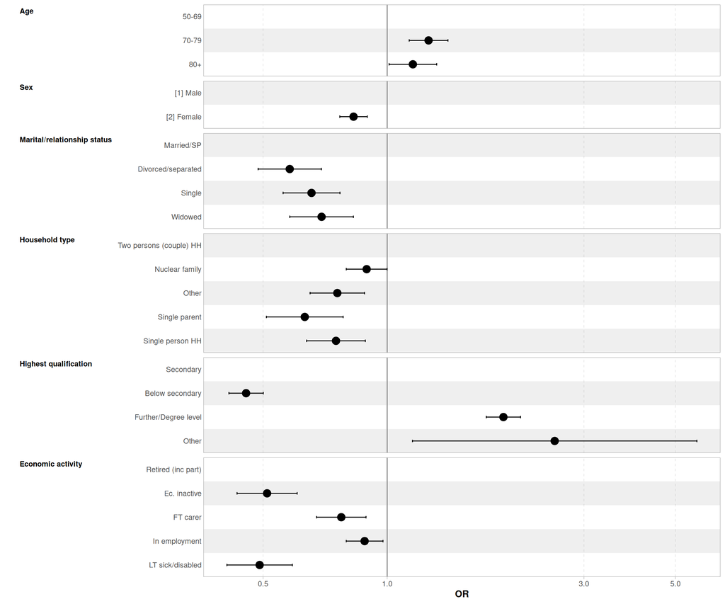

**6.2 SEV + IVS**

#### Stepwise models

| **Characteristic** | **M1** **OR**<sup>1</sup> | **M1** **95% CI** | **M2** **OR**<sup>1</sup> | **M2** **95% CI** | **M3** **OR**<sup>1</sup> | **M3** **95% CI** | **M4** **OR**<sup>1</sup> | **M4** **95% CI** | **M5** **OR**<sup>1</sup> | **M5** **95% CI** | **M6** **OR**<sup>1</sup> | **M6** **95% CI** | **M7** **OR**<sup>1</sup> | **M7** **95% CI** | **M8** **OR**<sup>1</sup> | **M8** **95% CI** | **M9** **OR**<sup>1</sup> | **M9** **95% CI** | **M10** **OR**<sup>1</sup> | **M10** **95% CI** | **M11** **OR**<sup>1</sup> | **M11** **95% CI** | **M12** **OR**<sup>1</sup> | **M12** **95% CI** | **M12** **OR**<sup>1</sup> | **M12** **95% CI** |
| --- | --- | --- | --- | --- | --- | --- | --- | --- | --- | --- | --- | --- | --- | --- | --- | --- | --- | --- | --- | --- | --- | --- | --- | --- | --- | --- |
| Nr of health problems |  |  |  |  |  |  |  |  |  |  |  |  |  |  |  |  |  |  |  |  |  |  |  |  |  |  |
| None | — | — | — | — | — | — | — | — | — | — | — | — | — | — | — | — | — | — | — | — | — | — | — | — | — | — |
| 3-4 | 0.97 | 0.83, 1.13 | 1.13 | 0.96, 1.34 | 1.17 | 0.99, 1.38 | 1.18 | 1.00, 1.39 | 1.16 | 0.98, 1.37 | 1.16 | 0.98, 1.37 | 1.17 | 0.99, 1.38 | 1.09 | 0.92, 1.29 | 1.08 | 0.91, 1.27 | 1.07 | 0.90, 1.27 | 1.05 | 0.89, 1.24 | 0.96 | 0.81, 1.14 | 0.95 | 0.79, 1.13 |
| 5+ | 0.55*** | 0.44, 0.70 | 0.70** | 0.55, 0.89 | 0.74* | 0.58, 0.94 | 0.76* | 0.60, 0.98 | 0.77* | 0.60, 0.99 | 0.77* | 0.60, 0.98 | 0.79 | 0.61, 1.01 | 0.76* | 0.59, 0.97 | 0.74* | 0.57, 0.95 | 0.74* | 0.57, 0.95 | 0.72* | 0.56, 0.93 | 0.59*** | 0.45, 0.76 | 0.57*** | 0.44, 0.74 |
| One | 1.08 | 0.98, 1.18 | 1.15** | 1.04, 1.26 | 1.15** | 1.04, 1.27 | 1.16** | 1.06, 1.28 | 1.17** | 1.06, 1.29 | 1.17** | 1.06, 1.29 | 1.18*** | 1.07, 1.30 | 1.15** | 1.04, 1.27 | 1.14** | 1.03, 1.26 | 1.14** | 1.03, 1.26 | 1.13* | 1.02, 1.24 | 1.08 | 0.98, 1.20 | 1.07 | 0.96, 1.18 |
| Two | 0.86* | 0.75, 0.97 | 0.97 | 0.85, 1.11 | 0.99 | 0.87, 1.13 | 0.99 | 0.87, 1.13 | 0.98 | 0.86, 1.12 | 0.98 | 0.86, 1.12 | 1.00 | 0.88, 1.14 | 0.96 | 0.84, 1.09 | 0.95 | 0.83, 1.09 | 0.96 | 0.84, 1.10 | 0.95 | 0.83, 1.08 | 0.88 | 0.76, 1.01 | 0.87 | 0.76, 1.00 |
| Self-rated health |  |  |  |  |  |  |  |  |  |  |  |  |  |  |  |  |  |  |  |  |  |  |  |  |  |  |
| Very good/good |  |  | — | — | — | — | — | — | — | — | — | — | — | — | — | — | — | — | — | — | — | — | — | — | — | — |
| Fair |  |  | 0.83*** | 0.76, 0.91 | 0.86** | 0.78, 0.94 | 0.89* | 0.81, 0.97 | 0.95 | 0.86, 1.04 | 0.96 | 0.87, 1.05 | 0.96 | 0.88, 1.06 | 0.97 | 0.88, 1.06 | 0.97 | 0.88, 1.07 | 0.97 | 0.88, 1.07 | 0.98 | 0.89, 1.08 | 1.03 | 0.94, 1.14 | 1.05 | 0.95, 1.15 |
| Poor |  |  | 0.65*** | 0.56, 0.74 | 0.69*** | 0.61, 0.79 | 0.72*** | 0.63, 0.83 | 0.84* | 0.73, 0.96 | 0.86* | 0.75, 0.99 | 0.88 | 0.76, 1.01 | 0.89 | 0.78, 1.03 | 0.90 | 0.78, 1.03 | 0.90 | 0.78, 1.04 | 0.89 | 0.77, 1.03 | 1.00 | 0.87, 1.16 | 1.02 | 0.88, 1.18 |
| Subj. financial situation |  |  |  |  |  |  |  |  |  |  |  |  |  |  |  |  |  |  |  |  |  |  |  |  |  |  |
| Coping on present income |  |  |  |  | — | — | — | — | — | — | — | — | — | — | — | — | — | — | — | — | — | — | — | — | — | — |
| Living comfortably on present income |  |  |  |  | 1.24*** | 1.13, 1.36 | 1.20*** | 1.09, 1.32 | 1.13** | 1.03, 1.25 | 1.10* | 1.00, 1.21 | 1.14** | 1.03, 1.25 | 1.12* | 1.01, 1.23 | 1.11* | 1.01, 1.23 | 1.11* | 1.01, 1.22 | 1.09 | 0.99, 1.20 | 1.01 | 0.91, 1.11 | 0.99 | 0.90, 1.09 |
| Difficult on present income |  |  |  |  | 0.82*** | 0.73, 0.92 | 0.86* | 0.77, 0.97 | 0.93 | 0.82, 1.04 | 0.93 | 0.83, 1.04 | 0.91 | 0.81, 1.02 | 0.92 | 0.82, 1.04 | 0.93 | 0.82, 1.04 | 0.93 | 0.83, 1.05 | 0.95 | 0.84, 1.07 | 1.00 | 0.88, 1.12 | 1.0 | 0.88, 1.12 |
| Very difficult on present income |  |  |  |  | 0.56*** | 0.46, 0.69 | 0.61*** | 0.50, 0.75 | 0.70*** | 0.57, 0.86 | 0.71*** | 0.58, 0.86 | 0.68*** | 0.56, 0.84 | 0.72** | 0.58, 0.88 | 0.72** | 0.59, 0.88 | 0.72** | 0.58, 0.88 | 0.73** | 0.59, 0.89 | 0.73** | 0.59, 0.91 | 0.73** | 0.59, 0.91 |
| Feels lonely? |  |  |  |  |  |  |  |  |  |  |  |  |  |  |  |  |  |  |  |  |  |  |  |  |  |  |
| None/almost none of the time |  |  |  |  |  |  | — | — | — | — | — | — | — | — | — | — | — | — | — | — | — | — | — | — | — | — |
| Most/all of the time |  |  |  |  |  |  | 0.70*** | 0.61, 0.81 | 0.84* | 0.72, 0.97 | 0.88 | 0.76, 1.03 | 0.87 | 0.75, 1.01 | 0.86 | 0.74, 1.00 | 0.86 | 0.74, 1.00 | 0.86 | 0.74, 1.00 | 0.85* | 0.73, 0.99 | 0.87 | 0.74, 1.01 | 0.85* | 0.73, 1.00 |
| Some of the time |  |  |  |  |  |  | 0.63*** | 0.58, 0.70 | 0.70*** | 0.63, 0.77 | 0.71*** | 0.64, 0.78 | 0.70*** | 0.63, 0.77 | 0.70*** | 0.64, 0.77 | 0.70*** | 0.64, 0.78 | 0.71*** | 0.64, 0.78 | 0.71*** | 0.64, 0.78 | 0.71*** | 0.65, 0.79 | 0.71*** | 0.64, 0.79 |
| Feels happy? |  |  |  |  |  |  |  |  |  |  |  |  |  |  |  |  |  |  |  |  |  |  |  |  |  |  |
| 1st quartile - least happy |  |  |  |  |  |  |  |  | — | — | — | — | — | — | — | — | — | — | — | — | — | — | — | — | — | — |
| 2nd qtile |  |  |  |  |  |  |  |  | 1.56*** | 1.39, 1.75 | 1.53*** | 1.36, 1.71 | 1.50*** | 1.33, 1.68 | 1.51*** | 1.34, 1.70 | 1.51*** | 1.34, 1.70 | 1.52*** | 1.35, 1.71 | 1.51*** | 1.34, 1.70 | 1.48*** | 1.31, 1.67 | 1.46*** | 1.29, 1.65 |
| 3rd qtile |  |  |  |  |  |  |  |  | 2.00*** | 1.77, 2.27 | 1.94*** | 1.71, 2.20 | 1.92*** | 1.69, 2.18 | 1.92*** | 1.69, 2.18 | 1.90*** | 1.68, 2.16 | 1.92*** | 1.69, 2.18 | 1.88*** | 1.65, 2.13 | 1.76*** | 1.55, 2.01 | 1.71*** | 1.50, 1.95 |
| 4th qtile |  |  |  |  |  |  |  |  | 1.96*** | 1.73, 2.23 | 1.91*** | 1.67, 2.17 | 1.89*** | 1.66, 2.16 | 1.89*** | 1.66, 2.16 | 1.88*** | 1.65, 2.15 | 1.90*** | 1.66, 2.16 | 1.85*** | 1.63, 2.12 | 1.72*** | 1.51, 1.97 | 1.70*** | 1.48, 1.94 |
| Meet friends/relatives? |  |  |  |  |  |  |  |  |  |  |  |  |  |  |  |  |  |  |  |  |  |  |  |  |  |  |
| Daily or less |  |  |  |  |  |  |  |  |  |  | — | — | — | — | — | — | — | — | — | — | — | — | — | — | — | — |
| Monthly or less |  |  |  |  |  |  |  |  |  |  | 0.74*** | 0.67, 0.82 | 0.73*** | 0.66, 0.81 | 0.75*** | 0.67, 0.83 | 0.75*** | 0.67, 0.83 | 0.75*** | 0.67, 0.83 | 0.79*** | 0.71, 0.88 | 0.76*** | 0.68, 0.85 | 0.78*** | 0.70, 0.87 |
| Weekly or less |  |  |  |  |  |  |  |  |  |  | 1.02 | 0.93, 1.12 | 1.00 | 0.91, 1.10 | 1.03 | 0.93, 1.13 | 1.03 | 0.94, 1.13 | 1.03 | 0.94, 1.13 | 1.05 | 0.96, 1.16 | 1.03 | 0.94, 1.14 | 1.03 | 0.94, 1.14 |
| Religious attendence |  |  |  |  |  |  |  |  |  |  |  |  |  |  |  |  |  |  |  |  |  |  |  |  |  |  |
| Rarely or never |  |  |  |  |  |  |  |  |  |  |  |  | — | — | — | — | — | — | — | — | — | — | — | — | — | — |
| Less than weekly |  |  |  |  |  |  |  |  |  |  |  |  | 1.35*** | 1.22, 1.48 | 1.39*** | 1.27, 1.54 | 1.40*** | 1.27, 1.54 | 1.39*** | 1.26, 1.53 | 1.37*** | 1.24, 1.51 | 1.45*** | 1.32, 1.60 | 1.48*** | 1.34, 1.64 |
| Once a week or more |  |  |  |  |  |  |  |  |  |  |  |  | 1.36*** | 1.21, 1.52 | 1.43*** | 1.27, 1.61 | 1.45*** | 1.29, 1.63 | 1.43*** | 1.27, 1.61 | 1.41*** | 1.25, 1.58 | 1.48*** | 1.31, 1.67 | 1.52*** | 1.35, 1.72 |
| Trade-union etc member? |  |  |  |  |  |  |  |  |  |  |  |  |  |  |  |  |  |  |  |  |  |  |  |  |  |  |
| No |  |  |  |  |  |  |  |  |  |  |  |  |  |  | — | — | — | — | — | — | — | — | — | — | — | — |
| Yes, currently |  |  |  |  |  |  |  |  |  |  |  |  |  |  | 2.60*** | 2.20, 3.08 | 2.60*** | 2.20, 3.08 | 2.52*** | 2.13, 2.99 | 2.46*** | 2.07, 2.91 | 2.28*** | 1.91, 2.70 | 2.23*** | 1.88, 2.65 |
| Yes, previously |  |  |  |  |  |  |  |  |  |  |  |  |  |  | 1.61*** | 1.46, 1.78 | 1.61*** | 1.46, 1.78 | 1.58*** | 1.43, 1.75 | 1.55*** | 1.40, 1.72 | 1.46*** | 1.32, 1.62 | 1.46*** | 1.32, 1.62 |
| Whether does caring/housework? |  |  |  |  |  |  |  |  |  |  |  |  |  |  |  |  |  |  |  |  |  |  |  |  |  |  |
| Did not report |  |  |  |  |  |  |  |  |  |  |  |  |  |  |  |  | — | — | — | — | — | — | — | — | — | — |
| Did housework/cared for someone |  |  |  |  |  |  |  |  |  |  |  |  |  |  |  |  | 1.51*** | 1.23, 1.87 | 1.54*** | 1.25, 1.90 | 1.51*** | 1.22, 1.86 | 1.32* | 1.06, 1.64 | 1.30* | 1.05, 1.62 |
| Organisation works/worked for |  |  |  |  |  |  |  |  |  |  |  |  |  |  |  |  |  |  |  |  |  |  |  |  |  |  |
| Private sector |  |  |  |  |  |  |  |  |  |  |  |  |  |  |  |  |  |  | — | — | — | — | — | — | — | — |
| Government (inc. local) |  |  |  |  |  |  |  |  |  |  |  |  |  |  |  |  |  |  | 1.43*** | 1.23, 1.68 | 1.43*** | 1.22, 1.68 | 1.34*** | 1.14, 1.58 | 1.35*** | 1.15, 1.59 |
| Other public |  |  |  |  |  |  |  |  |  |  |  |  |  |  |  |  |  |  | 1.18* | 1.02, 1.36 | 1.19* | 1.03, 1.37 | 1.13 | 0.97, 1.30 | 1.13 | 0.98, 1.31 |
| Other/DNA |  |  |  |  |  |  |  |  |  |  |  |  |  |  |  |  |  |  | 0.84 | 0.67, 1.06 | 0.83 | 0.66, 1.05 | 0.76* | 0.59, 0.96 | 0.77* | 0.60, 0.98 |
| Self-employed |  |  |  |  |  |  |  |  |  |  |  |  |  |  |  |  |  |  | 1.18* | 1.03, 1.35 | 1.19* | 1.04, 1.36 | 1.12 | 0.97, 1.28 | 1.12 | 0.98, 1.29 |
| State-owned |  |  |  |  |  |  |  |  |  |  |  |  |  |  |  |  |  |  | 1.17 | 0.99, 1.37 | 1.20* | 1.02, 1.40 | 1.22* | 1.03, 1.43 | 1.23* | 1.04, 1.45 |
| Whether volunteers |  |  |  |  |  |  |  |  |  |  |  |  |  |  |  |  |  |  |  |  |  |  |  |  |  |  |
| Yes |  |  |  |  |  |  |  |  |  |  |  |  |  |  |  |  |  |  |  |  | — | — | — | — | — | — |
| No |  |  |  |  |  |  |  |  |  |  |  |  |  |  |  |  |  |  |  |  | 0.60*** | 0.53, 0.67 | 0.68*** | 0.60, 0.77 | 0.70*** | 0.62, 0.79 |
| Interest in politics |  |  |  |  |  |  |  |  |  |  |  |  |  |  |  |  |  |  |  |  |  |  |  |  |  |  |
| Interested in politics |  |  |  |  |  |  |  |  |  |  |  |  |  |  |  |  |  |  |  |  |  |  | — | — | — | — |
| Not interested in politics |  |  |  |  |  |  |  |  |  |  |  |  |  |  |  |  |  |  |  |  |  |  | 0.29*** | 0.26, 0.31 | 0.30*** | 0.27, 0.33 |
| Internet usage |  |  |  |  |  |  |  |  |  |  |  |  |  |  |  |  |  |  |  |  |  |  |  |  |  |  |
| Most days/ every day |  |  |  |  |  |  |  |  |  |  |  |  |  |  |  |  |  |  |  |  |  |  |  |  | — | — |
| Never |  |  |  |  |  |  |  |  |  |  |  |  |  |  |  |  |  |  |  |  |  |  |  |  | 0.71*** | 0.63, 0.81 |
| Occasionally/ a few times a week |  |  |  |  |  |  |  |  |  |  |  |  |  |  |  |  |  |  |  |  |  |  |  |  | 0.64*** | 0.57, 0.72 |
| AIC | 14,889 |  | 14,860 |  | 14,797 |  | 14,711 |  | 14,591 |  | 14,555 |  | 14,519 |  | 14,318 |  | 14,299 |  | 14,275 |  | 14,199 |  | 13,486 |  | 13,428 |  |
| Log-likelihood | -7,422 |  | -7,406 |  | -7,372 |  | -7,326 |  | -7,264 |  | -7,244 |  | -7,223 |  | -7,121 |  | -7,110 |  | -7,094 |  | -7,055 |  | -6,697 |  | -6,666 |  |
| No. Obs. | 21,002 |  | 21,002 |  | 21,002 |  | 21,002 |  | 21,002 |  | 21,002 |  | 21,002 |  | 21,002 |  | 21,002 |  | 21,002 |  | 21,002 |  | 21,002 |  | 21,002 |  |

<sup>1</sup> *p<0.05; **p<0.01;*** p<0.001  
Abbreviations: CI = Confidence Interval, OR = Odds Ratio

#### Coefficient plots of model 12

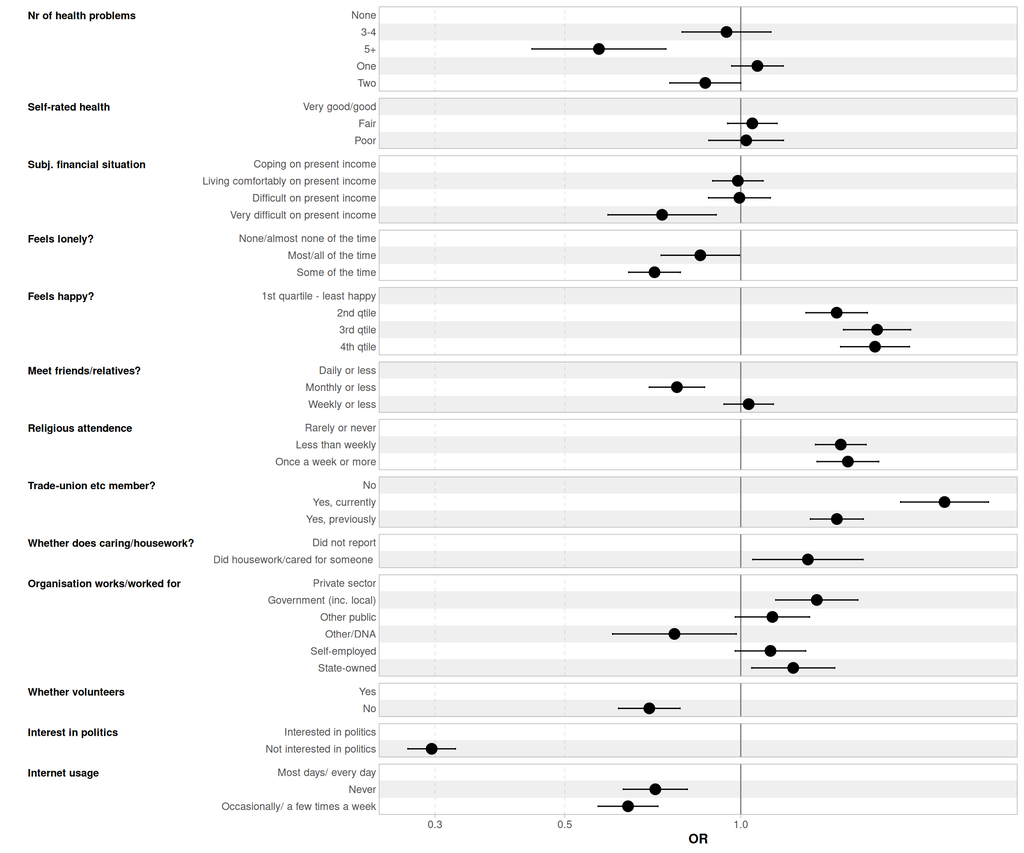

**6.3 SEV + IVS + interactions**

#### Stepwise models

| **Characteristic** | **M1** **OR**<sup>1</sup> | **M1** **95% CI** | **M2** **OR**<sup>1</sup> | **M2** **95% CI** | **M3** **OR**<sup>1</sup> | **M3** **95% CI** | **M4** **OR**<sup>1</sup> | **M4** **95% CI** | **M5** **OR**<sup>1</sup> | **M5** **95% CI** | **M6** **OR**<sup>1</sup> | **M6** **95% CI** | **M7** **OR**<sup>1</sup> | **M7** **95% CI** | **M8** **OR**<sup>1</sup> | **M8** **95% CI** | **M9** **OR**<sup>1</sup> | **M9** **95% CI** | **M10** **OR**<sup>1</sup> | **M10** **95% CI** | **M11** **OR**<sup>1</sup> | **M11** **95% CI** | **M12** **OR**<sup>1</sup> | **M12** **95% CI** | **M13** **OR**<sup>1</sup> | **M13** **95% CI** |
| --- | --- | --- | --- | --- | --- | --- | --- | --- | --- | --- | --- | --- | --- | --- | --- | --- | --- | --- | --- | --- | --- | --- | --- | --- | --- | --- |
| Age |  |  |  |  |  |  |  |  |  |  |  |  |  |  |  |  |  |  |  |  |  |  |  |  |  |  |
| 50-69 | — | — | — | — | — | — | — | — | — | — | — | — | — | — | — | — | — | — | — | — | — | — | — | — | — | — |
| 70-79 | 1.25** | 1.07, 1.46 | 1.27** | 1.09, 1.49 | 1.25** | 1.07, 1.46 | 1.27** | 1.08, 1.48 | 1.29** | 1.10, 1.51 | 1.30** | 1.11, 1.52 | 1.29** | 1.10, 1.52 | 1.31*** | 1.12, 1.53 | 1.31*** | 1.12, 1.53 | 1.29** | 1.10, 1.52 | 1.30** | 1.11, 1.53 | 1.21* | 1.03, 1.43 | 1.27** | 1.08, 1.50 |
| 80+ | 1.43*** | 1.16, 1.75 | 1.48*** | 1.21, 1.82 | 1.42*** | 1.15, 1.74 | 1.45*** | 1.18, 1.79 | 1.47*** | 1.19, 1.81 | 1.51*** | 1.23, 1.87 | 1.49*** | 1.21, 1.84 | 1.54*** | 1.25, 1.91 | 1.53*** | 1.24, 1.89 | 1.52*** | 1.23, 1.88 | 1.53*** | 1.23, 1.89 | 1.47*** | 1.19, 1.83 | 1.61*** | 1.29, 2.01 |
| Age by sex |  |  |  |  |  |  |  |  |  |  |  |  |  |  |  |  |  |  |  |  |  |  |  |  |  |  |
| 70-79 * [2] Female | 1.21 | 1.00, 1.48 | 1.20 | 0.98, 1.45 | 1.19 | 0.97, 1.44 | 1.17 | 0.96, 1.42 | 1.16 | 0.96, 1.42 | 1.14 | 0.94, 1.39 | 1.13 | 0.93, 1.38 | 1.15 | 0.94, 1.40 | 1.16 | 0.95, 1.41 | 1.17 | 0.96, 1.43 | 1.16 | 0.95, 1.42 | 1.18 | 0.96, 1.45 | 1.19 | 0.97, 1.46 |
| 80+ * [2] Female | 0.91 | 0.71, 1.17 | 0.89 | 0.70, 1.15 | 0.88 | 0.69, 1.14 | 0.85 | 0.66, 1.10 | 0.84 | 0.65, 1.09 | 0.83 | 0.64, 1.07 | 0.83 | 0.64, 1.07 | 0.82 | 0.63, 1.06 | 0.83 | 0.64, 1.07 | 0.84 | 0.65, 1.08 | 0.85 | 0.66, 1.10 | 0.77 | 0.59, 1.01 | 0.79 | 0.61, 1.03 |
| Nr of health problems |  |  |  |  |  |  |  |  |  |  |  |  |  |  |  |  |  |  |  |  |  |  |  |  |  |  |
| None | — | — | — | — | — | — | — | — | — | — | — | — | — | — | — | — | — | — | — | — | — | — | — | — | — | — |
| 3-4 | 0.97 | 0.83, 1.13 | 1.14 | 0.96, 1.34 | 1.17 | 0.99, 1.38 | 1.18 | 1.00, 1.39 | 1.16 | 0.98, 1.37 | 1.17 | 0.99, 1.38 | 1.17 | 0.99, 1.38 | 1.09 | 0.92, 1.29 | 1.08 | 0.91, 1.28 | 1.07 | 0.90, 1.27 | 1.05 | 0.89, 1.25 | 0.97 | 0.81, 1.15 | 0.95 | 0.80, 1.13 |
| 5+ | 0.55*** | 0.44, 0.70 | 0.70** | 0.55, 0.89 | 0.74* | 0.57, 0.94 | 0.76* | 0.59, 0.98 | 0.77* | 0.60, 0.99 | 0.77* | 0.60, 0.98 | 0.79 | 0.61, 1.01 | 0.75* | 0.59, 0.97 | 0.74* | 0.57, 0.95 | 0.74* | 0.57, 0.95 | 0.72* | 0.56, 0.93 | 0.59*** | 0.45, 0.76 | 0.57*** | 0.44, 0.74 |
| One | 1.08 | 0.98, 1.18 | 1.15** | 1.04, 1.26 | 1.15** | 1.04, 1.27 | 1.16** | 1.06, 1.28 | 1.17** | 1.06, 1.29 | 1.17** | 1.06, 1.29 | 1.18*** | 1.07, 1.30 | 1.15** | 1.04, 1.27 | 1.14** | 1.03, 1.26 | 1.14** | 1.03, 1.26 | 1.13* | 1.02, 1.24 | 1.08 | 0.98, 1.19 | 1.07 | 0.96, 1.18 |
| Two | 0.85* | 0.75, 0.97 | 0.97 | 0.85, 1.10 | 0.99 | 0.87, 1.13 | 0.99 | 0.87, 1.13 | 0.98 | 0.86, 1.12 | 0.98 | 0.86, 1.12 | 1.00 | 0.88, 1.14 | 0.96 | 0.84, 1.09 | 0.95 | 0.83, 1.09 | 0.96 | 0.84, 1.09 | 0.94 | 0.82, 1.08 | 0.88 | 0.76, 1.01 | 0.87* | 0.76, 1.00 |
| Self-rated health |  |  |  |  |  |  |  |  |  |  |  |  |  |  |  |  |  |  |  |  |  |  |  |  |  |  |
| Very good/good |  |  | — | — | — | — | — | — | — | — | — | — | — | — | — | — | — | — | — | — | — | — | — | — | — | — |
| Fair |  |  | 0.83*** | 0.76, 0.91 | 0.86** | 0.78, 0.94 | 0.89* | 0.81, 0.97 | 0.95 | 0.86, 1.04 | 0.96 | 0.87, 1.05 | 0.96 | 0.88, 1.06 | 0.97 | 0.88, 1.06 | 0.97 | 0.88, 1.07 | 0.97 | 0.89, 1.07 | 0.98 | 0.89, 1.08 | 1.03 | 0.94, 1.14 | 1.05 | 0.95, 1.16 |
| Poor |  |  | 0.65*** | 0.57, 0.74 | 0.69*** | 0.61, 0.79 | 0.72*** | 0.63, 0.83 | 0.84* | 0.73, 0.96 | 0.86* | 0.75, 0.99 | 0.88 | 0.76, 1.01 | 0.89 | 0.78, 1.03 | 0.90 | 0.78, 1.03 | 0.90 | 0.78, 1.04 | 0.89 | 0.77, 1.03 | 1.00 | 0.87, 1.16 | 1.02 | 0.88, 1.18 |
| Subj. financial situation |  |  |  |  |  |  |  |  |  |  |  |  |  |  |  |  |  |  |  |  |  |  |  |  |  |  |
| Coping on present income |  |  |  |  | — | — | — | — | — | — | — | — | — | — | — | — | — | — | — | — | — | — | — | — | — | — |
| Living comfortably on present income |  |  |  |  | 1.24*** | 1.13, 1.36 | 1.20*** | 1.09, 1.31 | 1.13* | 1.03, 1.24 | 1.10 | 1.00, 1.21 | 1.13* | 1.03, 1.25 | 1.11* | 1.01, 1.23 | 1.11* | 1.01, 1.22 | 1.11* | 1.01, 1.22 | 1.09 | 0.99, 1.20 | 1.01 | 0.91, 1.11 | 0.99 | 0.89, 1.09 |
| Difficult on present income |  |  |  |  | 0.82*** | 0.73, 0.92 | 0.86** | 0.77, 0.96 | 0.92 | 0.82, 1.04 | 0.93 | 0.83, 1.04 | 0.91 | 0.81, 1.02 | 0.92 | 0.82, 1.04 | 0.93 | 0.82, 1.04 | 0.93 | 0.83, 1.05 | 0.94 | 0.84, 1.06 | 1.00 | 0.88, 1.12 | 0.99 | 0.88, 1.12 |
| Very difficult on present income |  |  |  |  | 0.56*** | 0.46, 0.69 | 0.61*** | 0.50, 0.75 | 0.70*** | 0.57, 0.86 | 0.70*** | 0.57, 0.86 | 0.68*** | 0.56, 0.84 | 0.72** | 0.58, 0.88 | 0.72** | 0.58, 0.88 | 0.71** | 0.58, 0.88 | 0.72** | 0.59, 0.89 | 0.73** | 0.59, 0.90 | 0.73** | 0.59, 0.91 |
| Feels lonely? |  |  |  |  |  |  |  |  |  |  |  |  |  |  |  |  |  |  |  |  |  |  |  |  |  |  |
| None/almost none of the time |  |  |  |  |  |  | — | — | — | — | — | — | — | — | — | — | — | — | — | — | — | — | — | — | — | — |
| Most/all of the time |  |  |  |  |  |  | 0.70*** | 0.61, 0.81 | 0.84* | 0.72, 0.97 | 0.88 | 0.76, 1.03 | 0.87 | 0.75, 1.01 | 0.86 | 0.74, 1.00 | 0.86 | 0.74, 1.00 | 0.86 | 0.74, 1.00 | 0.85* | 0.73, 0.99 | 0.87 | 0.74, 1.01 | 0.85* | 0.73, 1.0 |
| Some of the time |  |  |  |  |  |  | 0.63*** | 0.58, 0.70 | 0.70*** | 0.63, 0.77 | 0.71*** | 0.64, 0.78 | 0.70*** | 0.63, 0.77 | 0.70*** | 0.64, 0.77 | 0.70*** | 0.64, 0.78 | 0.71*** | 0.64, 0.78 | 0.71*** | 0.64, 0.78 | 0.71*** | 0.65, 0.79 | 0.71*** | 0.64, 0.79 |
| Feels happy? |  |  |  |  |  |  |  |  |  |  |  |  |  |  |  |  |  |  |  |  |  |  |  |  |  |  |
| 1st quartile - least happy |  |  |  |  |  |  |  |  | — | — | — | — | — | — | — | — | — | — | — | — | — | — | — | — | — | — |
| 2nd qtile |  |  |  |  |  |  |  |  | 1.56*** | 1.39, 1.75 | 1.53*** | 1.36, 1.71 | 1.50*** | 1.33, 1.68 | 1.51*** | 1.35, 1.70 | 1.51*** | 1.35, 1.70 | 1.52*** | 1.35, 1.71 | 1.51*** | 1.34, 1.70 | 1.48*** | 1.31, 1.67 | 1.46*** | 1.29, 1.65 |
| 3rd qtile |  |  |  |  |  |  |  |  | 2.01*** | 1.77, 2.28 | 1.94*** | 1.71, 2.20 | 1.92*** | 1.69, 2.18 | 1.92*** | 1.69, 2.18 | 1.91*** | 1.68, 2.17 | 1.92*** | 1.69, 2.18 | 1.88*** | 1.65, 2.14 | 1.77*** | 1.55, 2.02 | 1.72*** | 1.50, 1.96 |
| 4th qtile |  |  |  |  |  |  |  |  | 1.96*** | 1.73, 2.24 | 1.91*** | 1.68, 2.17 | 1.89*** | 1.66, 2.16 | 1.90*** | 1.66, 2.16 | 1.88*** | 1.65, 2.15 | 1.90*** | 1.67, 2.17 | 1.86*** | 1.63, 2.12 | 1.72*** | 1.51, 1.97 | 1.70*** | 1.48, 1.94 |
| Meet friends/relatives? |  |  |  |  |  |  |  |  |  |  |  |  |  |  |  |  |  |  |  |  |  |  |  |  |  |  |
| Daily or less |  |  |  |  |  |  |  |  |  |  | — | — | — | — | — | — | — | — | — | — | — | — | — | — | — | — |
| Monthly or less |  |  |  |  |  |  |  |  |  |  | 0.74*** | 0.67, 0.83 | 0.73*** | 0.66, 0.81 | 0.75*** | 0.67, 0.83 | 0.75*** | 0.68, 0.83 | 0.75*** | 0.68, 0.83 | 0.79*** | 0.71, 0.88 | 0.76*** | 0.68, 0.85 | 0.78*** | 0.70, 0.87 |
| Weekly or less |  |  |  |  |  |  |  |  |  |  | 1.02 | 0.93, 1.12 | 1.01 | 0.92, 1.11 | 1.03 | 0.94, 1.13 | 1.03 | 0.94, 1.13 | 1.03 | 0.94, 1.13 | 1.06 | 0.96, 1.16 | 1.04 | 0.94, 1.14 | 1.04 | 0.94, 1.14 |
| Religious attendence |  |  |  |  |  |  |  |  |  |  |  |  |  |  |  |  |  |  |  |  |  |  |  |  |  |  |
| Rarely or never |  |  |  |  |  |  |  |  |  |  |  |  | — | — | — | — | — | — | — | — | — | — | — | — | — | — |
| Less than weekly |  |  |  |  |  |  |  |  |  |  |  |  | 1.34*** | 1.22, 1.48 | 1.39*** | 1.27, 1.53 | 1.40*** | 1.27, 1.54 | 1.39*** | 1.26, 1.53 | 1.37*** | 1.24, 1.50 | 1.45*** | 1.31, 1.60 | 1.48*** | 1.34, 1.64 |
| Once a week or more |  |  |  |  |  |  |  |  |  |  |  |  | 1.35*** | 1.20, 1.52 | 1.43*** | 1.27, 1.61 | 1.45*** | 1.29, 1.63 | 1.43*** | 1.27, 1.61 | 1.40*** | 1.25, 1.58 | 1.47*** | 1.31, 1.66 | 1.52*** | 1.35, 1.72 |
| Trade-union etc member? |  |  |  |  |  |  |  |  |  |  |  |  |  |  |  |  |  |  |  |  |  |  |  |  |  |  |
| No |  |  |  |  |  |  |  |  |  |  |  |  |  |  | — | — | — | — | — | — | — | — | — | — | — | — |
| Yes, currently |  |  |  |  |  |  |  |  |  |  |  |  |  |  | 2.60*** | 2.20, 3.08 | 2.60*** | 2.20, 3.08 | 2.52*** | 2.13, 2.99 | 2.46*** | 2.07, 2.91 | 2.27*** | 1.91, 2.70 | 2.23*** | 1.87, 2.65 |
| Yes, previously |  |  |  |  |  |  |  |  |  |  |  |  |  |  | 1.62*** | 1.46, 1.79 | 1.62*** | 1.46, 1.79 | 1.58*** | 1.43, 1.75 | 1.56*** | 1.41, 1.73 | 1.47*** | 1.32, 1.63 | 1.47*** | 1.32, 1.63 |
| Whether does caring/housework? |  |  |  |  |  |  |  |  |  |  |  |  |  |  |  |  |  |  |  |  |  |  |  |  |  |  |
| Did not report |  |  |  |  |  |  |  |  |  |  |  |  |  |  |  |  | — | — | — | — | — | — | — | — | — | — |
| Did housework/cared for someone |  |  |  |  |  |  |  |  |  |  |  |  |  |  |  |  | 1.51*** | 1.23, 1.87 | 1.54*** | 1.25, 1.90 | 1.51*** | 1.22, 1.86 | 1.32* | 1.06, 1.64 | 1.30* | 1.05, 1.62 |
| Organisation works/worked for |  |  |  |  |  |  |  |  |  |  |  |  |  |  |  |  |  |  |  |  |  |  |  |  |  |  |
| Private sector |  |  |  |  |  |  |  |  |  |  |  |  |  |  |  |  |  |  | — | — | — | — | — | — | — | — |
| Government (inc. local) |  |  |  |  |  |  |  |  |  |  |  |  |  |  |  |  |  |  | 1.44*** | 1.23, 1.68 | 1.43*** | 1.22, 1.68 | 1.35*** | 1.15, 1.58 | 1.35*** | 1.15, 1.59 |
| Other public |  |  |  |  |  |  |  |  |  |  |  |  |  |  |  |  |  |  | 1.17* | 1.02, 1.35 | 1.18* | 1.03, 1.36 | 1.12 | 0.97, 1.30 | 1.13 | 0.97, 1.30 |
| Other/DNA |  |  |  |  |  |  |  |  |  |  |  |  |  |  |  |  |  |  | 0.85 | 0.67, 1.07 | 0.84 | 0.66, 1.06 | 0.76* | 0.60, 0.97 | 0.77* | 0.61, 0.99 |
| Self-employed |  |  |  |  |  |  |  |  |  |  |  |  |  |  |  |  |  |  | 1.18* | 1.03, 1.35 | 1.19* | 1.04, 1.36 | 1.12 | 0.97, 1.28 | 1.12 | 0.98, 1.29 |
| State-owned |  |  |  |  |  |  |  |  |  |  |  |  |  |  |  |  |  |  | 1.17 | 1.00, 1.37 | 1.20* | 1.02, 1.40 | 1.22* | 1.04, 1.44 | 1.23* | 1.05, 1.45 |
| Whether volunteers |  |  |  |  |  |  |  |  |  |  |  |  |  |  |  |  |  |  |  |  |  |  |  |  |  |  |
| Yes |  |  |  |  |  |  |  |  |  |  |  |  |  |  |  |  |  |  |  |  | — | — | — | — | — | — |
| No |  |  |  |  |  |  |  |  |  |  |  |  |  |  |  |  |  |  |  |  | 0.60*** | 0.53, 0.68 | 0.68*** | 0.61, 0.77 | 0.70*** | 0.62, 0.79 |
| Interest in politics |  |  |  |  |  |  |  |  |  |  |  |  |  |  |  |  |  |  |  |  |  |  |  |  |  |  |
| Interested in politics |  |  |  |  |  |  |  |  |  |  |  |  |  |  |  |  |  |  |  |  |  |  | — | — | — | — |
| Not interested in politics |  |  |  |  |  |  |  |  |  |  |  |  |  |  |  |  |  |  |  |  |  |  | 0.28*** | 0.26, 0.31 | 0.30*** | 0.27, 0.32 |
| Internet usage |  |  |  |  |  |  |  |  |  |  |  |  |  |  |  |  |  |  |  |  |  |  |  |  |  |  |
| Most days/ every day |  |  |  |  |  |  |  |  |  |  |  |  |  |  |  |  |  |  |  |  |  |  |  |  | — | — |
| Never |  |  |  |  |  |  |  |  |  |  |  |  |  |  |  |  |  |  |  |  |  |  |  |  | 0.72*** | 0.63, 0.81 |
| Occasionally/ a few times a week |  |  |  |  |  |  |  |  |  |  |  |  |  |  |  |  |  |  |  |  |  |  |  |  | 0.64*** | 0.57, 0.72 |
| AIC | 14,887 |  | 14,859 |  | 14,796 |  | 14,709 |  | 14,589 |  | 14,554 |  | 14,518 |  | 14,316 |  | 14,297 |  | 14,273 |  | 14,198 |  | 13,481 |  | 13,423 |  |
| Log-likelihood | -7,419 |  | -7,403 |  | -7,369 |  | -7,324 |  | -7,261 |  | -7,241 |  | -7,221 |  | -7,118 |  | -7,107 |  | -7,090 |  | -7,052 |  | -6,692 |  | -6,662 |  |
| No. Obs. | 21,002 |  | 21,002 |  | 21,002 |  | 21,002 |  | 21,002 |  | 21,002 |  | 21,002 |  | 21,002 |  | 21,002 |  | 21,002 |  | 21,002 |  | 21,002 |  | 21,002 |  |

<sup>1</sup> *p<0.05; **p<0.01;*** p<0.001  
Abbreviations: CI = Confidence Interval, OR = Odds Ratio

#### Coefficient plots of model 13

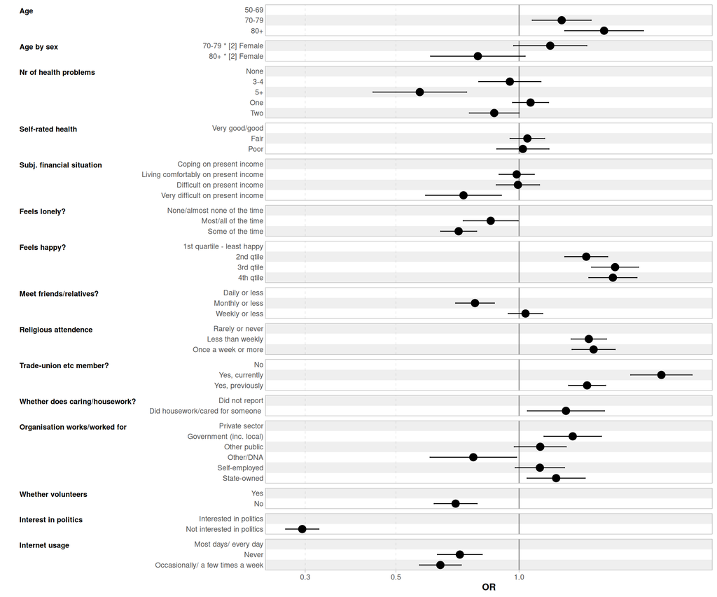

**6.4 SEV & interaction**

#### Stepwise models

| **Characteristic** | **M1** **OR**<sup>1</sup> | **M1** **95% CI** | **M2** **OR**<sup>1</sup> | **M2** **95% CI** | **M3** **OR**<sup>1</sup> | **M3** **95% CI** | **M4** **OR**<sup>1</sup> | **M4** **95% CI** | **M5** **OR**<sup>1</sup> | **M5** **95% CI** | **M6** **OR**<sup>1</sup> | **M6** **95% CI** | **M7** **OR**<sup>1</sup> | **M7** **95% CI** |
| --- | --- | --- | --- | --- | --- | --- | --- | --- | --- | --- | --- | --- | --- | --- |
| Age |  |  |  |  |  |  |  |  |  |  |  |  |  |  |
| 50-69 | — | — | — | — | — | — | — | — | — | — | — | — | — | — |
| 70-79 | 1.22*** | 1.12, 1.33 | 1.22*** | 1.12, 1.33 | 1.27*** | 1.16, 1.39 | 1.24*** | 1.13, 1.36 | 1.44*** | 1.31, 1.58 | 1.26*** | 1.13, 1.40 | 1.13 | 0.98, 1.31 |
| 80+ | 0.79*** | 0.71, 0.87 | 0.80*** | 0.72, 0.89 | 0.98 | 0.87, 1.10 | 0.95 | 0.84, 1.07 | 1.30*** | 1.15, 1.47 | 1.15* | 1.01, 1.32 | 1.28* | 1.06, 1.56 |
| Age by sex |  |  |  |  |  |  |  |  |  |  |  |  |  |  |
| 70-79 * [2] Female |  |  |  |  |  |  |  |  |  |  |  |  | 1.21* | 1.01, 1.45 |
| 80+ * [2] Female |  |  |  |  |  |  |  |  |  |  |  |  | 0.85 | 0.68, 1.07 |
| Sex |  |  |  |  |  |  |  |  |  |  |  |  |  |  |
| [1] Male |  |  | — | — | — | — | — | — | — | — | — | — | — | — |
| [2] Female |  |  | 0.73*** | 0.68, 0.78 | 0.80*** | 0.75, 0.86 | 0.81*** | 0.75, 0.87 | 0.81*** | 0.75, 0.87 | 0.83*** | 0.77, 0.89 | 0.81*** | 0.74, 0.89 |
| Marital/relationship status |  |  |  |  |  |  |  |  |  |  |  |  |  |  |
| Married/SP |  |  |  |  | — | — | — | — | — | — | — | — | — | — |
| Divorced/separated |  |  |  |  | 0.45*** | 0.41, 0.51 | 0.60*** | 0.51, 0.71 | 0.57*** | 0.48, 0.68 | 0.58*** | 0.49, 0.69 | 0.58*** | 0.49, 0.69 |
| Single |  |  |  |  | 0.52*** | 0.46, 0.58 | 0.64*** | 0.55, 0.75 | 0.64*** | 0.55, 0.75 | 0.66*** | 0.56, 0.77 | 0.66*** | 0.56, 0.77 |
| Widowed |  |  |  |  | 0.47*** | 0.43, 0.53 | 0.63*** | 0.53, 0.75 | 0.70*** | 0.59, 0.84 | 0.69*** | 0.58, 0.83 | 0.69*** | 0.58, 0.83 |
| Household type |  |  |  |  |  |  |  |  |  |  |  |  |  |  |
| Two persons (couple) HH |  |  |  |  |  |  | — | — | — | — | — | — | — | — |
| Nuclear family |  |  |  |  |  |  | 0.91 | 0.81, 1.01 | 0.87* | 0.77, 0.97 | 0.89* | 0.80, 1.00 | 0.89* | 0.79, 1.00 |
| Other |  |  |  |  |  |  | 0.70*** | 0.60, 0.81 | 0.72*** | 0.62, 0.84 | 0.76*** | 0.65, 0.88 | 0.76*** | 0.65, 0.88 |
| Single parent |  |  |  |  |  |  | 0.60*** | 0.49, 0.74 | 0.61*** | 0.49, 0.75 | 0.63*** | 0.51, 0.78 | 0.63*** | 0.51, 0.79 |
| Single person HH |  |  |  |  |  |  | 0.74*** | 0.63, 0.87 | 0.74*** | 0.63, 0.87 | 0.75*** | 0.64, 0.89 | 0.75*** | 0.64, 0.88 |
| Highest qualification |  |  |  |  |  |  |  |  |  |  |  |  |  |  |
| Secondary |  |  |  |  |  |  |  |  | — | — | — | — | — | — |
| Below secondary |  |  |  |  |  |  |  |  | 0.44*** | 0.40, 0.48 | 0.45*** | 0.41, 0.50 | 0.45*** | 0.41, 0.50 |
| Further/Degree level |  |  |  |  |  |  |  |  | 1.96*** | 1.79, 2.16 | 1.91*** | 1.74, 2.11 | 1.92*** | 1.74, 2.11 |
| Other |  |  |  |  |  |  |  |  | 2.55* | 1.16, 5.64 | 2.55* | 1.15, 5.64 | 2.55* | 1.15, 5.64 |
| Economic activity |  |  |  |  |  |  |  |  |  |  |  |  |  |  |
| Retired (inc part) |  |  |  |  |  |  |  |  |  |  | — | — | — | — |
| Ec. inactive |  |  |  |  |  |  |  |  |  |  | 0.51*** | 0.43, 0.60 | 0.51*** | 0.43, 0.61 |
| FT carer |  |  |  |  |  |  |  |  |  |  | 0.77*** | 0.67, 0.89 | 0.78*** | 0.67, 0.89 |
| In employment |  |  |  |  |  |  |  |  |  |  | 0.88* | 0.80, 0.98 | 0.88* | 0.80, 0.98 |
| LT sick/disabled |  |  |  |  |  |  |  |  |  |  | 0.49*** | 0.41, 0.59 | 0.49*** | 0.41, 0.59 |
| AIC | 18,222 |  | 18,142 |  | 17,764 |  | 17,739 |  | 17,103 |  | 17,018 |  | 17,013 |  |
| Log-likelihood | -9,108 |  | -9,067 |  | -8,875 |  | -8,859 |  | -8,538 |  | -8,491 |  | -8,487 |  |
| No. Obs. | 23,400 |  | 23,400 |  | 23,400 |  | 23,400 |  | 23,400 |  | 23,400 |  | 23,400 |  |

<sup>1</sup> *p<0.05; **p<0.01;*** p<0.001  
Abbreviations: CI = Confidence Interval, OR = Odds Ratio

#### Coefficient plot of Models 6

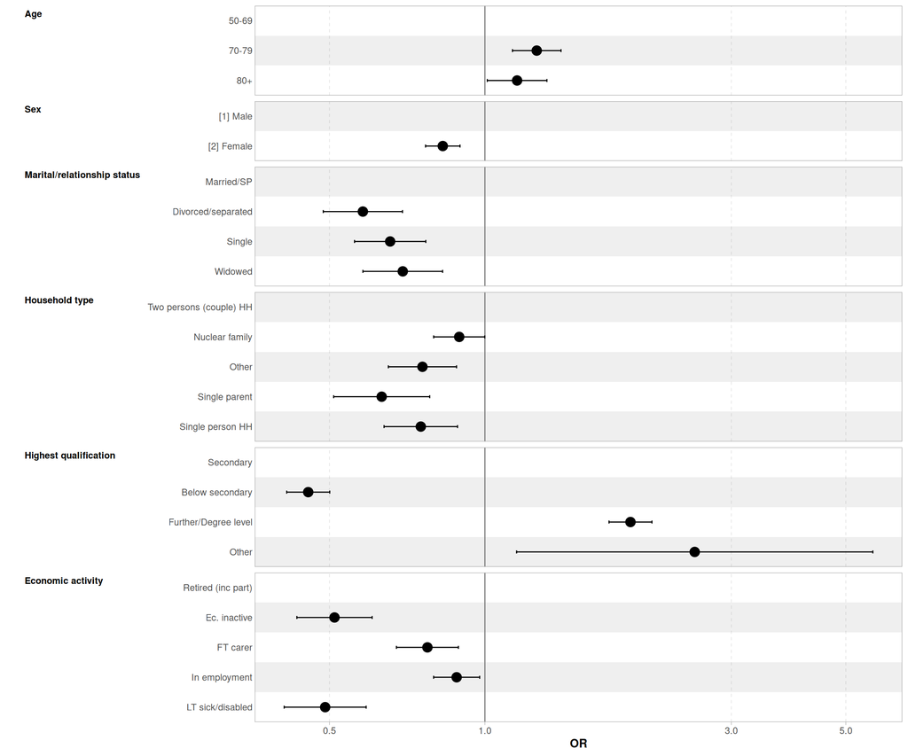

## Document version history

Version 2:

- Amended reference categories for marital status and education in regression tables to match those fromn ELSA
- Changed health problems mention to impairing health problems mentioned
- Added two regression tables with the interaction between Age 3 categories and sex included

Initial version

#### *To do*:

1. Check if control for simplified country blocks hass an impact;
2. Improve landing page.

## Footnotes

[^1]: Israel, the Russian Federation and Turkey were not included in this analysis.
[^2]: Respondents aged 50 and over]